# Sum

NAIS

ocessos de propriedade industrial

#### Juiz 2, relativa à marca nacional nº 708820, julga o to.

trabalhos de escritório; recrutamento de p

2

s de televisão por fibras ópticas, cabo e rodutos atrás citados.

fios comerciais; administração comercial; Patrocinadores; relaçóes públicas, incluindo mediação no estabelecimento de contactos

:ional e internacional; "merchandising"; ltadoria em matéria de gestão de negócios tentação de estratégias e conceitos de i, tanto para o mercado ”business-to-

os serviços atrás referidos também presta televisão, o teletexto e a Internet.

4º - A Recorrente deduziu reclamação em

Inexistem factos relevantes náo provê

MOTIVAÇÂO DA MATÉRIA FÁCTICA

A convicção do Tribunal quanto à face dos documentos juntos pela Requerente processo remetido pelo INPI. Assim:

Ponto i - provado pelo teor do process

Ponto z - provado pelo teor do process

3

dos por via eletrónica, incluindo a rádio, a

e programas radiofónicos e de televisão; ri e imagem, nomeadamente por rádio, letrónica; fornecimento de ligações para

!ridos também prestados por via eletrónica, a Internet.

Qualidade provada fundamentou-se no teor

- e, essencialmente nos que constam do

io do INPI.

o do INPI e documento i

Ponto 3 - proVado por documento junt Ponto 4 - provado por documento u e J

FUNDAMENTAÇÃO DE DIREITO

No que diz respeito ao conceito de definição dada no artig 3 °, ni, do Códi ‘A marca registada considera-se im1

parte, quando, cumulativamente:

1. A marca registada tiver prioridade;
2. Sejam ambas destinadas a assinalar prr

   4

   Pelo teor do processo do INPI .

   publicitaçáo de determinados serviços e distintiva pois permite que os produtos ou odos pela mesma. Permite assim, de forma do seu titular e o interesse público, listingam os produtos ou serviços de uma

   avo, Propriedade Industrial, vol I, pág 73) as da sua utilização em produtos idênticos idade Industrial, doravante CPI).

   ,açáo do seu titular, é recusado o registo de EPI, quando haja:

   e registada por outrem para produtos ou

   ' registada por outrem para produtos ou m parte, de marca anteriormente registada nticos ou afins, que possa induzir em erro renda o risco de associação com a marca

   imitação ou usurpaçáo, há que atender à

   ;o da Propriedade industrial:

   itada ou usurpada por outra, no todo ou em

Assim, uma marca é imitaçác preencha os três requisitos elencados nas r Entende a Recorrente que a marc

suscetível de gerar concorrência desleal.

este tipo de serviço.

Mas mesmo que se entendesse o coi marca registanda era necessário que as r que náo se afigura.

Com efeito, a única parte comum a nenhuma das marcas é constituída exclu evidencia na medida em que se encontra ii náo é suscetível de ser confundido ou FILBOX até porque o termo ‘BOX” é urr caixa e por isso tem um carácter distintivo as marcas são as demais expressões e estas

Como é salientado no acórdão do TO processo 137/>>-5

gurativa, fonética ou outra que induza infusão, ou que compreenda um risco de istada, de forma que o consumidor não as ento ou confronto.

anterior:

ridos na mesma classe da classificação de seridos na mesma classe da classificação de

› de outra quando de forma cumulativa, alíneas a), b) e c) do ni, dO artig 3 °

:a recorrida é confundível com a sua e é

ndiscutível que a marca da Recorrente é do pedido da marca recorrida.

odutos oferecidos por ambas as marcas, e um mesmo serviço, não se afigura existir n efeito a marca recorrida destina-se a para atividades e eventos educativos, de i marca da Recorrente se reporta apenas a serviços de som, etc, mas não contempla

itrário, para que seja recusado o registo da narcas se prestassem a ser confundidas, o

ambas é a expressão “BOX”, mas porque sivamente por esse vocábulo, este não se ategrado na palavra “CINEBOX”. Este sinal sequer associado à marca da Recorrente i termo inglês comum e geral que significa a fraco, donde o que predomina em ambas i diferem em ambas as marcas.

.L, de io/os/2023, proferido no ámbito do "HLSB.Li-PICRS, in

ao elemento dominante de cada marca, ao

seu núcleo essencial, desvalorizando ‹ considerar aquilo que o consumidor (méd à sua frente, ou seja, a reminiscência q reconhecer o sinal quando o voltar a encon Assim a parte inicial de qualquer um

Deste modo, o que fica memorizado i

“BOX”, não sendo este dissociado daquele será o conjunto “CINEBOX CINEMAS” q Recorrente “FILMBOX”. É certo que o voi mas quando inserido com outros termos é Ainda neste sentido o Acórdão do "

no âmbito do processo C-13 /O2P, Tor “Conforme o Tribunal de Justiça declaroi apreende normalmente uma marca como suas diferentes particularidades. De igual i desprovida de caracter distintivo, há q conjunto que produz.”

Concluindo-se, pois, que o consu dissemelhanças são notórias e evidentes,

os pormenores, interessando sobretudo io) retém de cada marca quando não a tem ue ficou na sua memória e que permite itrar.”

f-PROP»), Processo T- 133/os. e « Wassen

aa marca recorrida é o termo “FILM” e não e, e por isso o que fica retido na memoria ue é completamente distinto da marca da

°ábulo “CINEMAS” é puramente descritivo o mesmo igualmente apreendido.

um todo e não procede a uma análise das nodo, para apreciar se uma marca é ou não ue ter em consideração a impressão de

midor não as confundirá pois as suas não se consegue também extrair qualquer

intenção por parte da Recorrida em fazer verifique independentemente da sua inten›

Por tudo o exposto, improcede a arg com os fundamentos e a decisão proferida

DECISÃO

Custas pela Recorrente que a elas d 5>7 ° n.° i do Código do Processo Civil.

Registe, notifique.

Após trânsito, cumpra-se o dispostc do mesmo código).

Lisboa, si

7

concorrência desleal ou mesmo que esta se ção.

umentação da Recorrente, concordando-se pelo INPI.

ipra-consignados, julgo improcedente o e mantenho o despacho recorrido proferido idustrial que concedeu o registo da marca

teu lugar, nos termos do disposto no artigo

› no n.° s dO artig 34 ° do CPI (artig 4 °

i e um cêntimo).

## PATENTES D

### Pedidos -

A publicação dos pedidos de patentes de invenção a s

69.º do Código da Propriedade Industrial; da data de public meses para a apresentação de reclamações de quem se julgar do artigo 17.º do mesmo Código.

(11) **120340** (13) **A**

(22) 2020.10.08

(30)

1. PT **PAULO JORGE MARQUES CORREIA**

   PT **VÂNIA FILIPA CARREIRA ALVES**
2. PAULO JORGE MARQUES CORREIA EDUARDO BELO ALVES

(51) **Int. Cl.**

B65D 5/22 (2006.01) B65D 5/50 (2006.01) B65D 5/42 (2006.01)

(54) **PLANIFICAÇÃO PARA CAIXA E RESPETIVO MÉTODO DE MONTAGEM**

(57) O PEDIDO SURGE DA NECESSIDADE DE BAIXAR CUSTOS TOTAIS DE EMBALAGEM EM PEÇAS FRÁGEIS E QUE REQUEREM ACONDICIONAMENTO DURANTE O SEU TRANSPORTE. O PRESENTE PEDIDO DE PATENTE DESCREVE UMA PLANIFICAÇÃO PARA CAIXA, MÉTODO DE MONTAGEM, E USOS DA PLANIFICAÇÃO, EM QUE A CAIXA É COMPOSTA POR DUAS METADES DISJUNTAS OU MEIAS CAIXAS, EM QUE CADA UMA É MONTADA A PARTIR DUMA PLANIFICAÇÃO ÚNICA (A1, A2, B1, B2, B3, B4, C1, C2, D1, D2, E1, E2, F, G1, G2, H1, H2, I1, I2, J1, J2). ISTO PERMITE QUE O PROCESSO DE MONTAGEM SEJA UNIFORME E COM UMA NECESSIDADE DE MÃO DE OBRA REDUZIDA. O FACTO DE CADA MEIA CAIXA SER CONSTRUÍDA A PARTIR DE UMA PLANIFICAÇÃO ÚNICA, PREFERENCIALMENTE EM CARTÃO, PERMITE UMA REDUÇÃO NA QUANTIDADE DE MATERIAL E PEÇAS NECESSÁRIAS PARA CONFERIR TANTO PROTEÇÃO COMO AMORTECIMENTO ÀS PEÇAS EMBALADAS.

pedido divisionário de 116810s de 2020.10.08, nos termos do art. 73.º n.º 3 do cpi.

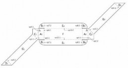

Ver Fascículo Completo

## E INVENÇÃO

### BBCA/1A

eguir indicados é efetuada nos termos do disposto no artigo ação do presente aviso começa a contar-se o prazo de dois prejudicado pela eventual concessão dos mesmos, nos termos

### Concessõe

[output not shown]

### s - FG4A

[output not shown]

### Patentes europeias vigen

[output not shown]

### tes em Portugal - FG4A

[output not shown]

### Recusas

| Processo | Data do pedido | Data da recusa | Nome do 1º requ |
| --- | --- | --- | --- |
| 116438 | 2020.05.28 | 2025.07.08 | PAGOLI-CÁPSULAS, LD |

### - FC4A

| erente/titular | País resid. | Classificação principal | Observações |
| --- | --- | --- | --- |
| A. | PT | B65D 41/62 (2006.01) | recusado nos termos do nº 9 do artigo 70º, com referência à alínea a) do nº 1 do artigo 75º, do cpi. |

### Caducidades por falta de pagamento

[output not shown]

### de taxa - Patente europeia - MM4A

[output not shown]

r

### Caducidades por limite de vigên

[output not shown]

### cia - Patente europeia - MM3A

| equerente/titular | País resid. | Observações |
| --- | --- | --- |
| MBH & CO. KG | DE FI |  |

r

BOLETIM DA PROPRIEDAD

### Averbamentos - Patente europ

Outros averbamentos (art

| Processo | Data do averbamento | Nome do 1º requerente/titular |
| --- | --- | --- |
| 2833899 | 2025.07.03 | LXBIO - PHARMACEUTICALS, S.A. |

### eia - PD1A, PD3A, PC1A, PC3A

igo 29.º) - Patente europeia

|  | País resid. | Observações |
| --- | --- | --- |
|  | PT | RENÚNCIA À COTITULARIDADE, POR PARTE DA TECNIFAR- INDÚSTRIA TÉCNICA FARMACÊUTICA, S.A., NOS TERMOS DO PREVISTO PELO Nº 2 DO ART. 37º DO CPI, PASSANDO A CONSTAR NO PROCESSO OS SEGUINTES TITULARES: LXBI… |

### Outros At

120044. – INDEFERIDO NOS TERMOS DO N.º 9 DO ARTIGO

### os - HK4A

64.º E DA ALÍNEA C) DO N.º 1 DO ARTIGO 23.º DO CPI.

### Outros Atos - Paten

3545079. – FASCÍCULO MODIFICADO: NOS TERMOS D FASCÍCULO APÓS OPOSIÇÃO.

### te europeia - HK4A

O ART.84º DO CPI, É PUBLICADA A MODIFICAÇÃO DO

## CERTIFICADOS COMPLEM

### Caducidades por

| Processo | Início de vigência | Data da caducidade | Nome do 1º |
| --- | --- | --- | --- |
| 566 | 2020.07.05 | 2025.07.04 | BAYER CROPSCIENCE AKTIENGESELLSCHAF |

## ENTARES DE PROTECÇÃO

### limite de vigência

| equerente/titular | País resid. | Observações |
| --- | --- | --- |
| T | DE |  |

r

### Ped

[output not shown]

Conteúdo dos dados

País resid.

de 2012.07.20

ING GMBH DE

TED AU

País: PT, Número: C(2025)994

## MODELOS I

### Caducidades por limit

| Processo | Início de vigência | Data da caducidade | Nome do 1º r |
| --- | --- | --- | --- |
| 29793 | 2000.07.04 | 2025.07.04 | UNILEVER N.V. |

## NDUSTRIAIS

### e de vigência - MM3L

| equerente/titular | País resid. | Observações |
| --- | --- | --- |
|  | NL |  |

## REGISTO NACIO

### Ped

De acordo com o artigo 226.º do Código da Propried marcas; da data de publicação do presente aviso começa reclamações de quem se julgar prejudicado pela eventual con mesmo Código.

(210) **747351 MNA**

(220) 2025.06.05

(300)

(730) PT **MUNICIPIO DE OEIRAS**

(511) 41 ORGANIZAÇÃO E REALIZAÇÃO DE EVENTOS DE ENTRETENIMENTO; SERVIÇOS CULTURAIS, EDUCATIVOS OU DE ENTRETENIMENTO PRESTADOS POR GALERIAS DE ARTE.

(591)

(540)

[figure not shown]

(531) 2.5.23

(210) **747353 MNA**

(220) 2025.06.05

(300)

(730) PT **NELSON DEODATO VALADÃO FURTADO**

PT **SARA FILIPA NETO DO ROSÁRIO**

PT **ADRIANA PINHEIRO VIVEIROS**

(511) 35 PROMOÇÃO DE COMPETIÇÕES E EVENTOS DESPORTIVOS.

41 PLANEAMENTO DE EVENTOS DESPORTIVOS; ORGANIZAÇÃO E REALIZAÇÃO DE EVENTOS DESPORTIVOS.

(591)

(540)

## NAL DE MARCAS

### dos

ade Industrial, a seguir se publicam os pedidos de registo de a contar-se o prazo de dois meses para a apresentação de cessão dos mesmos, em conformidade com o artigo 17.º do

[figure not shown]

| (531) | 7.1.16 |  |
| --- | --- | --- |
| (210) | 747471 | MNA |
| (220) | 2025.06.06 |  |
| (300) |  |  |
| (730) | PT **CALÇADANÓMADA, LDA** |  |
| (511) | 36 CONSULTADORIA IMOBILIÁRIA; | MEDIAÇÃO |
|  | IMOBILIÁRIA; AGÊNCIA | IMOBILIÁRIA; |

AVALIAÇÕES IMOBILIÁRIAS.

(591) 218,1 65, 32 E PRETO.

(540)

| (531) | 7.1.24 |
| --- | --- |
| (210) | 747953 MNA |
| (220) | 2025.06.17 |
| (300) |  |

(730) BR **GABRIEL KEHLER SILVA DE SOUZA**

(511) 43 SERVIÇOS DE RESTAURAÇÃO [ALIMENTAÇÃO E BEBIDAS].

(591)

(540)

INFINITY AÇAÍ

(210) **748157 MNA**

(220) 2025.06.20

(300)

(730) PT **NEST4PROSPERITY - CONSULTORIA, LDA**

(511) 35 PREPARAÇÃO DE DOCUMENTOS; SERVIÇOS DE CONSULTORIA EMPRESARIAL; FORNECIMENTO DE INFORMAÇÕES RELATIVAS AO RECRUTAMENTO DE EMPREGO.

41 ACONSELHAMENTO SOBRE CARREIRAS E ORIENTAÇÃO PROFISSIONAL; ASSESSORIA E ORIENTAÇÃO PROFISSIONAL [ASSESSORIA EM MATÉRIA DE EDUCAÇÃO E FORMAÇÃO].

(591)

(540)

(531) 26.1.3 ; 26.1.18 ; 26.1.24 ; 27.5.22 ; 27.99.13 ; 27.99.22

| (210) | 748215 | MNA |
| --- | --- | --- |
| (220) | 2025.06.21 |  |
| (300) |  |  |
| (730) | PT **PRADA & PRADA, LDA.** |  |
| (511) | 43 SERVIÇOS DE RESTAURANTES SERVIÇOS DE RESTAURANTES; | TAKE-AWAY; SERVIÇOS DE |

RESTAURANTES SELF-SERVICE; RESTAURANTES DE GRELHADOS; SERVIÇOS DE SNACK-BAR.

(591) ouro; preto

(540)

[figure not shown]

(531) 27.99.18 ; 27.99.19

(210) **748216 MNA**

(220) 2025.06.21

(300)

(730) PT **CREATIVE CIRCLE - GESTÃO DE PORTAIS UNIPESSOAL LDA.**

(511) 35 SERVIÇOS DE PUBLICIDADE, DE MARKETING E DE PROMOÇÃO; SERVIÇOS DE PUBLICIDADE, DE MARKETING E PROMOCIONAIS; SERVIÇOS DE PUBLICIDADE, DE PROMOÇÃO E DE MARKETING; PUBLICIDADE NA ÁREA DE TURISMO E VIAGENS; MARKETING; MARKETING DIGITAL; MARKETING DIRECIONADO; MARKETING AFILIADO; MARKETING DIRETO; MARKETING PROMOCIONAL; MARKETING DE INFLUENCIADOR; CONSULTADORIA DE MARKETING; ASSESSORIA EM MARKETING; MARKETING DE REFERÊNCIA; MARKETING DE INTERNET; SERVIÇOS DE MARKETING; PUBLICIDADE E MARKETING; INFORMAÇÕES SOBRE MARKETING; CONSULTADORIA RELACIONADA COM MARKETING; CONSULTORIA EM MARKETING EMPRESARIAL; CONSULTORIA EM MARKETING DIRETO; SERVIÇOS DE MARKETING AFILIADO; SERVIÇOS DE MARKETING EMPRESARIAL; ADMINISTRAÇÃO RELACIONADA COM MARKETING; DESENVOLVIMENTO DE PLANOS DE MARKETING; DESENVOLVIMENTO DE CONCEITOS DE MARKETING; MARKETING DIRECIONADO PARA ALVOS ESPECÍFICOS; SERVIÇOS DE ASSESSORIA EM MARKETING; SERVIÇOS DE CONSULTADORIA DE MARKETING; SERVIÇOS DE MARKETING DE REFERÊNCIA; SERVIÇOS DE MARKETING DE INTERNET; MARKETING DE BASES DE DADOS; PLANEAMENTO DE ESTRATÉGIAS DE MARKETING; ELABORAÇÃO DE RELATÓRIOS DE MARKETING; ASSESSORIA EM GESTÃO DE MARKETING; SERVIÇOS DE PUBLICIDADE E MARKETING; CONSULTORIA EM PUBLICIDADE E MARKETING; SERVIÇOS DE AGÊNCIAS DE MARKETING; SERVIÇOS DE ASSESSORIA RELACIONADOS COM MARKETING; MARKETING SOB A FORMA DE EVENTOS; FORNECIMENTO DE INFORMAÇÕES DE MARKETING EMPRESARIAL; ASSESSORIA RELATIVA A GESTÃO DE MARKETING; PROMOÇÃO, PUBLICIDADE E MARKETING EM WEBSITES; CONSULTADORIA PROFISSIONAL EM MATÉRIA DE MARKETING; PRESTAÇÃO DE INFORMAÇÕES RELACIONADAS COM MARKETING; PESQUISAS DE MERCADO E ESTUDOS DE MARKETING; SERVIÇOS DE MARKETING NO ÂMBITO DE VIAGENS; SERVIÇOS DE CONSULTADORIA EM MATÉRIA DE MARKETING; MARKETING NO ÂMBITO DA PUBLICAÇÃO DE SOFTWARE; SERVIÇOS DE PUBLICIDADE E MARKETING EM LINHA; ORGANIZAÇÃO E REALIZAÇÃO DE EVENTOS DE MARKETING; ACONSELHAMENTO EM MATÉRIA DE GESTÃO DE MARKETING; DESENVOLVIMENTO DE ESTRATÉGIAS E CONCEITOS DE MARKETING; SERVIÇOS DE PLANEAMENTO PARA ESTUDOS DE MARKETING; PROMOÇÃO, PUBLICIDADE E MARKETING DE PÁGINAS ONLINE; MARKETING DE PRODUTOS E SERVIÇOS DE TERCEIROS; SERVIÇOS DE CONSULTADORIA NO DOMÍNIO DO MARKETING DIGITAL; SERVIÇOS DE CONSULTADORIA COMERCIAL EM MATÉRIA DE MARKETING; DIFUSÃO DE MATERIAL PROMOCIONAL, PUBLICITÁRIO E DE MARKETING; MARKETING NO ÂMBITO DE EDIÇÃO DE PROGRAMAS INFORMÁTICOS; SERVIÇOS DE MARKETING PROMOCIONAL, ATRAVÉS DE MEIOS AUDIOVISUAIS; SERVIÇOS DE CONSULTORIA NA ÁREA DE MARKETING AFILIADO; SERVIÇOS DE CONSULTORIA NA ÁREA DE MARKETING DE INTERNET; SERVIÇOS DE MARKETING PRESTADOS POR MEIO DE REDES DIGITAIS; SERVIÇOS DE PUBLICIDADE E MARKETING FORNECIDOS ATRAVÉS DE BLOGUES; FORNECIMENTO DE INFORMAÇÕES DE MARKETING ATRAVÉS DE SITES WEB; PRODUÇÃO DE GRAVAÇÕES DE SOM PARA FINS DE MARKETING; PRODUÇÃO DE GRAVAÇÕES DE VÍDEO PARA FINS DE

MARKETING; SERVIÇOS DE MARKETING NO DOMÍNIO DA OTIMIZAÇÃO DE TRÁFEGO DE WEBSITES; SERVIÇOS DE PUBLICIDADE E MARKETING FORNECIDOS ATRAVÉS DE CANAIS DE COMUNICAÇÃO; SERVIÇOS DE CONSULTORIA, ACONSELHAMENTO E ASSISTÊNCIA EM PUBLICIDADE, MARKETING E PROMOÇÃO; MARKETING ATRAVÉS DA COLOCAÇÃO DE PRODUTOS PARA TERCEIROS EM AMBIENTES VIRTUAIS; SERVIÇOS DE CONSULTADORIA DE NEGÓCIOS, RELACIONADOS COM O MARKETING DE CAMPANHAS DE ANGARIAÇÃO DE FUNDOS; PRESTAÇÃO DE CONSULTADORIA DE MARKETING NO DOMÍNIO DOS MEIOS DE COMUNICAÇÃO SOCIAL; DIVULGAÇÃO DE PUBLICIDADE; ANÚNCIOS PUBLICITÁRIOS ONLINE.

36 SERVIÇOS DE AGÊNCIAS DE ALOJAMENTO TEMPORÁRIO [APARTAMENTOS]; SERVIÇOS DE SEGUROS RELACIONADOS COM ALOJAMENTOS DE FÉRIAS.

39 VISITAS TURÍSTICAS; ORGANIZAÇÃO DE VISITAS TURÍSTICAS; SERVIÇOS DE VISITAS TURÍSTICAS; ORGANIZAÇÃO DE VISITAS TURÍSTICAS DE AUTOCARRO; SERVIÇOS DE TRANSPORTE PARA VISITAS TURÍSTICAS; ORGANIZAÇÃO E RESERVA DE VISITAS TURÍSTICAS; ORGANIZAÇÃO DE VISITAS A LUGARES TURÍSTICOS; SERVIÇOS DE RESERVA DE VISITAS TURÍSTICAS; RESERVAS DE VISITAS TURÍSTICAS ATRAVÉS DE AGÊNCIAS; ORGANIZAÇÃO DE VISITAS TURÍSTICAS POR TRANSPORTE SIGHTSEEING; PLANEAMENTO E ORGANIZAÇÃO DE VISITAS TURÍSTICAS E EXCURSÕES; ORGANIZAÇÃO E RESERVA DE EXCURSÕES E VISITAS TURÍSTICAS; DISPONIBILIZAÇÃO DE VEÍCULOS PARA VISITAS TURÍSTICAS E EXCURSÕES; ORGANIZAÇÃO E RESERVA DE VISITAS TURÍSTICAS DE CIDADES; RESERVA DE VIAGENS DE FÉRIAS E VISITAS TURÍSTICAS; ORGANIZAÇÃO DE EXCURSÕES E VISITAS A LOCAIS TURÍSTICOS; SERVIÇOS DE AGÊNCIA DE RESERVAS PARA VISITAS TURÍSTICAS; DISPONIBILIZAÇÃO DE INFORMAÇÃO A TURISTAS SOBRE EXCURSÕES E VISITAS TURÍSTICAS; ORGANIZAÇÃO DE EXCURSÕES, EXCURSÕES DE UM DIA E VISITAS TURÍSTICAS; ORGANIZAÇÃO DE VISITAS A LUGARES TURÍSTICOS COMO PARTE DE PACOTES DE FÉRIAS; SERVIÇOS PARA RESERVAS DE VIAGENS; SERVIÇOS DE RESERVAS PARA VIAGENS AÉREAS; RESERVAS DE CAMAROTES PARA VIAGENS; SERVIÇOS DE RESERVAS PARA VIAGENS MARÍTIMAS; SERVIÇOS DE AGÊNCIA DE RESERVAS PARA VIAGENS; RESERVAS E MARCAÇÕES DE ASSENTOS PARA VIAGENS; SERVIÇOS DE RESERVAS PARA VIAGENS POR TERRA; ORGANIZAÇÃO DE EXCURSÕES PARA TURISTAS; SERVIÇOS PARA ORGANIZAÇÃO DE EXCURSÕES PARA TURISTAS; ORGANIZAÇÃO DE TRANSPORTE PARA EXCURSÕES DE TURISMO; RESERVA DE VIAGENS ATRAVÉS DE AGÊNCIAS DE TURISMO.

1. REALIZAÇÃO DE VISITAS GUIADAS; ORIENTAÇÃO DE VISITAS GUIADAS; ORGANIZAÇÃO DE VISITAS EDUCATIVAS GUIADAS; REALIZAÇÃO DE VISITAS GUIADAS EDUCATIVAS; FORNECIMENTO DE VISITAS GUIADAS VIRTUAIS ONLINE; ORGANIZAÇÃO DE VISITAS PARA FINS DE FORMAÇÃO; REALIZAÇÃO DE VISITAS GUIADAS A GRUTAS COM FINS EDUCATIVOS; REALIZAÇÃO DE VISITAS GUIADAS A SÍTIOS DE INTERESSE CULTURAL PARA FINS EDUCATIVOS; RESERVAS PARA ESPETÁCULOS; ORGANIZAÇÃO DE RESERVAS DE BILHETES PARA ESPETÁCULOS E OUTROS EVENTOS DE ENTRETENIMENTO; ORGANIZAÇÃO DE CURSOS DE INSTRUÇÃO PARA TURISTAS; PUBLICAÇÃO DE DIRETÓRIOS RELACIONADOS COM TURISMO; SERVIÇOS DE FORMAÇÃO RELACIONADOS COM AÇÕES DE

   MARKETING PARA O COMÉRCIO A RETALHO; CURSOS DE FORMAÇÃO EM PLANEAMENTO ESTRATÉGICO RELACIONADO COM PUBLICIDADE, PROMOÇÃO, MARKETING E EMPRESAS; SERVIÇOS DE TRADUÇÃO; PRESTAÇÃO DE SERVIÇOS DE TRADUÇÃO; FORNECIMENTO DE SERVIÇOS DE TRADUÇÃO ON-LINE; SERVIÇOS RELACIONADOS COM TRADUÇÃO; TRADUÇÃO DE LÍNGUAS; CRIAÇÃO [ESCRITA] DE PODCASTS; SERVIÇOS DE ESCRITA DE GUIÕES; SERVIÇOS DE ESCRITA POR ENCOMENDA PARA FINS NÃO PUBLICITÁRIOS; EDIÇÃO DE VÍDEO; EDIÇÃO DE GRAVAÇÕES DE VÍDEO; SERVIÇOS DE EDIÇÃO DE ÁUDIO E VÍDEO; EDIÇÃO DE TEXTOS ESCRITOS; DISPONIBILIZAÇÃO DE PUBLICAÇÕES ON-LINE; EDIÇÃO DE E-BOOKS (LIVROS ELETRÓNICOS); EDIÇÃO DE PUBLICAÇÕES; EDIÇÃO ELETRÓNICA; EDIÇÃO MULTIMÉDIA; ELABORAÇÃO DE GUIÕES; EDIÇÃO DE TEXTOS, COM EXCEÇÃO DE TEXTOS PUBLICITÁRIOS; ELABORAÇÃO DE GUIÕES DE FILMES; ESCRITA DE GUIÕES PARA TELEVISÃO; FORNECIMENTO DE PUBLICAÇÕES ATRAVÉS DE UMA REDE INFORMÁTICA MUNDIAL OU DA INTERNET QUE PODEM SER PESQUISADAS; FORNECIMENTO DE PUBLICAÇÕES ELECTRÓNICAS RELATIVAS À FORMAÇÃO LINGUÍSTICA, NÃO PARA DOWNLOAD; PUBLICAÇÃO DE DOCUMENTOS; PUBLICAÇÃO DE DIRETÓRIOS RELACIONADOS COM VIAGENS; PUBLICAÇÃO DE CATÁLOGOS; PUBLICAÇÃO DE BROCHURAS; PUBLICAÇÃO DE BOLETINS INFORMATIVOS; PUBLICAÇÃO DE FOLHETOS; PUBLICAÇÃO DE FOTOGRAFIAS; PUBLICAÇÃO DE GUIAS PEDAGÓGICOS E FORMATIVOS; PUBLICAÇÃO DE JORNAIS, REVISTAS, CATÁLOGOS E BROCHURAS; PUBLICAÇÃO DE LITERATURA INSTRUTIVA; PUBLICAÇÃO DE LIVROS; PUBLICAÇÃO DE LIVROS DE INSTRUÇÕES; PUBLICAÇÃO DE LIVROS DE ÁUDIO; PUBLICAÇÃO DE MANUAIS DE FORMAÇÃO; PUBLICAÇÃO DE LIVROS, REVISTAS, ALMANAQUES E DIÁRIOS; PUBLICAÇÃO DE LIVROS RELACIONADOS COM O ENTRETENIMENTO; PUBLICAÇÃO DE LIVROS GUIA ONLINE, MAPAS, DIRETÓRIOS E LISTAGENS PARA USO POR VIAJANTES, NÃO PASSÍVEIS DE DOWNLOAD; PUBLICAÇÃO DE LIVROS ELETRÓNICOS E PUBLICAÇÕES PERIÓDICAS NA INTERNET; PUBLICAÇÃO DE LIVROS E REVISTAS ELETRÓNICAS ON-LINE; PUBLICAÇÃO DE LIVROS DE TEXTO; WORKSHOPS DE FORMAÇÃO; WORKSHOPS PARA FINS CULTURAIS; WORKSHOPS PARA FINS RECREATIVOS; WORKSHOPS PARA FINS EDUCATIVOS; ORGANIZAÇÃO DE WORKSHOPS E SEMINÁRIOS; ORGANIZAÇÃO E REALIZAÇÃO DE WORKSHOPS; DIREÇÃO DE CURSOS, SEMINÁRIOS E WORKSHOPS; PREPARAÇÃO, DIREÇÃO E ORGANIZAÇÃO DE WORKSHOPS [FORMAÇÃO]; DIREÇÃO DE WORKSHOPS E SEMINÁRIOS SOBRE AUTOCONSCIÊNCIA; ORGANIZAÇÃO E DIREÇÃO DE WORKSHOPS DE FORMAÇÃO; ORGANIZAÇÃO E REALIZAÇÃO DE SEMINÁRIOS E WORKSHOPS [FORMAÇÃO]; ORGANIZAÇÃO DE WORKSHOPS PROFISSIONAIS E CURSOS DE FORMAÇÃO; ORGANIZAÇÃO DE WEBINARS (SEMINÁRIOS ONLINE); FORMAÇÃO PRÁTICA; FORMAÇÃO PRÁTICA [DEMONSTRAÇÃO]; FORMAÇÃO PROFISSIONAL; SERVIÇOS DE FORMAÇÃO PROFISSIONAL; PRESTAÇÃO DE CURSOS DE FORMAÇÃO PROFISSIONAL; ORIENTAÇÃO PROFISSIONAL [CONSULTORIA EM EDUCAÇÃO OU FORMAÇÃO]; FORMAÇÃO INFORMATIZADA EM MATÉRIA DE ORIENTAÇÃO PROFISSIONAL; ASSESSORIA E ORIENTAÇÃO PROFISSIONAL [ASSESSORIA EM MATÉRIA DE EDUCAÇÃO E FORMAÇÃO]; PRESTAÇÃO DE INFORMAÇÕES E NOTÍCIAS ON-LINE NO DOMÍNIO DA FORMAÇÃO PROFISSIONAL; SERVIÇOS DE FORMAÇÃO E

   ENSINO; DISPONIBILIZAÇÃO DE FORMAÇÃO ONLINE.
2. ALUGUER DE ALOJAMENTO TEMPORÁRIO.
3. SERVIÇOS DE AGÊNCIAS DE VIAGENS PARA A MARCAÇÃO DE RESERVAS EM RESTAURANTES; RESERVAS DE HOTÉIS; SERVIÇOS DE RESERVAS PARA HOTÉIS; REALIZAÇÃO DE RESERVAS DE HOTÉIS PARA TERCEIROS; FORNECIMENTO DE INFORMAÇÃO ONLINE SOBRE RESERVAS DE HOTÉIS; DISPONIBILIZAÇÃO DE INFORMAÇÃO ONLINE SOBRE RESERVAS DE ALOJAMENTO EM FÉRIAS; RESERVAS DE ALOJAMENTO; RESERVAS DE ALOJAMENTO TEMPORÁRIO; RESERVAS DE ALOJAMENTOS TEMPORÁRIOS; SERVIÇOS DE RESERVAS DE ALOJAMENTO; SERVIÇOS DE RESERVAS PARA ALOJAMENTO; SERVIÇOS DE AGÊNCIAS DE TURISMO PARA RESERVAS DE ALOJAMENTO; SERVIÇOS DE RESERVAS DE ALOJAMENTO EM REGIME TIME-SHARING; SERVIÇOS DE AGÊNCIAS DE RESERVAS DE ALOJAMENTOS DE FÉRIAS; SERVIÇOS DE AGÊNCIA DE RESERVAS DE ALOJAMENTO EM REGIME DE TIME-SHARING; ALOJAMENTO TEMPORÁRIO; FORNECIMENTO DE ALOJAMENTO TEMPORÁRIO; SERVIÇOS DE ALOJAMENTO TEMPORÁRIO; ORGANIZAÇÃO DE ALOJAMENTO TEMPORÁRIO; RESERVA DE ALOJAMENTO TEMPORÁRIO; ALUGUER DE ALOJAMENTO TEMPORÁRIO; FORNECIMENTO DE ALOJAMENTOS TEMPORÁRIOS; FORNECIMENTO DE ALOJAMENTO HABITACIONAL TEMPORÁRIO; FORNECIMENTO DE ALOJAMENTOS TEMPORÁRIOS MOBILADOS; ORGANIZAÇÃO E FORNECIMENTO DE ALOJAMENTO TEMPORÁRIO; DISPONIBILIZAÇÃO DE ALOJAMENTO TEMPORÁRIO EM PENSÕES; RESERVA DE ALOJAMENTO TEMPORÁRIO VIA INTERNET; DISPONIBILIZAÇÃO DE ALOJAMENTO TEMPORÁRIO PARA HÓSPEDES; DISPONIBILIZAÇÃO DE ACOMODAÇÕES PARA ALOJAMENTO TEMPORÁRIO; ALUGUER DE QUARTOS ENQUANTO ALOJAMENTO TEMPORÁRIO; FORNECIMENTO DE ALOJAMENTO TEMPORÁRIO PARA TRABALHO; AGÊNCIAS DE ALOJAMENTO TEMPORÁRIO [HOTÉIS, PENSÕES]; SERVIÇOS DE ALOJAMENTO TEMPORÁRIO EM CAMPOS DE FÉRIAS; DISPONIBILIZAÇÃO DE INFORMAÇÃO SOBRE ALOJAMENTO TEMPORÁRIO VIA INTERNET; RESERVA DE ALOJAMENTO TEMPORÁRIO EM CASAS DE FÉRIAS; FORNECIMENTO DE ALOJAMENTO TEMPORÁRIO EM APARTAMENTOS DE FÉRIAS; DISPONIBILIZAÇÃO DE ALOJAMENTO TEMPORÁRIO EM CASAS DE FÉRIAS; SERVIÇOS DE AGÊNCIAS DE ALOJAMENTO TEMPORÁRIO [HOTÉIS, PENSÕES]; SERVIÇOS DE BENEFICÊNCIA, NOMEADAMENTE FORNECIMENTO DE ALOJAMENTO TEMPORÁRIO; SERVIÇOS DE RECEÇÃO PARA ALOJAMENTO TEMPORÁRIO [ENTREGA DE CHAVES]; SERVIÇOS DE AGÊNCIA PARA A RESERVA DE ALOJAMENTO TEMPORÁRIO; SERVIÇOS DE RECEPÇÃO PARA ALOJAMENTO TEMPORÁRIO [ENTREGA DE CHAVES]; SERVIÇOS DE RECEÇÃO PARA ALOJAMENTO TEMPORÁRIO [ATRIBUIÇÃO DE CHAVES]; SERVIÇOS DE ABRIGO DE EMERGÊNCIA [FORNECIMENTO DE ALOJAMENTO TEMPORÁRIO]; SERVIÇOS DE AGÊNCIAS DE VIAGENS PARA RESERVA DE ALOJAMENTO TEMPORÁRIO; ALUGUER DE ALOJAMENTO TEMPORÁRIO EM CASAS E APARTAMENTOS DE FÉRIAS; DISPONIBILIZAÇÃO DE ALOJAMENTO TEMPORÁRIO COMO PARTE DE PACOTES DE HOSPITALIDADE; SERVIÇOS DE INFORMAÇÃO, ACONSELHAMENTO E RESERVA RELATIVOS A ALOJAMENTO TEMPORÁRIO; SERVIÇOS DE OPERADORES TURÍSTICOS PARA A RESERVA DE ALOJAMENTO TEMPORÁRIO; SERVIÇOS DE RECEÇÃO PARA ALOJAMENTO TEMPORÁRIO [GESTÃO DE CHEGADAS E

PARTIDAS]; CONSULTORIA FORNECIDA POR CENTROS DE CHAMADAS E LINHAS DIRETAS NA ÁREA DO ALOJAMENTO TEMPORÁRIO; SERVIÇOS DE ALOJAMENTO HOTELEIRO; SERVIÇOS DE HOSPITALIDADE [ALOJAMENTO]; SERVIÇOS DE ALOJAMENTO EM HOTEL; SERVIÇOS DE ALOJAMENTO EM HOTÉIS; SERVIÇOS DE ALOJAMENTO PARA TURISTAS; SERVIÇOS DE AGÊNCIAS DE ALOJAMENTO; SERVIÇOS PARA MARCAÇÃO DE ALOJAMENTO; SERVIÇOS DE ALOJAMENTOS PARA FÉRIAS; SERVIÇOS DE ALOJAMENTO E PEQUENO-ALMOÇO; SERVIÇOS DE ALOJAMENTO EM COMPLEXOS HOTELEIROS; SERVIÇOS DE ACAMPAMENTO PARA TURISTAS [ALOJAMENTO]; GESTÃO DOS SERVIÇOS DE ALOJAMENTO PARA MEMBROS; SERVIÇOS DE RESERVA DE ALOJAMENTO EM HOTÉIS; SERVIÇOS PARA RESERVA DE ALOJAMENTO DE FÉRIAS; SERVIÇOS DE RESERVA PARA MARCAÇÃO DE ALOJAMENTO; SERVIÇOS DE AGÊNCIA DE VIAGENS PARA RESERVA DE ALOJAMENTO; SERVIÇOS DE AGÊNCIA DE MARCAÇÃO DE ALOJAMENTO EM HOTÉIS; SERVIÇOS DE AGÊNCIA PARA RESERVA DE ALOJAMENTOS EM HOTÉIS; PRESTAÇÃO DE SERVIÇOS DE INFORMAÇÃO SOBRE ALOJAMENTO DE VIAGENS E DE SERVIÇOS DE AGÊNCIAS DE RESERVA DE ALOJAMENTO DE VIAGENS PARA VIAJANTES; SERVIÇOS DE AGÊNCIA DE VIAGENS PARA RESERVA DE ALOJAMENTO EM HOTÉIS; SERVIÇOS DE CASAS DE TURISMO; HOTÉIS, POUSADAS E ALBERGUES, ALOJAMENTO PARA FÉRIAS E TURISMO.

(591) amarelo #fbc03a; azul #0d2960

(540)

[figure not shown]

| (531) | 1.1.10 ; 21.3.21 |
| --- | --- |
| (210) | 748217 MNA |
| (220) | 2025.06.21 |
| (300) |  |
| (730) | PT **NEWPRESS, COMUNICAÇÃO E** |

INFORMAÇÃO, LDA

(511) 41 PUBLICAÇÃO, RELATO E REDAÇÃO DE TEXTOS; PUBLICAÇÃO MULTIMÉDIA DE REVISTAS, REVISTAS ESPECIALIZADAS E JORNAIS; SERVIÇOS DE JORNALISMO.

(591) Azul, Laranja e Branco

(540)

(531) 25.5.94

(210) **748226 MNA**

(220) 2025.06.23

(300)

(730) PT **RISO FUGAZ - MEDICINA DENTÁRIA, LDA**

(511) 44 CUIDADOS DE SAÚDE; MEDICINA DENTÁRIA.

(591) CINZA, AZUL ESCURO E AZUL TURQUESA.

(540)

[figure not shown]

(531) 2.9.8 ; 26.11.8

(210) **748236 MNA**

(220) 2025.06.23

(300)

(730) PT **TRIÂNGULEMFESTA UNIPESSOAL LDA**

(511) 41 ATIVIDADES DE DIVERSÃO, DESPORTIVAS E CULTURAIS; CENTROS DE DIVERSÃO; FORNECIMENTO DE INSTALAÇÕES DE DIVERSÕES; FORNECIMENTO DE INSTALAÇÕES DE JOGOS PARA CRIANÇAS; FORNECIMENTO DE SERVIÇOS DE DIVERTIMENTO PARA CRIANÇAS; SERVIÇOS DE PARQUES INFANTIS DE AVENTURA; REALIZAÇÃO DE ATIVIDADES DE ENTRETENIMENTO; PLANEAMENTO DE FESTAS [DIVERTIMENTO]; PLANEAMENTO DE FESTAS; PINTURA FACIAL; ORGANIZAÇÃO E REALIZAÇÃO DE ATIVIDADES DE ENTRETENIMENTO; ORGANIZAÇÃO DE FESTAS; ORGANIZAÇÃO E REALIZAÇÃO DE FESTAS [ENTRETENIMENTO]; ORGANIZAÇÃO DE ENTRETENIMENTO PARA FESTAS DE ANIVERSÁRIO.

(591) Pantone 4725C, Pantone Black 6C e Pantone 4695C

(540)

[figure not shown]

(531) 4.5.7

(210) **748241 MNA**

(220) 2025.06.23

(300)

(730) PT **UNANIME EMPIRE, LDA**

(511) 09 SOFTWARE; PROGRAMAS DE SOFTWARE; PLATAFORMAS DE SOFTWARE, GRAVADO OU DESCARREGÁVEL; PROGRAMAS DE COMPUTADOR PARA UTILIZAÇÃO EM TELECOMUNICAÇÕES; SOFTWARE DESCARREGÁVEL A PARTIR DA INTERNET; SOFTWARE E APLICAÇÕES PARA DISPOSITIVOS MÓVEIS; SOFTWARE INFORMÁTICO PARA TELEMÓVEIS; SOFTWARE PARA DOWNLOAD; SOFTWARE PARA TELEMÓVEIS; SOFTWARE PARA USO EM DISPOSITIVOS ELECTRÓNICOS DIGITAIS DE BOLSO E MÓVEIS E OUTROS PRODUTOS DE ELECTRÓNICA DE CONSUMO.

39 TRANSPORTE; DISPONIBILIZAÇÃO DE TRANSPORTE TERRESTRE, MARÍTIMO E AÉREO; CORRETAGEM/AGÊNCIAS DE TRANSPORTE; CORRETAGEM DE TRANSPORTE; FRETAMENTO DE VEÍCULOS PARA TRANSPORTE; GESTÃO DO FLUXO DE TRÁFEGO DE VEÍCULOS ATRAVÉS DE REDES E TECNOLOGIAS DE COMUNICAÇÃO AVANÇADAS; LOGÍSTICA DE TRANSPORTE; MEDIAÇÃO DE SERVIÇOS DE TRANSPORTE; ORGANIZAÇÃO DE SERVIÇOS DE TRANSPORTE; ORGANIZAÇÃO DE SERVIÇOS DE TRANSPORTE POR TERRA, ÁGUA E AR; ORGANIZAÇÃO DE TRANSPORTE AÉREO; ORGANIZAÇÃO DE TRANSPORTE E VIAGENS; ORGANIZAÇÃO DE TRANSPORTES; ORGANIZAÇÃO DO TRANSPORTE DE PASSAGEIROS POR VIA RODOVIÁRIA, FERROVIÁRIA, MARÍTIMA E AÉREA; ORGANIZAÇÕES DE TRANSPORTES POR TERRA, MAR E AR; SERVIÇOS DE LOGÍSTICA RELACIONADOS COM TRANSPORTE; SERVIÇOS DE TRANSFERÊNCIA DE AEROPORTOS; SERVIÇOS DE TRANSPORTE; SERVIÇOS DE TRANSPORTE DE VEÍCULOS MOTORIZADOS; SERVIÇOS DE TRANSPORTE EM VEÍCULOS AUTOMÓVEIS; SERVIÇOS DE TRANSPORTE RODOVIÁRIO; SERVIÇOS DE TRANSPORTE RODOVIÁRIO DE MERCADORIAS; SERVIÇOS DE TRANSPORTES POR ESTRADA; SERVIÇOS PARA ORGANIZAÇÃO DE TRANSPORTE; SERVIÇOS PARA ORGANIZAÇÃO DE TRANSPORTE RODOVIÁRIO; SERVIÇOS PARA TRANSPORTE; SERVIÇOS TRANSITÁRIOS; TRANSPORTE DE PASSAGEIROS; TRANSPORTE DE PASSAGEIROS [VIAJANTES]; TRANSPORTE E ENTREGA DE MERCADORIAS; TRANSPORTE EM AUTOMÓVEIS; TRANSPORTE POR ESTRADA; VIAGENS E TRANSPORTE DE PASSAGEIROS; TRANSPORTE POR TERRA; TRANSPORTE POR VEÍCULOS MOTORIZADOS DE DUAS RODAS.

42 ALUGUER DE HARDWARE E INSTALAÇÕES INFORMÁTICAS; ALUGUER DE HARDWARE E SOFTWARE; SERVIÇOS DE TI (TECNOLOGIAS DE INFORMAÇÃO); ADMINISTRAÇÃO DE SERVIDORES; ATUALIZAÇÃO DE WEBSITES PARA TERCEIROS; CONCEÇÃO E DESENVOLVIMENTO DE SISTEMAS DE ARMAZENAMENTO DE DADOS; CONCEÇÃO E DESENVOLVIMENTO DE SOFTWARE DE BASES DE DADOS ELETRÓNICAS; CONCEÇÃO, CRIAÇÃO E PROGRAMAÇÃO DE PÁGINAS WEB; CONSULTORIA EM SEGURANÇA DE DADOS; CRIAÇÃO DE PLATAFORMAS INFORMÁTICAS PARA TERCEIROS; GESTÃO DE PROJETOS INFORMÁTICOS EM PROCESSAMENTO ELETRÓNICO DE DADOS [PED]; GESTÃO DE PROJETOS DE TI; INTEGRAÇÃO DE SISTEMAS INFORMÁTICOS E REDES INFORMÁTICAS; FORNECIMENTO DE ACESSO TEMPORÁRIO A SOFTWARE NÃO DESCARREGÁVEL; FORNECIMENTO DE ACESSO TEMPORÁRIO A SOFTWARE PARA ENTRETENIMENTO INTERATIVO

NÃO DESCARREGÁVEL; FORNECIMENTO DE ACESSO TEMPORÁRIO A SOFTWARE INFORMÁTICO NÃO DESCARREGÁVEL PARA O SEGUIMENTO DE ENCOMENDAS ATRAVÉS DE REDES INFORMÁTICAS, INTRANETS E DA INTERNET; FORNECIMENTO DE ACESSO TEMPORÁRIO A SOFTWARE INFORMÁTICO NÃO DESCARREGÁVEL PARA USO NA CRIAÇÃO E PUBLICAÇÃO ON-LINE DE DIÁRIOS E BLOGUES; FORNECIMENTO DE ACESSO TEMPORÁRIO A SOFTWARE NÃO DESCARREGÁVEL PARA LOCALIZAÇÃO DE MERCADORIAS ATRAVÉS DE REDES INFORMÁTICAS, INTRANETS E DA INTERNET.

(591) FFFFFF; 18C4B8.

(540)

[figure not shown]

(531) 27.99.16 ; 27.99.21

(210) **748243 MNA**

(220) 2025.06.23

(300)

(730) PT **AB - AMBITIOUS BALANCE LDA**

(511) 32 CERVEJA E CERVEJA SEM ÁLCOOL; BEBIDAS SEM ÁLCOOL.

33 VINHOS; BEBIDAS ALCOÓLICAS EXCETO CERVEJA; BEBIDAS ALCOÓLICAS (EXCLUINDO CERVEJA).

1. FORNECIMENTO DE INFORMAÇÕES RELATIVAS A PRODUTOS DE CONSUMO NO ÂMBITO DE PRODUTOS ALIMENTARES E BEBIDAS; SERVIÇOS DE LOJA DE VENDA A RETALHO SEM PESSOAL RELACIONADO COM BEBIDAS; SERVIÇOS DE VENDA A RETALHO DE CHÁVENAS E COPOS; SERVIÇOS DE VENDA A RETALHO POR CATÁLOGO RELACIONADOS COM BEBIDAS ALCÓOLICAS (COM EXCEÇÃO DE CERVEJAS); SERVIÇOS DE VENDA A RETALHO POR CATÁLOGO RELACIONADOS COM BEBIDAS NÃO ALCOÓLICAS; SERVIÇOS DE VENDA POR GROSSO DE TAÇAS E COPOS; SERVIÇOS DE VENDA RETALHISTA POR CATÁLOGO RELACIONADOS COM CERVEJAS; SERVIÇOS DE VENDA RETALHISTA ATRAVÉS DE REDES INFORMÁTICAS MUNDIAIS RELACIONADOS COM CERVEJAS; SERVIÇOS DE VENDA RETALHISTA ATRAVÉS DE REDES INFORMÁTICAS MUNDIAIS RELACIONADOS COM BEBIDAS ALCOÓLICAS (COM EXCEÇÃO DE CERVEJA); SERVIÇOS DE VENDA RETALHISTA ATRAVÉS DE REDES INFORMÁTICAS MUNDIAIS RELACIONADOS COM BEBIDAS NÃO ALCOÓLICAS; SERVIÇOS DE VENDA RETALHISTA ATRAVÉS DE ENCOMENDA POR CORRESPONDÊNCIA RELACIONADOS COM BEBIDAS ALCOÓLICAS (COM EXCEÇÃO DE

   CERVEJAS); SERVIÇOS DE VENDA RETALHISTA ATRAVÉS DE ENCOMENDA POR CORRESPONDÊNCIA RELACIONADOS COM BEBIDAS NÃO ALCOÓLICAS; SERVIÇOS DE VENDA RETALHISTA ATRAVÉS DE ENCOMENDA POR CORRESPONDÊNCIA RELACIONADOS COM CERVEJAS; SERVIÇOS GROSSISTAS RELACIONADOS COM BEBIDAS ALCOÓLICAS (EXCETO CERVEJA); SERVIÇOS GROSSISTAS RELACIONADOS COM BEBIDAS NÃO ALCOÓLICAS.

   (591) Calcium, C3 M3 Y5 K0; Iron, C72 M70 Y52 K48

   (540)

   (531) 27.5.1

   (210) **748244 MNA**

   (220) 2025.06.23

   (300)

   (730) PT **ORLANDO JUNIOR**

   (511) 09 CONTEÚDOS GRAVADOS E DESCARREGÁVEIS; CONTEÚDOS DE MÉDIA.

   (591)

   (540)

[figure not shown]

   (531) 27.99.8

   (210) **748246 MNA**

   (220) 2025.06.23

   (300)

   (730) PT **VÉNUSCOSMOPOLITA-UNIPESSOAL LDA**

   (511) 40 COSTURA; COSTURA E CONFEÇÃO DE VESTUÁRIO; COSTURA (PRODUÇÃO POR ENCOMENDA); COSTURA DE CORTINAS; SERVIÇOS DE COSTURA.

   (591)

   (540)

[figure not shown]

   (531) 9.1.3 ; 14.7.20

   | (210) | 748247 MNA |
   | --- | --- |
   | (220) | 2025.06.23 |
   | (300) |  |
   | (730) | PT **LR ENOLOGIA UNIPESSOAL LDA** |
   | (511) | 29 ÓLEOS E GORDURAS ALIMENTARES; FRUTOS, FUNGOS, VEGETAIS, OLEAGINOSAS E |

   LEGUMINOSAS PROCESSADOS.

   31 CULTURAS AGRÍCOLAS E AQUICULTURAS, PRODUTOS HORTÍCOLAS E FLORESTAIS.

   33 BEBIDAS ALCOÓLICAS (EXCLUINDO CERVEJA).
2. SERVIÇOS IMOBILIÁRIOS.
1. SERVIÇOS DE CIÊNCIA E TECNOLOGIA.
2. ALUGUER DE MÓVEIS, ROUPA DE CASA, CONJUNTOS DE MESA E EQUIPAMENTO PARA FORNECIMENTO DE ALIMENTOS E BEBIDAS; SERVIÇOS DE FORNECIMENTO DE ALIMENTOS E BEBIDAS; ALOJAMENTO TEMPORÁRIO; ALUGUER DE ALOJAMENTO TEMPORÁRIO; ALUGUER DE ALOJAMENTOS PARA FÉRIAS; FORNECIMENTO DE ALOJAMENTO TEMPORÁRIO; FORNECIMENTO DE ALOJAMENTOS TEMPORÁRIOS; SERVIÇOS DE ALOJAMENTO TEMPORÁRIO; SERVIÇOS DE INFORMAÇÃO, ACONSELHAMENTO E RESERVA PARA O FORNECIMENTO DE ALIMENTOS E BEBIDAS; SERVIÇOS DE INFORMAÇÃO, ACONSELHAMENTO E RESERVA RELATIVOS A ALOJAMENTO TEMPORÁRIO.

   (591)

   (540)

   (531) 26.11.13 ; 26.13.25

   (210) **748250 MNA**

   (220) 2025.06.23

   (300)

   (730) PT **BATISTA & CLARO - INDÚSTRIA PANIFICADORA, LDA.**

   (511) 30 PASTELARIA DE MASSA FOLHADA [VIENNOISERIES].

   (591)

   (540)

   PASTEL DE NATA DE BOLOTA

   (210) **748251 MNA**

   (220) 2025.06.23

   (300)

   (730) BR **ROSANA ERLO**

   (511) 30 PASTELARIA SALGADA.

   (591) AMARELO E VERMELHO.

   (540)

[figure not shown]

   (531) 8.1.25 ; 26.1.19

   (210) **748254 MNA**

   (220) 2025.06.23

   (300)

   (730) PT **FABRÍCIO SALAZAR**

   (511) 44 BARBEARIAS.

   (591)

   (540)

[figure not shown]

   | (531) | 27.5.3 |
   | --- | --- |
   | (210) | 748284 MNA |
   | (220) | 2025.06.23 |
   | (300) |  |
   | (730) | PT **ASSOCIAÇÃO GEOPARQUE** |

   ALGARVENSIS LOULÉ-SILVES- ALBUFEIRA

   (511) 35 SERVIÇOS DE PUBLICIDADE, DE PROMOÇÃO E DE MARKETING.

   (591) Process Black, Coted 1804 EC

   (540)

   (531) 3.11.10

   (210) **748285 MNA**

   (220) 2025.06.23

   (300)

   (730) PT **BEHAVIOUR - FORMAÇÃO E CONSULTORIA, LDA.**

   (511) 16 MATERIAIS DE FORMAÇÃO IMPRESSOS.
   1. FORMAÇÃO PROFISSIONAL; FORMAÇÃO; AÇÕES DE FORMAÇÃO; WORKSHOPS DE FORMAÇÃO; CURSOS DE FORMAÇÃO; DISPONIBILIZAÇÃO DE FORMAÇÃO ONLINE; SERVIÇOS DE FORMAÇÃO PROFISSIONAL; PRESTAÇÃO DE SERVIÇOS DE FORMAÇÃO; SERVIÇOS DE ATIVIDADES DE FORMAÇÃO; ORGANIZAÇÃO DE ATIVIDADES DE FORMAÇÃO; SERVIÇOS DE EDUCAÇÃO E FORMAÇÃO; PUBLICAÇÃO DE MANUAIS DE FORMAÇÃO; FORMAÇÃO RELACIONADA COM TÉCNICAS INFORMÁTICAS; REALIZAÇÃO DE AÇÕES DE FORMAÇÃO; FORMAÇÃO RELACIONADA COM COMPETÊNCIAS PROFISSIONAIS; ORGANIZAÇÃO DE CURSOS DE FORMAÇÃO; ORGANIZAÇÃO DE SEMINÁRIOS RELACIONADOS COM FORMAÇÃO; ORGANIZAÇÃO E REALIZAÇÃO DE SEMINÁRIOS DE FORMAÇÃO; PLANEAMENTO E REALIZAÇÃO DE AÇÕES DE FORMAÇÃO; PREPARAÇÃO, DIREÇÃO E ORGANIZAÇÃO DE WORKSHOPS [FORMAÇÃO]; ORGANIZAÇÃO E REALIZAÇÃO DE CURSOS DE FORMAÇÃO; PRESTAÇÃO DE SERVIÇOS DE FORMAÇÃO E EDUCAÇÃO; SERVIÇOS DE ENSINO RELACIONADOS COM FORMAÇÃO PROFISSIONAL; SERVIÇOS DE FORMAÇÃO RELACIONADOS COM A UTILIZAÇÃO DA TECNOLOGIA DE INFORMAÇÃO; SERVIÇOS DE CERTIFICAÇÃO EDUCACIONAL, ESPECIFICAMENTE, FORNECIMENTO DE FORMAÇÃO E EXAME EDUCACIONAL; PRESTAÇÃO DE FORMAÇÃO E DE EXAMES PEDAGÓGICOS PARA FINS DE CERTIFICAÇÃO; FORNECIMENTO DE EXAMES DE FORMAÇÃO E DE EDUCAÇÃO PARA FINS DE CERTIFICAÇÃO; CERTIFICAÇÃO PROFISSIONAL.
   2. COMPUTAÇÃO EM NUVEM.

   (591)

   (540)

   CERTIFIED CLOUD

   COMPUTING AUDITOR (CCCA)

   (210) **748286 MNA**

   (220) 2025.06.23

   (300)

   (730) PT **SARA VALÉRIO DE JESUS LOURENÇO PEREIRA**

   (511) 41 SERVIÇOS DE EDUCAÇÃO, ENTRETENIMENTO E DESPORTO; EDUCAÇÃO E FORMAÇÃO; SERVIÇOS DE APRESENTAÇÕES AUDIOVISUAIS PARA FINS EDUCATIVOS.

   (591)

   (540)

   (531) 26.11.8 ; 27.5.9 ; 27.5.17 ; 27.5.25 ; 27.99.19

   (210) **748288 MNA**

   (220) 2025.06.23

   (300)

   (730) PT **DIOGO MIGUEL CARREIRA COSTA**

   (511) 09 DISPOSITIVOS DE PROTEÇÃO, SEGURANÇA, DEFESA E SINALIZAÇÃO; APARELHOS DE PESQUISA CIENTÍFICA E DE LABORATÓRIO, APARELHOS EDUCACIONAIS E SIMULADORES; APARELHOS, INSTRUMENTOS E CABOS PARA ELETRICIDADE; CONTEÚDOS GRAVADOS E DESCARREGÁVEIS; EQUIPAMENTO DE MERGULHO; IMANES, MAGNETIZADORES E DESMAGNETIZADORES; APARELHOS DE MERGULHO; EQUIPAMENTOS DE TESTE E CONTROLO DE QUALIDADE; TELEFONES, TELEMÓVEIS, TELEFONES INTELIGENTES E RESPETIVOS ACESSÓRIOS.

   25 CHAPELARIA; CALÇADO; PARTES DE VESTUÁRIO, CALÇADO E CHAPELARIA; VESTUÁRIO; ARTIGOS DE CHAPELARIA.

   45 SERVIÇOS DE PROTEÇÃO, SALVAMENTO, SEGURANÇA E EXECUÇÃO DA LEI; SERVIÇOS JURÍDICOS; SERVIÇOS POLÍTICOS; ACOLHIMENTO DE CRIANÇAS; ACOLHIMENTO FAMILIAR; ACOMPANHAMENTO EM SOCIEDADE [ACOMPANHANTES]; ACONSELHAMENTO [ESPIRITUAL]; ACONSELHAMENTO NO DOMÍNIO DO LUTO; ACONSELHAMENTO NO LUTO; AGÊNCIA/CLUBES NAMORO/ENCONTROS; AGÊNCIAS DE ACOMPANHANTES [SOCIAIS]; AGÊNCIAS DE DETETIVES; ALUGUER DE BOLSAS DE MÃO PARA NOIVAS; ALUGUER DE CHAPÉUS- DE-CHUVA; ALUGUER DE CHUPÁS [ TENDAS DE CASAMENTO JUDAICO]; ALUGUER DE FANTASIAS; ALUGUER DE FATOS DE CARNAVAL; ALUGUER DE JOALHARIA.

   (591)

   (540)

   (531) 27.99.24

   | (210) | 748293 |
   | --- | --- |
   | (220) | 2025.06.24 |
   | (300) |  |
   | (730) | PT **RICARDO RAFAEL** |
   | (511) | 12 VEÍCULOS E MEIOS DE TRANSPORTE. |

   MNA

   35 SERVIÇOS DE ASSISTÊNCIA, GESTÃO E ADMINISTRAÇÃO DE NEGÓCIOS.

   37 FORNECIMENTO DE INFORMAÇÕES RELATIVAS À REPARAÇÃO OU MANUTENÇÃO DE AUTOMÓVEIS.
   1. SERVIÇOS DE CIÊNCIA E TECNOLOGIA; SERVIÇOS DE DESENVOLVIMENTO INDUSTRIAL; CONSULTADORIA CIENTÍFICA; CONSULTADORIA TECNOLÓGICA.

      (591)

      (540)

[figure not shown]

      (531) 15.7.1

      (210) **748302 MNA**

      (220) 2025.06.24

      (300)

      (730) PT **ALBERTO MOREIRA PEREIRA & FILHOS, LDA.**

      (511) 19 PAVIMENTOS LAMINADOS, NÃO METÁLICOS; PAVIMENTOS VINÍLICOS..

      (591) PRETO; VERMELHO

      (540)

[figure not shown]

      (531) 7.1.24 ; 7.11.1 ; 24.13.1 ; 26.1.97 ; 27.5.4 ; 27.5.9 ; 27.5.25

      (210) **748305 MNA**

      (220) 2025.06.24

      (300)

      (730) LT **TATIANA VISSNIEVKI VIEIRA**

      (511) 26 FRUTOS, FLORES E VEGETAIS ARTIFICIAIS; FLORES ARTIFICIAIS; COROAS DE FLORES ARTIFICIAIS; FLORES ARTIFICIAIS EM PAPEL; ARRANJOS DE FLORES ARTIFICIAIS; RAMOS DE FLORES ARTIFICIAIS; FLORES ARTIFICIAIS EM MATÉRIAS TÊXTEIS.

      31 FLORES; FLORES CONSERVADAS; FLORES CORTADAS; FLORES SECAS; FLORES NATURAIS; FLORES VIVAS; FLORES FRESCAS; FLORES FRESCAS COMESTÍVEIS; CORMOS DE FLORES; FLORES COMESTÍVEIS, FRESCAS; FLORES NATURAIS VIVAS; DECORAÇÕES FLORAIS [FRESCAS]; DECORAÇÕES FLORAIS [NATURAIS]; DECORAÇÕES FLORAIS [SECAS]; FLORES SECAS PARA LAPELAS; COROAS DE FLORES SECAS; GRINALDAS DE FLORES NATURAIS; ARRANJOS DE FLORES SECAS; FLORES SECAS PARA DECORAÇÃO; COROAS DE FLORES FRESCAS; ARRANJOS DE FLORES VIVAS; ARRANJOS DE FLORES NATURAIS; ARRANJOS DE FLORES FRESCAS; BOUQUETS DE FLORES SECAS; COROAS DE FLORES FUNERÁRIAS; PRODUTOS FLORESTAIS NÃO TRANSFORMADOS; ÁRVORES E PRODUTOS FLORESTAIS; COGUMELOS COUVE-FLOR COMESTÍVEIS FRESCOS; BOUQUETS FEITOS COM FLORES NATURAIS; ARRANJOS DE FLORES SECAS PARA DECORAÇÃO; GRINALDAS DE FLORES OU PLANTAS FRESCAS; CULTURAS AGRÍCOLAS E AQUICULTURAS, PRODUTOS HORTÍCOLAS E FLORESTAIS.

      35 SERVIÇOS DE PUBLICIDADE FORNECIDOS PARA FLORISTAS; SERVIÇOS DE VENDA POR GROSSO RELATIVOS A FLORES; SERVIÇOS DE VENDA A RETALHO RELATIVOS A FLORES; ORGANIZAÇÃO DE EXPOSIÇÕES DE FLORES E PLANTAS COM FINS COMERCIAIS OU PUBLICITÁRIOS.

      39 ENTREGA DE FLORES; TRANSPORTE DE FLORES.

      41 EXPOSIÇÕES DE FLORES; INSTRUÇÃO EM MATÉRIA DE ARRANJOS FLORAIS; FORMAÇÃO NO DOMÍNIO DAS COMPETÊNCIAS EM MATÉRIA DE FLORESTAÇÃO.
3. FLORISTA; DESIGN FLORAL; ARRANJOS FLORAIS; SERVIÇOS FLORESTAIS; PLANTAÇÃO DE FLORA; SERVIÇOS DE DESIGN FLORAL; ALUGUER DE ARRANJOS FLORAIS; SERVIÇOS DE ARRANJOS FLORAIS; SERVIÇOS DE VIVEIRO FLORESTAL; REABILITAÇÃO DE HABITATS FLORESTAIS; CONFEÇÃO DE GRINALDAS [ARTE FLORAL]; SERVIÇOS DE CONCEÇÃO DE ARRANJOS FLORAIS; SERVIÇOS DE ALUGUER DE EXPOSITORES FLORAIS; JARDINAGEM PAISAGÍSTICA RELACIONADA COM ARRANJOS FLORAIS PARA INTERIORES DE EDIFÍCIOS.

(591)

(540)

[figure not shown]

| (531) | 5.5.20 ; 5.5.23 ; 26.1.4 ; 26.1.15 ; 26.11.8 ; 27.5.25 |
| --- | --- |
| (210) | 748306 MNA |
| (220) | 2025.06.24 |
| (300) |  |
| (730) | LT **TATIANA VISSNIEVKI VIEIRA** |

(511) 41 INSTRUÇÃO EM MATÉRIA DE ARRANJOS FLORAIS.

(591)

(540)

EAF - ESCOLA DE ARTE FLORAL

(210) **748307 MNA**

(220) 2025.06.24

(300)

(730) BR **KAROLINE DE SOUZA JUNCKES**

(511) 41 INSTRUÇÃO EM PILATES.

44 SERVIÇOS DE FISIOTERAPIA; CENTROS DE SAÚDE; DISPONIBILIZAÇÃO DE INSTALAÇÕES PARA A PRÁTICA DE EXERCÍCIO FÍSICO COM FINS DE REABILITAÇÃO DA SAÚDE; FORNECIMENTO DE SERVIÇOS DE CUIDADOS DE SAÚDE; FISIOTERAPIA; MASSAGENS; MASSAGISTAS; PILATES TERAPÊUTICO; PRESTAÇÃO DE SERVIÇOS DE SAÚDE; REABILITAÇÃO FÍSICA; SERVIÇOS DE CLÍNICAS DE SAÚDE; SERVIÇOS DE CENTROS DE SAÚDE; SERVIÇOS DE CUIDADOS DE SAÚDE; SERVIÇOS DE CONSULTAS RELATIVOS A MASSAGENS; SERVIÇOS DE MASSAGENS; SERVIÇOS DE TERAPIA; TRATAMENTOS TERAPÊUTICOS PARA O CORPO; CUIDADOS DE SAÚDE; SERVIÇOS DE CUIDADOS DE SAÚDE PARA PESSOAS.

(591) Verde oliva

(540)

[figure not shown]

(531) 2.1.95 ; 27.5.25 ; 29.1.3

(210) **748309 MNA**

(220) 2025.06.24

(300)

(730) PT **PRATO SOLIDARIO LDA**

(511) 43 SERVIÇOS DE FORNECIMENTO DE ALIMENTOS E BEBIDAS.

(591)

(540)

ALMADRAVA

| (210) | 748311 MNA |
| --- | --- |
| (220) | 2025.06.24 |
| (300) |  |
| (730) | PT **MARIA NATÁLIA DA GRAÇA DIAS** |
| (511) | 37 LIMPEZA DOMÉSTICA; LIMPEZA DE LOJAS; |
|  | LIMPEZA DE PERSIANAS; LIMPEZA DE ESTORES; LIMPEZA DE CASAS RESIDENCIAIS; LIMPEZA DE |
|  | INSTALAÇÕES DOMÉSTICAS; SERVIÇOS DE |

LIMPEZAS DOMÉSTICAS; SERVIÇOS DOMÉSTICOS [SERVIÇOS DE LIMPEZA]; LIMPEZA DE STANDS DE EXPOSIÇÃO; LIMPEZA DE INTERIORES DE EDIFÍCIOS; LIMPEZA DE SUPERFÍCIES DE PAREDES; LIMPEZA DE LOCAIS DE CONSTRUÇÃO; LIMPEZA DE CONTENTORES PARA ARMAZENAMENTO; LIMPEZA DE SUPERFÍCIES DE SOALHO; LIMPEZA DE INSTALAÇÕES SANITÁRIAS PÚBLICAS; LIMPEZA DE REVESTIMENTOS DE PAVIMENTOS; LIMPEZA DE INSTALAÇÕES SANITÁRIAS MÓVEIS; SERVIÇOS CONTRATADOS DE LIMPEZA PARA ESCRITÓRIOS; SERVIÇOS CONTRATADOS DE LIMPEZA PARA CLUBES; SERVIÇOS DE LIMPEZA ATRAVÉS DE POLIMENTO; SERVIÇOS DE LIMPEZA DE EXAUSTORES PARA FOGÕES; JANELAS (LIMPEZA DE -); LIMPEZA DE BANHEIRAS; LIMPEZA DE EDIFÍCIOS DE ESCRITÓRIOS E ESTABELECIMENTOS COMERCIAIS; LIMPEZA DE EDIFÍCIOS [INTERIOR]; LIMPEZA DE EDIFÍCIOS PÚBLICOS; LIMPEZA DE ESCOLAS; LIMPEZA DE ESTOFOS; LIMPEZA DE INTERIORES; LIMPEZA DE JANELAS; LIMPEZA DE SUPERFÍCIES INTERIORES DE EDIFÍCIOS; LIMPEZA DE TAPETES; LIMPEZA DE TAPETES E ALCATIFAS; LIMPEZA DE TECIDOS ESPECIAIS PARA DECORAÇÃO DE INTERIORES; LIMPEZAS DE JANELAS; SERVIÇOS CONTRATADOS DE LIMPEZA PARA CENTROS DE LAZER; SERVIÇOS DE LIMPEZA; SERVIÇOS DE LIMPEZA DE CASAS DE BANHO PÚBLICAS; SERVIÇOS DE LIMPEZA DE ESCRITÓRIOS; SERVIÇOS DE LIMPEZA DOMÉSTICA; SERVIÇOS DE LIMPEZA E DE PORTARIA; SERVIÇOS DE LIMPEZA DE TETOS; SERVIÇOS DOMÉSTICOS RELACIONADOS COM LIMPEZA DE ESCRITÓRIOS; SERVIÇOS DOMÉSTICOS RELACIONADOS COM A LIMPEZA DE HABITAÇÕES.

(591) A7D9F7; 84DCCF

(540)

(531) 26.1.3 ; 27.5.25 ; 29.1.4

(210) **748312 MNA**

(220) 2025.06.24

(300)

(730) PT **ELIANA SOFIA DIAS NUNES**

(511) 44 FISIOTERAPIA; SERVIÇOS DE FISIOTERAPIA; SERVIÇOS DE ELETROTERAPIA PARA FISIOTERAPIA.

(591)

(540)

(531) 2.9.1 ; 2.9.15 ; 27.5.25

(210) **748321 MNA**

(220) 2025.06.25

(300)

(730) PT **PECULIAR TREASURE, LDA**

(511) 36 SERVIÇOS IMOBILIÁRIOS; AGÊNCIAS DE ALUGUER DE ALOJAMENTO (PROPRIEDADES IMOBILIÁRIAS); ADMINISTRAÇÃO DE BENS IMOBILIÁRIOS; CONSULTADORIA IMOBILIÁRIA; GESTÃO DE BENS IMOBILIÁRIOS; GESTÃO DE IMÓVEIS; GESTÃO DE PROPRIEDADES [BENS IMOBILIÁRIOS]; SERVIÇOS DE AQUISIÇÃO DE IMÓVEIS.; SERVIÇOS DE AGÊNCIA IMOBILIÁRIA PARA A VENDA E ARRENDAMENTO.

1. ALOJAMENTO TEMPORÁRIO; ALUGUER DE ALOJAMENTO TEMPORÁRIO; FORNECIMENTO DE ALOJAMENTOS TEMPORÁRIOS; FORNECIMENTO DE ALOJAMENTO HABITACIONAL TEMPORÁRIO; SERVIÇOS DE ALOJAMENTO..

   (591)

   (540)

   (531) 18.7.13 ; 26.1.3 ; 26.11.12 ; 27.5.25

   (210) **748322 MNA**

   (220) 2025.06.25

   (300)

   (730) PT **LISBOAGÁS COMERCIALIZAÇÃO, S.A.**

   PT **LUSITANIAGÁS COMERCIALIZAÇÃO, S.A.**

   PT **SETGÁS COMERCIALIZAÇÃO, S.A.**

   PT **TRANSGÁS, S.A.**

   (511) 04 ÓLEOS E GORDURAS INDUSTRIAIS, CERA; LUBRIFICANTES; PRODUTOS PARA ABSORVER, REGAR E LIGAR; COMBUSTÍVEIS E MATÉRIAS ILUMINANTES; VELAS, MECHAS PARA A ILUMINAÇÃO.

   39 TRANSPORTE; EMBALAGEM E ENTREPOSTO DE MERCADORIAS; ORGANIZAÇÃO DE VIAGENS.

   (591)

   (540)

[figure not shown]

   (531) 26.11.25 ; 27.5.25

   SUPLEMENTOS E PREPARAÇÕES DIETÉTICOS; PRODUTOS PARA DESODORIZAR E PURIFICAR O AR; PREPARAÇÕES E ARTIGOS PESTICIDAS; PREPARAÇÕES E ARTIGOS DENTÁRIOS, E DENTÍFRICOS MEDICINAIS; AÇÚCAR LÁCTEO PARA USO MÉDICO [LACTOSE]; AGENTES DE DESINTOXICAÇÃO DE BENZOL PARA USO MÉDICO; AGENTES DE DESINTOXICAÇÃO DE ARSÉNICO PARA USO MÉDICO; AGENTES DE ATIVAÇÃO DA FUNÇÃO CELULAR PARA USO MÉDICO; AGENTES DE ADMINISTRAÇÃO DE MEDICAMENTOS NA FORMA DE WAFERS COMESTÍVEIS PARA EMBALAGEM DE FÁRMACOS EM PÓ; AGENTES DE ADMINISTRAÇÃO DE FÁRMACOS QUE FACILITAM A ADMINISTRAÇÃO DE PRODUTOS FARMACÊUTICOS; AGENTES DE ADMINISTRAÇÃO DE FÁRMACOS NA FORMA DE PELÍCULAS SOLÚVEIS QUE FACILITAM A ADMINISTRAÇÃO DE PRODUTOS FARMACÊUTICOS; AGENTES CARDIOVASCULARES PARA USO MÉDICO; ADITIVOS PARA FORRAGENS PARA USO MEDICINAL; ADITIVOS MEDICINAIS PARA RAÇÕES DE ANIMAIS; ADITIVOS MEDICINAIS PARA ALIMENTAÇÃO ANIMAL; ADITIVOS ALIMENTARES PARA ANIMAIS [MEDICINAIS]; ADESIVOS PARA FIXAR PRÓTESES; ADESIVOS MÉDICOS PARA LIGAR TECIDOS INTERNOS; ADESIVOS MÉDICOS PARA LIGAR FERIDAS.
2. SERVIÇOS DE AGRICULTURA, AQUICULTURA, HORTICULTURA E SILVICULTURA; SERVIÇOS DE CUIDADOS DE SAÚDE PARA PESSOAS; SERVIÇOS DE HIGIENE E CUIDADOS DE BELEZA PARA PESSOAS; ASSISTÊNCIA VETERINÁRIA; CUIDADOS DE HIGIENE E BELEZA PARA SERES HUMANOS; CUIDADOS DE HIGIENE E DE BELEZA PARA SERES HUMANOS; CUIDADOS DE HIGIENE PARA ANIMAIS; CUIDADOS DOS ANIMAIS; CUIDADOS HIGIÉNICOS E DE BELEZA PARA PESSOAS; CUIDADOS PARA ANIMAIS; EXPLORAÇÃO DE CABELEIREIROS DE ANIMAIS; SERVIÇOS DE CABELEIREIRO PARA ANIMAIS DE ESTIMAÇÃO; SERVIÇOS DE EMBELEZAMENTO PARA ANIMAIS; SERVIÇOS DE HIGIENE CORPORAL E DE BELEZA PARA PESSOAS.

   (591)

   (540)

   (531) 5.1.16 ; 26.1.5 ; 27.5.13 ; 27.5.25

   | (210) | 748332 MNA |
   | --- | --- |
   | (220) | 2025.06.24 |
   | (300) |  |
   | (730) | PT **MARWAN BADA UNIPESSOAL LDA** |
   | (511) | 35 SERVIÇOS DE ASSISTÊNCIA, GESTÃO E |

   ADMINISTRAÇÃO DE NEGÓCIOS; SERVIÇOS DE PUBLICIDADE, DE MARKETING E DE PROMOÇÃO; CONSULTORIA EMPRESARIAL; SERVIÇOS DE CONSULTORIA EMPRESARIAL; CONSULTORIA EM EFICIÊNCIA EMPRESARIAL; CONSULTORIA EM MARKETING EMPRESARIAL; ASSISTÊNCIA, SERVIÇOS DE ASSESSORIA E CONSULTORIA EM MATÉRIA DE ORGANIZAÇÃO EMPRESARIAL.
3. SERVIÇOS JURÍDICOS.

(591) Dourado; Azul marinho

(540)

[figure not shown]

(531) 18.5.3 ; 24.17.24 ; 26.11.21 ; 27.5.11 ; 27.5.25

(210) **748333 MNA**

(220) 2025.06.24

(300)

(730) PT **NUNO MIGUEL BERNARDO SIMÕES**

PT **DÁLIA MARIA DELGADO RATÃO SIMÕES**

(511) 41 COACHING [FORMAÇÃO]; ORGANIZAÇÃO E REALIZAÇÃO DE CURSOS DE ENSINO; ORGANIZAÇÃO E REALIZAÇÃO DE CURSOS DE FORMAÇÃO; SERVIÇOS DE ENSINO À DISTÂNCIA VIA ONLINE; SERVIÇOS DE ENSINO À DISTÂNCIA; PRESTAÇÃO DE SERVIÇOS DE FORMAÇÃO; PRESTAÇÃO DE SERVIÇOS DE FORMAÇÃO PARA EMPRESAS; PRESTAÇÃO DE SERVIÇOS DE FORMAÇÃO E EDUCAÇÃO; PRESTAÇÃO DE SERVIÇOS DE FORMAÇÃO PARA A INDÚSTRIA.

42 DESENVOLVIMENTO DE SOFTWARE; DESENVOLVIMENTO E MANUTENÇÃO DE SOFTWARE; PESQUISAS EM DESENVOLVIMENTO DE SOFTWARE; DESENVOLVIMENTO DE SOFTWARE PARA TERCEIROS; DESENVOLVIMENTO DE SOFTWARE MULTIMÉDIA INTERATIVO; DESIGN E DESENVOLVIMENTO DE SOFTWARE; CONCEÇÃO E DESENVOLVIMENTO DE

SOFTWARE PARA DESENVOLVIMENTO DE WEBSITES; INVESTIGAÇÃO E DESENVOLVIMENTO DE SOFTWARE INFORMÁTICO; DESENVOLVIMENTO DE SOFTWARE DE REALIDADE VIRTUAL; DESENVOLVIMENTO, PROGRAMAÇÃO E IMPLEMENTAÇÃO DE SOFTWARE; DESENVOLVIMENTO DE SOFTWARE DE JOGOS DE REALIDADE AUMENTADA; SOFTWARE COMO SERVIÇO [SAAS]; SOFTWARE COMO SERVIÇO [SAAS] QUE INCLUI SOFTWARE PARA REDES NEURONAIS PROFUNDAS; PLATAFORMAS DE INTELIGÊNCIA ARTIFICIAL SOB A FORMA DE SOFTWARE COMO SERVIÇO [SAAS]; SERVIÇOS DE SOFTWARE COMO SERVIÇO [SAAS] QUE INCLUEM SOFTWARE PARA APRENDIZAGEM AUTOMÁTICA, APRENDIZAGEM PROFUNDA E REDES NEURONAIS PROFUNDAS; CONCEÇÃO DE WEBSITES; MANUTENÇÃO DE WEBSITES; HOSPEDAGEM DE WEBSITES; DESIGN DE WEBSITES INFORMÁTICOS; ATUALIZAÇÃO DE WEBSITES PARA TERCEIROS; SERVIÇOS DE DESENVOLVIMENTO DE WEBSITES; CRIAÇÃO E MANUTENÇÃO DE WEBSITES; CONSTRUÇÃO E MANUTENÇÃO DE WEBSITES; ALOJAMENTO DE APLICAÇÕES MÓVEIS.

44 ACONSELHAMENTO PSICOLÓGICO; ACONSELHAMENTO PSICOLÓGICO DE EQUIPAS; SERVIÇOS DE PSICOTERAPIA.

(591) #cc3333; #164A7B; #972D2D; #3B83B8; #C95D26; #D99A16; #6A901E

(540)

(531) 29.1.15

(210) **748342 MNA**

(220) 2025.06.25

(300)

(730) PT **ANDREIA FILIPA LEAL BRANQUINHO**

(511) 37 LIMPEZA DOMÉSTICA; SERVIÇOS DE LIMPEZAS DOMÉSTICAS; SERVIÇOS DOMÉSTICOS RELACIONADOS COM LIMPEZA INDUSTRIAL.

(591)

(540)

[figure not shown]

(531) 11.7.1 ; 11.7.7 ; 27.5.4 ; 27.5.25 ; 27.99.2 ; 27.99.15

(210) **748349 MNA**

(220) 2025.06.25

(300)

(730) PT **ANA ISABEL ALMEIDA DE MELO**

PT **RICARDO MANUEL BLANCO PERES DE ARAÚJO RÊGO**

PT **DAVID ALEXANDRE JESUS FERREIRA DE GOUVEIA**

(511) 29 COMPOTAS.

33 SIDRA; SIDRA DOCE; VINHOS ESPUMANTES.

(591) RGB 255,255,255; RGB 17,56,30

(540)

[figure not shown]

(531) 6.1.2 ; 27.5.9 ; 27.5.25

(210) **748352 MNA**

(220) 2025.06.25

(300)

(730) PT **MARIA DO CÉU MAGALHÃES DA SILVA RODRIGUES**

(511) 25 CALÇADO; CHAPELARIA; VESTUÁRIO; ROUPA DE PRAIA; VESTUÁRIO DE BANHO; CAMISOLAS; VESTIDOS; CHAPÉUS; CALÇAS; T-SHIRTS; CAMISAS.

(591)

(540)

(531) 27.5.2 ; 27.5.25

(210) **748358 MNA**

(220) 2025.06.25

(300)

(730) PT **ANA SOFIA MALHÓ DE ALMEIDA E SOUSA**

(511) 39 ARMAZENAMENTO TEMPORÁRIO DE OBJETOS PESSOAIS; GUARDA TEMPORÁRIA DE OBJETOS PESSOAIS.

41 REALIZAÇÃO DE CERIMÓNIAS PARA FINS DE ENTRETENIMENTO.

(591)

(540)

TIME CAPSULE HAVEN

(210) **748359 MNA**

(220) 2025.06.25

(300)

(730) PT **ENIGMA VIRTUAL, LDA.**

(511) 42 SERVIÇOS DE TI (TECNOLOGIAS DE INFORMAÇÃO); SERVIÇOS DE CIÊNCIA E TECNOLOGIA; SERVIÇOS DE DESIGN; TESTES, AUTENTICAÇÃO E CONTROLO DE QUALIDADE; SERVIÇOS CIENTÍFICOS E TECNOLÓGICOS.

(591)

(540)

INSPYRAL

(210) **748360 MNA**

(220) 2025.06.25

(300)

(730) PT **PART CREATIVE STUDIO, LDA**

(511) 09 PODCASTS (FICHEIROS DE ÁUDIO).

1. SERVIÇOS DE PROMOÇÃO; SERVIÇOS DE PROMOÇÃO COMERCIAL; SERVIÇOS DE PUBLICIDADE E PROMOÇÃO; MARKETING; MARKETING DIGITAL; MARKETING PROMOCIONAL; MARKETING DE INFLUÊNCIA; MARKETING DE INTERNET; ASSESSORIA EM MARKETING; CONSULTADORIA DE MARKETING; SERVIÇOS DE DIVULGAÇÃO DE MATERIAL PUBLICITÁRIO; SERVIÇOS DE COMUNICAÇÃO EM REDE PARA NEGÓCIOS; SERVIÇOS DE RELAÇÕES COM OS MEIOS DE COMUNICAÇÃO SOCIAL; SERVIÇOS DE PUBLICIDADE E MARKETING FORNECIDOS ATRAVÉS DE CANAIS DE COMUNICAÇÃO; PUBLICIDADE; PUBLICIDADE EXTERIOR; DIVULGAÇÃO DE PUBLICIDADE; PUBLICIDADE DE CINEMAS; SERVIÇOS DE PUBLICIDADE; PUBLICIDADE EM REVISTAS; ANÁLISES DE PUBLICIDADE; PUBLICIDADE PELA TELEVISÃO; PUBLICIDADE, INCLUINDO PUBLICIDADE ONLINE EM REDES INFORMÁTICAS; COLOCAÇÃO DE PUBLICIDADE; PUBLICIDADE NO CINEMA; PUBLICIDADE E MARKETING; PUBLICIDADE DE WEBSITES COMERCIAIS; SERVIÇOS DE PUBLICIDADE EXTERIOR; PUBLICIDADE POR MARKETING DIRETO; REGISTO E TRANSCRIÇÃO DE COMUNICAÇÕES ESCRITAS; ORGANIZAÇÃO E REALIZAÇÃO DE EVENTOS COMERCIAIS; ORGANIZAÇÃO E REALIZAÇÃO DE EVENTOS PROMOCIONAIS; ORGANIZAÇÃO E REALIZAÇÃO DE EVENTOS DE MARKETING; ORGANIZAÇÃO DE EVENTOS COM FINS COMERCIAIS E PUBLICITÁRIOS; ORGANIZAÇÃO E DIREÇÃO DE EVENTOS PROMOCIONAIS DE MARKETING PARA TERCEIROS; REALIZAÇÃO, PLANEAMENTO E ORGANIZAÇÃO DE EVENTOS E FEIRAS COMERCIAIS COM FINS COMERCIAIS E PUBLICITÁRIOS; ORGANIZAÇÃO DE EVENTOS, EXPOSIÇÕES, FEIRAS E ESPETÁCULOS PARA FINS COMERCIAIS, PROMOCIONAIS E PUBLICITÁRIOS; ORGANIZAÇÃO DA PROMOÇÃO DE EVENTOS PARA A ANGARIAÇÃO DE FUNDOS DE BENEFICÊNCIA; ORGANIZAÇÃO DE EXPOSIÇÕES E DE EVENTOS COM FINS COMERCIAIS OU DE PUBLICIDADE.
2. ORGANIZAÇÃO DE EVENTOS PARA A ANGARIAÇÃO DE FUNDOS DE BENEFICÊNCIA.

38 SERVIÇOS DE COMUNICAÇÃO; TRANSMISSÃO DE PODCASTS; SERVIÇOS DE COMUNICAÇÃO AUDIOVISUAL; SERVIÇOS DE COMUNICAÇÃO ELETRÓNICA; SERVIÇOS DE COMUNICAÇÃO POR

RÁDIO; SERVIÇOS DE COMUNICAÇÃO PARA A TRANSMISSÃO DE INFORMAÇÃO; PRESTAÇÃO DE SERVIÇOS DE COMUNICAÇÃO DE VOZ ATRAVÉS DA INTERNET; TRANSMISSÃO ELETRÓNICA DE COMUNICAÇÕES ESCRITAS; SERVIÇOS DE TRANSMISSÃO AUDIOVISUAL; TRANSMISSÃO DE INFORMAÇÕES NO DOMÍNIO AUDIOVISUAL; COMUNICAÇÃO POR TELEMÓVEL; COMUNICAÇÃO VIA RÁDIO; COMUNICAÇÃO POR RÁDIO; COMUNICAÇÃO POR MEIOS ELETRÓNICOS; SERVIÇOS DE COMUNICAÇÃO INTERATIVA; COMUNICAÇÃO POR TELEFONE MÓVEL; COMUNICAÇÃO DE INFORMAÇÃO POR TELEVISÃO.

1. SERVIÇOS DE PRODUÇÃO E GRAVAÇÃO DE CONTEÚDOS DE ÁUDIO; PRODUÇÃO DE PODCASTS; CRIAÇÃO [ESCRITA] DE PODCASTS; REPORTAGENS FOTOGRÁFICAS; FOTOGRÁFICAS (REPORTAGENS -); SERVIÇOS DE REPORTAGENS DE INFORMAÇÃO; SERVIÇOS DE ESCRITA DE GUIÕES; ESCRITA DE GUIÕES PARA TELEVISÃO; SERVIÇOS DE ESCRITA POR ENCOMENDA PARA FINS NÃO PUBLICITÁRIOS; ORGANIZAÇÃO DE EVENTOS DESPORTIVOS; ORGANIZAÇÃO DE EVENTOS EDUCATIVOS; ORGANIZAÇÃO DE EVENTOS RECREATIVOS; ORGANIZAÇÃO DE EVENTOS MUSICAIS; ORGANIZAÇÃO DE EVENTOS DESPORTIVOS LOCAIS; ORGANIZAÇÃO DE EVENTOS CULTURAIS LOCAIS; ORGANIZAÇÃO DE EVENTOS DE GINÁSTICA; ORGANIZAÇÃO DE EVENTOS DE ENTRETENIMENTO; ORGANIZAÇÃO DE EVENTOS DE DANÇA; ORGANIZAÇÃO E REALIZAÇÃO DE EVENTOS DESPORTIVOS; ORGANIZAÇÃO COMUNITÁRIA DE EVENTOS DESPORTIVOS E CULTURAIS; ORGANIZAÇÃO DE COMPETIÇÕES DESPORTIVAS E EVENTOS DESPORTIVOS; ORGANIZAÇÃO E REALIZAÇÃO DE EVENTOS DE ENTRETENIMENTO; ORGANIZAÇÃO DE DESPORTOS E DE EVENTOS DESPORTIVOS; SERVIÇOS PARA A ORGANIZAÇÃO DE EVENTOS DESPORTIVOS; ORGANIZAÇÃO DE EVENTOS PARA FINS CULTURAIS; ORGANIZAÇÃO DE EVENTOS COM FINS CULTURAIS, RECREATIVOS E DESPORTIVOS; ORGANIZAÇÃO E REALIZAÇÃO DE EVENTOS DE ENTRETENIMENTO AO VIVO; SERVIÇOS DE ASSESSORIA RELACIONADOS COM A ORGANIZAÇÃO DE EVENTOS DESPORTIVOS; ORGANIZAÇÃO E REALIZAÇÃO DE EVENTOS DE ENTRETENIMENTO PARA FINS DE CARIDADE; ORGANIZAÇÃO E REALIZAÇÃO DE EVENTOS DE ATLETISMO UNIVERSITÁRIOS; ORGANIZAÇÃO DE EVENTOS DESPORTIVOS, COMPETIÇÕES E TORNEIOS DESPORTIVOS; ORGANIZAÇÃO DE EVENTOS DE ENTRETENIMENTO E CULTURAIS; SERVIÇOS DE ENTRETENIMENTO SOB A FORMA DE ORGANIZAÇÃO DE EVENTOS DE ENTRETENIMENTO SOCIAL; ORGANIZAÇÃO E REALIZAÇÃO DE EVENTOS DE PROVAS DE VINHOS COM FINS DE ENTRETENIMENTO; ORGANIZAÇÃO DE RESERVAS DE BILHETES PARA ESPETÁCULOS E OUTROS EVENTOS DE ENTRETENIMENTO.

   (591)

   (540)

   O MOTIVO COMUNICAÇÃO

   (210) **748361 MNA**

   (220) 2025.06.25

   (300)

   (730) PT **DIOGO RODRIGUES SEVERIANO**

   (511) 09 SOFTWARE DE APLICAÇÃO PARA DISPOSITIVOS MÓVEIS; SOFTWARE DE APLICAÇÃO PARA COMPUTADORES PARA TELEMÓVEIS; SOFTWARE

   DE APLICAÇÃO DESCARREGÁVEL PARA AMBIENTES VIRTUAIS; SOFTWARE PARA APLICAÇÃO E INTEGRAÇÃO DE BASE DE DADOS; SOFTWARE DE APLICAÇÃO PARA COMPUTADORES; SOFTWARE DE APLICAÇÃO PARA TELEVISÕES; SOFTWARE DE APLICAÇÃO.
   1. PUBLICIDADE.

      (591)

      (540)

      UZEE

      | (210) | 748365 | MNA |
      | --- | --- | --- |
      | (220) | 2025.06.25 |  |
      | (300) |  |  |
      | (730) | PT **RICARDO JOÃO FERRO SILVA** |  |
      | (511) | 41 SERVIÇOS RECREATIVOS PRESTADOS | POR |

      ARTISTAS DE ESPETÁCULO; ORGANIZAÇÃO DE EVENTOS RECREATIVOS; PRODUÇÃO MUSICAL; ESPETÁCULOS MUSICAIS.

      (591)

      (540)

      FERRO

      (210) **748366 MNA**

      (220) 2025.06.25

      (300)

      (730) PT **MARIA EMÍLIA TABORDA HENRIQUES DA SILVA DE SOUSA ROQUE**

      (511) 31 CULTURAS AGRÍCOLAS E AQUICULTURAS; PRODUTOS HORTÍCOLAS E FLORESTAIS; FRUTAS FRESCAS; FRUTOS SECOS; LEGUMES E ERVAS; FRUTOS CRUS; BAGAS (FRUTOS); ANIMAIS VIVOS; CORTIÇA EM BRUTO.

      (591)

      (540)

      HERDADE DO MERENGAL

      (210) **748370 MNA**

      (220) 2025.06.25

      (300)

      (730) PT **DESIDERIO & LESLEY - EXPLORAÇÕES DE BARES, LDA**

      (511) 43 BARES.

      (591)

      (540)

      OURA BAR

      (210) **748376 MNA**

      (220) 2025.06.25

      (300)

      (730) PT **SOCIEDADE AGRÍCOLA QUINTA DE SOUTELOS, LDA**

      (511) 33 VINHO VERDE DA REGIÃO DEMARCADA DOS VINHOS VERDES.

      (591)

      (540)

      MONTELONGO

      (210) **748388 MNA**

      (220) 2025.06.24

      (300)

      (730) PT **GERAÇÃO MCAR UNIPESSOAL LDA**

      (511) 35 SERVIÇOS RETALHISTAS RELACIONADOS COM VEÍCULOS.

      (591)

      (540)

      GERAÇÃO MCAR

      (210) **748389 MNA**

      (220) 2025.06.24

      (300)

      (730) PT **ITALINA DA CRUZ LOPES**

      (511) 35 SERVIÇOS DE PUBLICIDADE, DE MARKETING E PROMOCIONAIS; SERVIÇOS DE PUBLICIDADE, DE MARKETING E DE PROMOÇÃO; AFIXAÇÃO DE CARTAZES; ADMINISTRAÇÃO RELACIONADA COM MARKETING.
      1. CRIAÇÃO [ESCRITA] DE CONTEÚDOS EDUCATIVOS PARA PODCASTS; CRIAÇÃO [ESCRITA] DE PODCASTS; EDIÇÃO DE JORNAIS ELETRÓNICOS ACESSÍVEIS ATRAVÉS DE UMA REDE INFORMÁTICA MUNDIAL; CONSULTADORIA EDITORIAL.

         (591)

         (540)

         GRUPO HORIZONTE DA DIASPORA ROTTERDAM

         (210) **748392 MNA**

         (220) 2025.06.24

         (300)

         (730) PT **GPR GASTRONOMIA DO PRINCIPE REAL, LDA.**

         (511) 43 SERVIÇOS DE FORNECIMENTO DE ALIMENTOS E BEBIDAS.

         (591)

         (540)

         OCTO (PUS) DOG

         (210) **748393 MNA**

         (220) 2025.06.24

         (300)

         (730) PT **GPR GASTRONOMIA DO PRINCIPE REAL, LDA.**

         (511) 43 SERVIÇOS DE FORNECIMENTO DE ALIMENTOS E BEBIDAS.

         (591)

         (540)

         SEA ME DOG

         (210) **748394 MNA**

         (220) 2025.06.24

         (300)

         (730) PT **PAULO ROGÉRIO ALVES PEREIRA**

         (511) 20 RECIPIENTES DE EMBALAGEM EM PLÁSTICO; RECIPIENTES FLEXÍVEIS DE PLÁSTICO PARA A ARMAZENAMENTO DE LÍQUIDOS.

         21 GARRAFAS REUTILIZÁVEIS.

         28 EQUIPAMENTO DESPORTIVO E PARA EXERCÍCIO FÍSICO; HALTERES.

         (591)

         (540)

[figure not shown]

         (531) 21.3.13 ; 27.5.17 ; 27.5.25

         | (210) | 748395 MNA |  |
         | --- | --- | --- |
         | (220) | 2025.06.24 |  |
         | (300) |  |  |
         | (730) | PT **ABEGOARIA COMERCIAL, S.A.** |  |
         | (511) | 33 | BEBIDAS À BASE DE VINHO; VINHO BRANCO; |
         |  |  | VINHO DE UVAS; VINHO ESPUMANTE DE FRUTOS; VINHO ESPUMANTE DE UVAS; VINHO TINTO; |
         |  |  | VINHOS ALCOÓLICOS; VINHOS COM BAIXO TEOR |
         |  |  | DE ÁLCOOL; VINHOS DE MESA; VINHOS DE SOBREMESA; VINHOS ESPUMANTES; VINHOS |
         |  |  | ESPUMANTES BRANCOS; VINHOS ESPUMANTES |
         |  |  | NATURAIS; VINHOS ESPUMANTES TINTOS; VINHOS FORTIFICADOS; VINHOS GENEROSOS; |
         |  |  | VINHOS PARA COZINHAR; VINHOS ROSÉ; VINHOS |
         |  |  | TRANQUILOS. |
         | (591) |  |  |
         | (540) |  |  |
         |  |  | CASTELO DAS PIPAS |

         (210) **748398 MNA**

         (220) 2025.06.25

         (300)

         (730) PT **SOCIEDAD DE EXPLOTACIÓN DE REDES ELECTRÓNICAS SUCURSAL EM PORTUGAL**

         (511) 09 BASES DE DADOS INFORMÁTICAS; BASES DE DADOS; FICHEIROS DE DADOS GRAVADOS; DIRETÓRIOS ELETRÓNICOS OU ELÉTRICOS.

         38 SERVIÇOS DE TELECOMUNICAÇÃO; SERVIÇOS DE REDE DE TELECOMUNICAÇÕES; SERVIÇOS DE TELECOMUNICAÇÕES.
      2. SERVIÇOS DE DESIGN; SERVIÇOS CIENTÍFICOS E TECNOLÓGICOS; SERVIÇOS DE TI (TECNOLOGIAS DE INFORMAÇÃO).

      (591)

      (540)

      SERES GRUPO DOCAPOSTE

      (210) **748400 MNA**

      (220) 2025.06.25

      (300)

      (730) PT **SOCIEDAD DE EXPLOTACION DE REDES ELECTRONICAS Y SERVICIOS**

      S.A. SUCURSAL EM PORTUGAL

      (511) 09 BASES DE DADOS; CONTEÚDOS DE MÉDIA; BASES DE DADOS INFORMÁTICAS; DADOS GRAVADOS ELETRONICAMENTE A PARTIR DA INTERNET; DIRETÓRIOS ELETRÓNICOS OU ELÉTRICOS.

      38 SERVIÇOS DE TELECOMUNICAÇÃO; SERVIÇOS DE TELECOMUNICAÇÕES; SERVIÇOS DE REDE DE TELECOMUNICAÇÕES.

      42 SERVIÇOS DE TI (TECNOLOGIAS DE INFORMAÇÃO); SERVIÇOS DE CIÊNCIA E TECNOLOGIA; SERVIÇOS DE DESIGN.

      (591)

      (540)

      SERES CONNECT

      (210) **748401 MNA**

      (220) 2025.06.25

      (300)

      (730) PT **SOCIEDAD DE EXPLOTACION DE REDES ELECTRONICAS Y SERVICIOS**

      S.A. SUCURSAL EM PORTUGAL

      (511) 09 BANCOS DE DADOS; BASES DE DADOS; CONTEÚDOS GRAVADOS E DESCARREGÁVEIS; DADOS GRAVADOS ELETRONICAMENTE A PARTIR DA INTERNET; DADOS REGISTADOS DE FORMA MAGNÉTICA; DIRETÓRIOS ELETRÓNICOS OU ELÉTRICOS.

      38 SERVIÇOS DE REDE DE TELECOMUNICAÇÕES; SERVIÇOS DE TELECOMUNICAÇÕES; SERVIÇOS DE TELECOMUNICAÇÃO.

      42 SERVIÇOS DE TI (TECNOLOGIAS DE INFORMAÇÃO); SERVIÇOS DE CIÊNCIA E TECNOLOGIA; SERVIÇOS DE DESIGN; SERVIÇOS CIENTÍFICOS E TECNOLÓGICOS.

      (591)

      (540)

      SERES E-FACTURA

      (210) **748402 MNA**

      (220) 2025.06.25

      (300)

      (730) PT **SOCIEDAD DE EXPLOTACION DE REDES ELECTRONICAS Y SERVICIOS**

      S.A. SUCURSAL EM PORTUGAL

      (511) 09 CONTEÚDOS GRAVADOS E DESCARREGÁVEIS; BASES DE DADOS; BANCOS DE DADOS; BASES DE DADOS INFORMÁTICAS; DADOS REGISTADOS DE FORMA MAGNÉTICA.
2. SERVIÇOS DE TI (TECNOLOGIAS DE INFORMAÇÃO); SERVIÇOS DE CIÊNCIA E TECNOLOGIA; SERVIÇOS DE DESIGN; SERVIÇOS CIENTÍFICOS E TECNOLÓGICOS.

   (591)

   (540)

   (531) 27.5.25

   | (210) | 748403 | MNA |
   | --- | --- | --- |
   | (220) | 2025.06.25 |  |
   | (300) |  |  |
   | (730) | PT **WAKAI MD, LDA.** |  |
   | (511) | 10 APARELHOS E INSTRUMENTOS | MÉDICOS E |
   |  | VETERINÁRIOS. |  |
   | (591) |  |  |
   | (540) |  |  |

   (531) 27.5.11 ; 27.5.25

   (210) **748405 MNA**

   (220) 2025.06.25

   (300)

   (730) PT **FÓRMULAS & DOUTRINAS, LDA**

   (511) 35 SERVIÇOS DE VENDA A RETALHO ON-LINE RELACIONADOS COM PRODUTOS COSMÉTICOS E DE BELEZA.

   41 CURSOS DE FORMAÇÃO.
   1. MEDICINA DENTÁRIA; SERVIÇOS CLÍNICOS DE CIRURGIA PLÁSTICA E ESTÉTICA; ACONSELHAMENTO EM DIETA E NUTRIÇÃO; ACONSELHAMENTO MÉDICO NO DOMÍNIO DA DERMATOLOGIA; SERVIÇOS DE MASSAGENS

      TERAPÊUTICAS; SERVIÇOS DE MEDICINA REGENERATIVA; SERVIÇOS DE MEDICINA ALTERNATIVA.

      (591)

      (540)

      BRITWELL CLINIC

      (210) **748407 MNA**

      (220) 2025.06.25

      (300)

      (730) PT **180 GRAUS BAR LD.ª**

      (511) 43 BARES; BARES DE COCKTAILS; SERVIÇOS DE BARES.

      (591)

      (540)

      TWIST & SPRITZ

      (210) **748409 MNA**

      (220) 2025.06.25

      (300)

      (730) PT **ZERO DOSAGE, LDA**

      (511) 33 BEBIDAS ALCOÓLICAS (EXCLUINDO CERVEJA).
3. SERVIÇOS DE FORNECIMENTO DE ALIMENTOS E BEBIDAS.

   (591)

   (540)

   ZERO DOSAGE

   (210) **748413 MNA**

   (220) 2025.06.25

   (300)

   (730) PT **TOPPERFORMANCE, LDA**

   (511) 35 SERVIÇOS DE CONSULTORIA EMPRESARIAL; CONSULTORIA EM MARKETING EMPRESARIAL; CONSULTORIA EM EFICIÊNCIA EMPRESARIAL; SERVIÇOS DE CONSULTORIA EMPRESARIAL NO SETOR AGRÍCOLA; ASSISTÊNCIA, SERVIÇOS DE ASSESSORIA E CONSULTORIA EM MATÉRIA DE ORGANIZAÇÃO EMPRESARIAL; CONSULTORIA EM ORGANIZAÇÃO E GESTÃO EMPRESARIAL NA ÁREA DE GESTÃO DE PESSOAL; REALIZAÇÃO, PLANEAMENTO E ORGANIZAÇÃO DE EVENTOS E FEIRAS COMERCIAIS COM FINS COMERCIAIS E PUBLICITÁRIOS; ORGANIZAÇÃO E REALIZAÇÃO DE EVENTOS COMERCIAIS; REALIZAÇÃO DE EVENTOS COMERCIAIS; CONSULTORIA EMPRESARIAL; GESTÃO COMERCIAL; CONSULTORIA DE GESTÃO COMERCIAL; SERVIÇOS DE GESTÃO COMERCIAL; ANÁLISE DE GESTÃO COMERCIAL; ASSISTÊNCIA NA GESTÃO COMERCIAL; ORGANIZAÇÃO DE NEGÓCIOS; CONSULTADORIA EM ORGANIZAÇÃO DE NEGÓCIOS; ORGANIZAÇÃO DE GESTÃO DE NEGÓCIOS; CONSULTORIA EM ORGANIZAÇÃO DE NEGÓCIOS COMERCIAIS; CONSULTADORIA EM MATÉRIA DE ORGANIZAÇÃO DE NEGÓCIOS;

   ASSISTÊNCIA RELACIONADA COM ORGANIZAÇÃO DE NEGÓCIOS COMERCIAIS; SERVIÇOS DE ASSESSORIA RELACIONADOS COM ORGANIZAÇÃO DE NEGÓCIOS; ACONSELHAMENTO RELATIVO À ORGANIZAÇÃO E GESTÃO DE NEGÓCIOS COMERCIAIS; PRESTAÇÃO DE ASSISTÊNCIA EM MATÉRIA DE ORGANIZAÇÃO DE NEGÓCIOS COMERCIAIS; ASSISTÊNCIA E CONSULTORIA EM ORGANIZAÇÃO E GESTÃO DE NEGÓCIOS COMERCIAIS; CONSULTORIA EM MATÉRIA DE GESTÃO DE NEGÓCIOS E ORGANIZAÇÃO DE EMPRESAS; ASSESSORIA RELACIONADA COM A ORGANIZAÇÃO E A GESTÃO DE NEGÓCIOS COMERCIAIS; CONSULTADORIA EM MATÉRIA DE ORGANIZAÇÃO E GESTÃO DE NEGÓCIOS INCLUINDO GESTÃO DE PESSOAL.
   1. GESTÃO FINANCEIRA; PLANEAMENTO E GESTÃO FINANCEIRA; GESTÃO FINANCEIRA PARA EMPRESAS; SERVIÇOS DE GESTÃO FINANCEIRA; GESTÃO FINANCEIRA DE EMPRESAS; GESTÃO FINANCEIRA DE CONTAS-CORRENTE; CONSULTORIA FINANCEIRA; CONSULTORIA FINANCEIRA RELACIONADA COM IMPOSTOS; SERVIÇOS DE CONSULTORIA FINANCEIRA; SERVIÇOS DE INFORMAÇÃO E CONSULTORIA FINANCEIRA; SERVIÇOS DE CONSULTORIA RELACIONADOS COM QUESTÕES FINANCEIRAS.

   41 REALIZAÇÃO DE EVENTOS EDUCATIVOS; ORGANIZAÇÃO DE EVENTOS EDUCATIVOS; ORGANIZAÇÃO DE CONFERÊNCIAS RELACIONADAS COM NEGÓCIOS; ORGANIZAÇÃO DE SEMINÁRIOS RELACIONADOS COM NEGÓCIOS COMERCIAIS.

   (591)

   (540)

   SIMPLIFICAMENTE

   (210) **748475 MNA**

   (220) 2025.06.24

   (300)

   (730) PT **SOFIA DINIS ROCHETA**

   (511) 03 ÓLEOS ESSENCIAIS E EXTRATOS AROMÁTICOS; INCENSO.

   04 VELAS.

   16 LIVROS; LIVROS ILUSTRADOS; CADERNOS.

   41 WORKSHOPS DE FORMAÇÃO.
   1. SERVIÇOS DE RITUAIS ESPIRITUAIS.

   (591) RGB 131,129,88 VERDE-ACIZENTADO

   (540)

   (531) 24.17.1 ; 27.5.25 ; 29.1.3

   (210) **748476 MNA**

   (220) 2025.06.24

   (300)

   (730) PT **SOFIA DINIS ROCHETA**

   (511) 16 LIVROS; MATERIAIS DE FORMAÇÃO IMPRESSOS.

   41 ENSINO DE PRÁTICAS DE MEDITAÇÃO.
4. ESTÚDIOS DE TATUAGEM.
5. SERVIÇOS DE RITUAIS ESPIRITUAIS.

(591) RGB 128,141,126; VERDE ACINZENTADO

(540)

(531) 5.3.13 ; 27.5.4 ; 27.5.13 ; 27.5.25 ; 27.99.19

| (210) | 748480 MNA |
| --- | --- |
| (220) | 2025.06.24 |
| (300) |  |
| (730) | TH **KAEWTA ARTKONGHAN** |
| (511) (591) | 09 CONTEÚDOS GRAVADOS E DESCARREGÁVEIS. 12 VEÍCULOS E MEIOS DE TRANSPORTE. 25 VESTUÁRIO. AZUL ESVERDEADO, AZUL, VERDE, DOURADO, |
| (540) | BRANCO, PRETO. |

[figure not shown]

(531) 25.1.5 ; 27.99.2

(210) **748481 MNA**

(220) 2025.06.24

(300)

(730) CV**NELSON FERNANDES LOPES**

(511) 41 TREINO DESPORTIVO; CAMPOS DESPORTIVOS; PLANEAMENTO DE EVENTOS DESPORTIVOS; PRESTAÇÃO DE EVENTOS DESPORTIVOS; EXPLORAÇÃO DE CAMPOS DESPORTIVOS; ORGANIZAÇÃO DE EVENTOS DESPORTIVOS; ORGANIZAÇÃO DE ACONTECIMENTOS DESPORTIVOS; ALUGUER DE EQUIPAMENTO DESPORTIVO; SERVIÇOS DE ENTRETENIMENTO DESPORTIVO; REALIZAÇÃO DE EVENTOS DESPORTIVOS; SERVIÇOS CAMPOS DE TREINO DESPORTIVO; PRODUÇÃO DE EVENTOS DESPORTIVOS; ORGANIZAÇÃO DE EVENTOS DESPORTIVOS, COMPETIÇÕES E TORNEIOS

DESPORTIVOS; CRONOMETRAGEM DE EVENTOS DESPORTIVOS; ALUGUER DE CAMPOS DESPORTIVOS; SERVIÇOS DE RESULTADOS DESPORTIVOS; ORGANIZAÇÃO DE TORNEIOS DESPORTIVOS; SERVIÇOS DE PARQUES DESPORTIVOS; ORGANIZAÇÃO DE EVENTOS DESPORTIVOS LOCAIS; SERVIÇOS DESPORTIVOS E DE FITNESS; GESTÃO DE EVENTOS PARA CLUBES DESPORTIVOS; FORNECIMENTO DE INSTALAÇÕES DE CLUBE DESPORTIVO; SERVIÇOS DE TREINADOR PESSOAL [TREINO DESPORTIVO]; ALUGUER DE EQUIPAMENTO DE MERGULHO DESPORTIVO; FORNECIMENTO DE INSTALAÇÕES PARA EVENTOS DESPORTIVOS; ARBITRAGEM E SUPERVISÃO DE EVENTOS DESPORTIVOS; FORNECIMENTO DE INSTALAÇÕES PARA TORNEIOS DESPORTIVOS; PRODUÇÃO DE EVENTOS DESPORTIVOS PARA RÁDIO; DETERMINAÇÃO DE HANDICAPS PARA EVENTOS DESPORTIVOS; FORNECIMENTO E GESTÃO DE EVENTOS DESPORTIVOS; PRODUÇÃO DE EVENTOS DESPORTIVOS PARA FILMES; ORGANIZAÇÃO E REALIZAÇÃO DE EVENTOS DESPORTIVOS; ALUGUER DE EQUIPAMENTO DESPORTIVO, COM EXCEÇÃO DE VEÍCULOS; ORGANIZAÇÃO DE COMPETIÇÕES DESPORTIVAS E EVENTOS DESPORTIVOS; ORGANIZAÇÃO COMUNITÁRIA DE EVENTOS DESPORTIVOS E CULTURAIS; SERVIÇOS PARA A ORGANIZAÇÃO DE EVENTOS DESPORTIVOS; ORGANIZAÇÃO DE DESPORTOS E DE EVENTOS DESPORTIVOS; PRESTAÇÃO DE INFORMAÇÕES RELATIVAS A EVENTOS DESPORTIVOS; FORNECIMENTO DE INSTALAÇÕES PARA O TREINO DESPORTIVO; SERVIÇOS DE DETERMINAÇÃO DE HANDICAPS PARA EVENTOS DESPORTIVOS; ALUGUER DE EQUIPAMENTOS PARA UTILIZAR EM ACONTECIMENTOS DESPORTIVOS; ALUGUER DE EQUIPAMENTO PARA UTILIZAR EM EVENTOS DESPORTIVOS; ORGANIZAÇÃO DE EVENTOS DESPORTIVOS NO DOMÍNIO DO FUTEBOL; MARCAÇÃO DE LUGARES PARA ESPETÁCULOS E EVENTOS DESPORTIVOS; SERVIÇOS DE AQUISIÇÃO DE BILHETES PARA EVENTOS DESPORTIVOS; ENTRETENIMENTO FORNECIDO DURANTE OS INTERVALOS DE EVENTOS DESPORTIVOS; ORGANIZAÇÃO DE ACONTECIMENTOS DESPORTIVOS E COMPETIÇÕES, ENVOLVENDO ANIMAIS; ORGANIZAÇÃO E REALIZAÇÃO DE PROGRAMAS DESPORTIVOS PARA JOVENS; SERVIÇOS DE ASSESSORIA RELACIONADOS COM A ORGANIZAÇÃO DE EVENTOS DESPORTIVOS; SERVIÇOS DE DIVERTIMENTO PRESTADOS DURANTE OS INTERVALOS DE ACONTECIMENTOS DESPORTIVOS; FORNECIMENTO DE BOLETINS INFORMATIVOS EM LINHA NO DOMÍNIO DO ENTRETENIMENTO DESPORTIVO; SERVIÇOS DE MARCAÇÃO E RESERVA DE BILHETES PARA EVENTOS DESPORTIVOS; FORNECIMENTO DE SERVIÇOS DE ENTRETENIMENTO DESPORTIVO ATRAVÉS DE UM WEBSITE; SERVIÇOS DE INFORMAÇÃO SOBRE BILHETES RELACIONADOS COM EVENTOS DESPORTIVOS; ORGANIZAÇÃO DE EVENTOS COM FINS CULTURAIS, RECREATIVOS E DESPORTIVOS; SERVIÇOS DE ENTRETENIMENTO SOB A FORMA DE EVENTOS DESPORTIVOS; FORNECIMENTO DE SERVIÇOS DE BILHETES PRÉ- COMPRADOS PARA EVENTOS DE ENTRETENIMENTO, DESPORTIVOS E CULTURAIS; SERVIÇOS DE RESERVA DE BILHETES PARA ATIVIDADES E EVENTOS EDUCATIVOS, DE ENTRETENIMENTO E DESPORTIVOS; FORNECIMENTO DE INSTALAÇÕES PARA EVENTOS DESPORTIVOS, COMPETIÇÕES DE ATLETISMO E ENTREGA DE PRÉMIOS.

(591)

(540)

[figure not shown]

(531) 26.1.22 ; 27.5.9 ; 27.5.13 ; 27.5.25

(210)

748482 MNA

(220)

2025.06.25

(300)

(730)

PT **PARTILHEMPATIA TECNOLOGIA LDA.**

(511)

09 SOFTWARE DE APLICAÇÃO.

35 SERVIÇOS DE REDES EMPRESARIAIS.

1. FORMAÇÃO.
2. SERVIÇOS DE CONCEÇÃO PARA TI.

Pantone 2597 C; Pantone 285 C; Pantone 123 C; Pantone 1585

(540)

(531) 24.15.1 ; 27.5.25

| (210) | 748483 MNA |
| --- | --- |
| (220) | 2025.06.25 |
| (300) |  |
| (730) | SN **IBRAHIMA LY** |
| (511) | 42 SERVIÇOS DE TI (TECNOLOGIAS DE INFORMAÇÃO). |
| (591) | AZUL; VERDE |
| (540) |  |

(531) 26.1.3 ; 26.11.12 ; 27.5.9 ; 27.5.25 ; 27.99.14 ; 29.1.3 ; 29.1.4

| (210) | 748489 |
| --- | --- |
| (220) | 2025.06.25 |
| (300) |  |
| (730) | PT **INVENIO ENGENHARIA, S.A.** |

MNA

(511) 37 EDIFICAÇÃO, CONSTRUÇÃO E DEMOLIÇÃO.

(591)

(540)

INVENIO - O FUTURO CONSTROI-SE

(210) **748679 MNA**

(220) 2025.07.03

(300)

(730) PT **GOLDENPRAXIS,LDA**

(511) 36 SERVIÇOS IMOBILIÁRIOS.

(591)

(540)

C&F REALESTATE

art.12º-5 do cpi

### Conc

| Processo | Data do registo | Data do despacho | Nome do 1º requerente/titular |
| --- | --- | --- | --- |
| 723819 | 2025.07.07 | 2025.07.07 | EUROSAFE - MANUFACTURING OF MILITARY A |
|  |  |  | UNIFORMS, LDA |
| 732697 | 2025.07.08 | 2025.07.08 | GFS ENGENHARIA, UNIPESSOAL LDA (ZONA FR |
|  |  |  | MADEIRA) |
| 735147 | 2025.07.08 | 2025.07.08 | DANIEL LUIS ROBALO VICENTE |
| 738277 | 2025.07.08 | 2025.07.08 | CARAVELA PRIMAVERIL - UNIPESSOAL LDA. |
| 738341 | 2025.07.07 | 2025.07.07 | RAFAEL SEZINO DE LIMA |
| 741083 | 2025.07.08 | 2025.07.08 | ORIVARZEA ORIZICULTORES DO RIBATEJO S A |
| 741140 | 2025.07.08 | 2025.07.08 | ADEGA DO MONTADO PRODUÇÃO E COMERCI |
|  |  |  | VINHO LDA |
| 741202 | 2025.07.07 | 2025.07.07 | ADAMED LABORATORIOS, S.L.U. |
| 741879 | 2025.07.08 | 2025.07.08 | PEIXOTOS INFORMÁTICA, LDA |
| 741953 | 2025.07.08 | 2025.07.08 | ABSOLUTMATIK, LDA. |
| 742131 | 2025.07.08 | 2025.07.08 | INFORMÉTODO UNIPESSOAL LDA. |
| 742190 | 2025.07.08 | 2025.07.08 | NUNO MIGUEL DOMINGUES SOARES |
| 742193 | 2025.07.08 | 2025.07.08 | CIBERSUR PESQUISA E DESENVOLVIMENTO DE |
|  |  |  | UNIPESSOAL LDA |
| 742280 | 2025.07.08 | 2025.07.08 | ÉRICA RENATA FONSECA DE OLIVEIRA |
| 742513 | 2025.07.09 | 2025.07.09 | JCC & MCC SOCIEDADE DE GESTÃO DE SERVIÇ |
|  |  |  | MOBILIDADE E LAZER, LDA. |
| 742626 | 2025.07.08 | 2025.07.08 | RAJ KUMAR GAUTAM |

[output not shown]

| Processo | Data do registo | Data do despacho | Nome do 1º requerente/titular |
| --- | --- | --- | --- |
| 742645 | 2025.07.08 | 2025.07.08 | LILIANA FILIPA SAMPAIO DA COSTA FERNAND |
| 742659 | 2025.07.08 | 2025.07.08 | RUI PEDRO VIANA E CARMO PEREIRA RIBEIRO |
| 742689 | 2025.07.08 | 2025.07.08 | HÉLDER MIGUEL SANTOS PEREIRA REGAL |
| 742695 | 2025.07.08 | 2025.07.08 | LUÍS MANUEL VAZ LOPES |
| 742696 | 2025.07.08 | 2025.07.08 | MARIA JOÃO MOREIRA CORREIA |
| 742697 | 2025.07.08 | 2025.07.08 | LICÍNIO GONÇALO RUIVO MIRANDA |
| 742698 | 2025.07.08 | 2025.07.08 | VITOR HUGO MOREIRA PEDRO |
| 742705 | 2025.07.09 | 2025.07.09 | ANTONINO RAFAEL OLIVEIRA MOTA |
| 742740 | 2025.07.08 | 2025.07.08 | ASPASION SHORT RENTALS, S.L |
| 742805 | 2025.07.08 | 2025.07.08 | MARTA MÓNICA PAIXÃO RODRIGUES |
| 742815 | 2025.07.08 | 2025.07.08 | PATRICIA PINHEIRO BRAY MARQUES DOS SAN |
| 742817 | 2025.07.08 | 2025.07.08 | HOSTE DO MAGRIÇO - ASSOCIAÇÃO DE RECRIA |
|  |  |  | HISTÓRICA DE PENEDONO |
| 742818 | 2025.07.08 | 2025.07.08 | HOSTE DO MAGRIÇO - ASSOCIAÇÃO DE RECRIA |
|  |  |  | HISTÓRICA DE PENEDONO |
| 742860 | 2025.07.08 | 2025.07.08 | MANUEL NEVES DA CRUZ |
| 742873 | 2025.07.08 | 2025.07.08 | LARA VIEIRA UNIPESSOAL, LDA |
| 742895 | 2025.07.08 | 2025.07.08 | ALMA VENTURE LDA |
| 742897 | 2025.07.08 | 2025.07.08 | REBELO TRINDADE UNIPESSOAL LDA |
| 742904 | 2025.07.08 | 2025.07.08 | TIAGO MIRA DE CORREIA ANACLETO |
| 742923 | 2025.07.08 | 2025.07.08 | JOÃO RAFAEL VIEIRA NORBERTO |
| 742967 | 2025.07.08 | 2025.07.08 | TVI - TELEVISÃO INDEPENDENTE, S.A. |
| 742969 | 2025.07.08 | 2025.07.08 | MCMKT BRANDS, LDA. |
| 743012 | 2025.07.08 | 2025.07.08 | BILHARES CASTROS LDA |
| 743030 | 2025.07.08 | 2025.07.08 | MAIO MACÁRIO INVESTIMENTOS E SERVIÇOS |
| 743034 | 2025.07.08 | 2025.07.08 | JÉSSICA DE JESUS FERREIRA |
| 743043 | 2025.07.09 | 2025.07.09 | GESMADURO - SERVIÇOS DE CONTABILIDADE |
|  |  |  | COMERCIAL, LDA |
| 743056 | 2025.07.09 | 2025.07.09 | MAIAMBIENTE, EM |
| 743115 | 2025.07.08 | 2025.07.08 | JOAQUIM DIAS MONTEIRO |
| 743124 | 2025.07.08 | 2025.07.08 | MARIA DO CARMO GODINHO DE MELO |
| 743144 | 2025.07.08 | 2025.07.08 | ISABEL OLIVEIRA RODRIGUES |
| 743205 | 2025.07.08 | 2025.07.08 | RECEIVETRADITION - UNIPESSOAL LDA |
| 743206 | 2025.07.08 | 2025.07.08 | RECEIVETRADITION - UNIPESSOAL LDA |
| 743232 | 2025.07.08 | 2025.07.08 | NUNO NINA |
| 743233 | 2025.07.08 | 2025.07.08 | BERNARDO FRANCISCO MATIAS CARNEIRO |
| 743254 | 2025.07.08 | 2025.07.08 | SEIXOS E RAÍZES, LDA |
| 743269 | 2025.07.08 | 2025.07.08 | ARMANDO MANUEL MARTINS DE FONTES |
| 743272 | 2025.07.08 | 2025.07.08 | AMH CATERING, SOCIEDADE UNIPESSOAL LDA |
| 743275 | 2025.07.08 | 2025.07.08 | NUNO MIGUEL DOMINGUES SOARES |
| 743284 | 2025.07.08 | 2025.07.08 | MARKETINGMIX - MARKETING, COMUNICAÇÃ |

|  | País resid. | Classes (Nice) | Observações |
| --- | --- | --- | --- |
| ES | PT | 44 |  |
|  | PT | 35 38 41 |  |
|  | PT | 38 42 |  |
|  | PT | 29 30 31 |  |
|  | LU | 35 |  |
|  | PT | 07 |  |
|  | PT | 06 |  |
|  | PT | 44 |  |
|  | ES | 43 |  |
|  | PT | 25 |  |
| TOS | PT | 35 41 |  |
| ÇÃO | PT | 41 |  |
| ÇÃO | PT | 25 |  |
|  | PT | 41 42 44 |  |
|  | PT | 14 18 25 35 |  |
|  | PT | 29 30 32 33 43 |  |
|  | PT | 36 37 42 43 44 |  |
|  | PT | 41 |  |
|  | PT | 12 43 |  |
|  | PT | 41 |  |
|  | PT | 30 |  |
|  | PT | 28 |  |
| DA | PT | 37 |  |
|  | PT | 09 35 |  |
| E GESTÃO | PT | 35 36 |  |
|  | PT | 35 39 41 42 |  |
|  | PT | 33 |  |
|  | PT | 31 35 41 43 44 |  |
|  | PT | 43 |  |
|  | PT | 25 37 |  |
|  | PT | 25 37 |  |
|  | PT | 09 |  |
|  | PT | 33 41 43 |  |
|  | PT | 43 |  |
|  | PT | 12 25 43 |  |
| , SUCURSAL | PT | 29 40 43 |  |
|  | PT | 38 |  |
| O E | PT | 41 |  |

| Processo | Data do registo | Data do despacho | Nome do 1º requerente/titular |
| --- | --- | --- | --- |
|  |  |  | PUBLICIDADE, UNIPESSOAL LDA |
| 743285 | 2025.07.08 | 2025.07.08 | MONADIA |
| 743287 | 2025.07.08 | 2025.07.08 | CONFEDERAÇÃO PORTUGUESA LUSA DO YOGA |
| 743289 | 2025.07.08 | 2025.07.08 | KINGS OLD LOVE, LDA |
| 743310 | 2025.07.08 | 2025.07.08 | ABSTRACTVIEW - LDA |
| 743324 | 2025.07.08 | 2025.07.08 | MEDIDA - SERVIÇOS EM MEDICINA, EDUCAÇÃ |
|  |  |  | DESENVOLVIMENTO, INVESTIGAÇÃO, DESENV |
|  |  |  | E AVALIAÇÃO |
| 743328 | 2025.07.08 | 2025.07.08 | ABSTRACTVIEW - LDA |
| 743329 | 2025.07.08 | 2025.07.08 | ABSTRACTVIEW - LDA |
| 743330 | 2025.07.08 | 2025.07.08 | ABSTRACTVIEW - LDA |
| 743331 | 2025.07.08 | 2025.07.08 | PURPLE MIND, LDA |
| 743333 | 2025.07.08 | 2025.07.08 | PHARMAISSUES - CONSULTORIA, LDA |
| 743335 | 2025.07.09 | 2025.07.09 | ARTEDEDAL - PRESTAÇÃO DE SERVIÇOS DE CO |
| 743336 | 2025.07.08 | 2025.07.08 | NELSON MIGUEL PAULO AFONSO |
| 743363 | 2025.07.08 | 2025.07.08 | SERRADAS - COMÉRCIO INTERNACIONAL S.A. |
| 743364 | 2025.07.08 | 2025.07.08 | SERRADAS - COMÉRCIO INTERNACIONAL S.A. |
| 743377 | 2025.07.08 | 2025.07.08 | JOIN CLINIC, LDA |
| 743472 | 2025.07.08 | 2025.07.08 | FNAJ - FEDERAÇÃO NACIONAL DAS ASSOCIAÇ |
| 743476 | 2025.07.08 | 2025.07.08 | JOÃO MIGUEL RIBEIRO CERQUEIRA AFONSO |
| 743486 | 2025.07.08 | 2025.07.08 | GRANDE PORTO - INDÚSTRIA E COMÉRCIO ALI |
| 743724 | 2025.07.08 | 2025.07.08 | FREDERICO MANUEL BERNARDO PERES |

|  | País resid. | Classes (Nice) | Observações |
| --- | --- | --- | --- |
|  | FR | 16 29 30 31 32 33 35 41 42 43 |  |
|  | PT | 41 |  |
|  | PT | 39 |  |
|  | PT | 06 19 |  |
| O, | PT | 41 43 44 |  |
| OLVIMENTO |  |  |  |
|  | PT | 06 19 |  |
|  | PT | 06 19 |  |
|  | PT | 06 19 |  |
|  | PT | 35 |  |
|  | PT | 09 |  |
| STURA LDA | PT | 40 |  |
|  | PT | 25 |  |
|  | PT | 33 |  |
|  | PT | 33 |  |
|  | PT | 44 |  |
| ES JUVENIS | PT | 41 |  |
|  | PT | 43 |  |
| MENTAR, S.A. | PT | 33 |  |
|  | PT | 31 |  |

### Vigências

| Processo | Data do registo | Data da sentença | Nome do 1º requerente/titular |
| --- | --- | --- | --- |
| 708820 | 2024.02.02 | 2025.05.03 | CINEBOX LDA |

### por sentença

|  | País resid. | Classes (Nice) | Observações |
| --- | --- | --- | --- |
|  | PT | 41 | a sentença do tribunal da propriedade intelectual, juiz 2, proc. nº 182/24.6 yhlsb, julga o recurso improcedente e mantém a concessão do registo. |

### Rec

| Processo | Data do pedido | Data da recusa | Nome do 1º requerente/titular |
| --- | --- | --- | --- |
| 728350 | 2024.07.09 | 2025.06.18 | FERNANDO JORGE LOPES COELHO |
| 735010 | 2024.11.14 | 2025.07.07 | ALPHABETDEDICATION, LDA |
| 736806 | 2024.12.13 | 2025.07.07 | FRANCISCO GOMES FERNANDES TORRES |
| 736930 | 2024.12.18 | 2025.07.07 | TVI - TELEVISÃO INDEPENDENTE, S.A. |
| 737644 | 2025.01.06 | 2025.07.07 | JUNTA DE FREGUESIA DE PADRONELO |
| 740664 | 2025.02.18 | 2025.07.08 | CARLOS LATOURRETTE |
| 740672 | 2025.02.19 | 2025.07.08 | ANA CAROLINA MARQUES DE ALMEIDA |
| 740766 | 2025.02.19 | 2025.07.08 | CARLA ISABEL DA COSTA PINHEIRO |
| 740795 | 2025.02.20 | 2025.07.08 | FILIPE ALEXANDRE PINTO |
| 740874 | 2025.02.21 | 2025.07.08 | PETISCO DO BAIRRO - LDA |
| 741102 | 2025.02.25 | 2025.07.07 | SABORES MEXICANOS EL TORITO,LDA |
| 741142 | 2025.02.25 | 2025.07.07 | LUÍS MIGUEL DE ABREU MESQUITA |
| 741187 | 2025.02.26 | 2025.07.07 | LUIS HENRIQUE PEREIRA NEVES |
| 741199 | 2025.02.26 | 2025.07.07 | SYMBOLIC INGREDIENT UNIP LDA |
| 741214 | 2025.02.23 | 2025.07.07 | RITA AZEVEDO DE SOUSA TAVARES LOMBERT |
| 741223 | 2025.02.25 | 2025.07.07 | IVO MANUEL ROCHA DA SILVA |
| 741243 | 2025.02.26 | 2025.07.08 | PORTO RÉCCUA VINHOS, S.A. |
| 741247 | 2025.02.26 | 2025.07.07 | J.O.M., LDA |

### usas

|  | País resid. | Classes (Nice) | Observações |
| --- | --- | --- | --- |
|  | PT | 33 | pedido de modificação de decisão |
|  |  |  | deferido nos termos do art.22.º do cpi |
|  | PT | 41 | nos termos da alínea b), n.º 1, do |
|  |  |  | artigo 232º; 238.º; e do n.º 3 do artigo |
|  |  |  | 229.º, todos do cpi. |
|  | PT | 29 33 | arts. 232.º, n.º 1, al. g); 229.º n.º 5 do |
|  |  |  | cpi 2018 |
|  | PT | 41 | arts. 209.º, n.º 1, al. c); 231.º, n.º 1, |
|  |  |  | al.c); 229.º, n.º 5 cpi 2018 |
|  | PT | 16 30 39 41 43 | arts. 209.º, n.º 1, al. c); 231.º, n.º 1, |
|  |  |  | al.c); 229.º, n.º 5 cpi 2018 |
|  | PT | 35 36 | arts. 209.º n.º 1 al. c); 231.º n.º 1 al. c) |
|  |  |  | e 229.º n.º 5 do cpi |
|  | PT | 41 | arts. 209.º n.º 1 al. c); 231.º n.º 1 al. c) |
|  |  |  | e 229.º n.º 5 do cpi |
|  | PT | 36 | arts. 209.º n.º 1 al. a); 231.º n.º 1 al. b) |
|  |  |  | e 229.º n.º 5 do cpi |
|  | PT | 43 | arts. 209.º n.º 1 al. a); 231.º n.º 1 al. b) |
|  |  |  | e 229.º n.º 5 do cpi |
|  | PT | 43 | arts. 232.º n.º 1 al. b) e 229.º n.º 5 do |
|  |  |  | cpi |
|  | PT | 43 | arts. 232.º n.º 1 al. b) e 229.º n.º 5 do |
|  |  |  | cpi |
|  | PT | 38 | arts. 209.º n.º 1 al. a); 231.º n.º 1 al. b) |
|  |  |  | e 229.º n.º 5 do cpi |
|  | PT | 42 | arts. 232.º n.º 1 al. b) e 229.º n.º 5 do |
|  |  |  | cpi |
|  | PT | 32 33 | arts. 232.º n.º 1 al. b) e 229.º n.º 8 do |
|  |  |  | cpi |
|  | PT | 10 41 44 | arts. 209.º n.º 1 al. a); 231.º n.º 1 al. b) |
|  |  |  | e 229.º n.º 5 do cpi |
|  | PT | 35 42 | arts. 209.º n.º 1 al. a); 231.º n.º 1 al. b) |
|  |  |  | e 229.º n.º 5 do cpi |
|  | PT | 33 | arts. 232.º n.º 1 al. b) e 229.º n.º 5 do |
|  |  |  | cpi |
|  | PT | 35 37 | arts. 232.º n.º 1 al. b) e 229.º n.º 5 do |
|  |  |  | cpi |

### Caducidades por falta

| Processo | Data do registo | Data da caducidade | Nome do 1º |
| --- | --- | --- | --- |
| 381260 | 2005.01.03 | 2025.07.03 | CÂMARA MUNICIPAL |
| 381261 | 2005.01.03 | 2025.07.03 | CÂMARA MUNICIPAL |
| 381263 | 2005.01.03 | 2025.07.03 | CITEVE - CENTRO TEC |
|  |  |  | INDUSTRIAS TEXTIL E |
|  |  |  | PORTUGAL |
| 381289 | 2005.01.03 | 2025.07.03 | LABIALFARMA - LABO |
|  |  |  | PRODUTOS FARMACÊ |
|  |  |  | NUTRACÊUTICOS, S.A |
| 381291 | 2005.01.03 | 2025.07.03 | LABIALFARMA - LABO |
|  |  |  | PRODUTOS FARMACÊ |
|  |  |  | NUTRACÊUTICOS, S.A |
| 713832 | 2024.06.27 | 2025.07.03 | AROMAS DO SUL, SOC |
|  |  |  | ALENTEJO, LDA |
| 715957 | 2024.06.27 | 2025.07.03 | TOMÁS SANTINHO SA |

### de pagamento de taxa

[output not shown]

r

### Averb

Trans

| Processo | Data do averbamento | Antigo requerente/titular | País resid. |
| --- | --- | --- | --- |
| 303292 | 2025.07.02 | JAGOTEC AG | CH |

### amentos

missões

| Atual requerente/titular | País resid. | Observações |
| --- | --- | --- |
| RKYEPHARMA PRODUCTION SAS (A COMPANY ORGANIZED AND EXISTING UNDER THE LAWS OF FRANCE) | FR | TRANSMISSÃO TOTAL. |

Outros averbam

| Processo | Data do averbamento | Nome do 1º requerente/titular |
| --- | --- | --- |
| 603591 | 2025.06.02 | AIRFREE - PRODUTOS ELECTRÓNICOS, S.A. |
| 652228 | 2025.06.02 | MASSA INSOLVENTE DE AIRFREE - PRODUTOS |
|  |  | ELECTRÓNICOS, S.A. |

entos (artigo 29.º)

|  | País resid. | Observações |
| --- | --- | --- |
|  | PT PT | AVERBAMENTO DA APREENSÃO PROCESSO Nº 3718/25.1T8LSB TRIBUNAL JUDICIAL DA COMARCA DE LISBOA JUÍZO DE COMÉRCIO DE LISBOA JUIZ 5 INSOLVENTE: AIRFREE - PRODUTOS ELECTRÓNICOS, S.A. AVERBAMENTO DA APREENSÃO… |

### Renú

| Processo | Data do registo | Data da renúncia | Nome |
| --- | --- | --- | --- |
| 519422 | 2015.03.18 | 2025.07.07 | MARIA ANA DE CAS |

### ncias

| do 1º requerente/titular | País resid. | Observações |
| --- | --- | --- |
| TELO BRANCO VIEIRA LOPES | PT |  |

### Outro

739569. – SUPRIMIDA A CLASSE 42.

741421. – SUPRIMIDAS AS CLASSES 30 E 32.

741422. – SUPRIMIDA A CLASSE 32.

### Requerimento

| Processo | Número do documento | Data de apresentação | Data do despacho |  |
| --- | --- | --- | --- | --- |
| 726673 | 20069288 | 2025.03.10 | 2025.07.08 | MENESES E |
|  | 76 |  |  | INVESTIMEN |
| 726677 | 20069289 | 2025.03.10 | 2025.07.08 | MENESES E |
|  | 49 |  |  | INVESTIMEN |
| 726680 | 20069289 | 2025.03.10 | 2025.07.08 | MENESES E |
|  | 71 |  |  | INVESTIMEN |

### s indeferidos

| Nome do titular | País resid. | Observações |
| --- | --- | --- |
| ASTRO - TOS UNIPESSOAL, LDA ASTRO - TOS UNIPESSOAL, LDA ASTRO - TOS UNIPESSOAL, LDA | PT PT PT | INDEFERE-SE O PRESENTE PEDIDO DE MODIFICAÇÃO DE DECISÃO EM VIRTUDE DE NÃO TEREM SIDO APRESENTADOS MOTIVOS QUE JUSTIFIQUEM A REVOGAÇÃO DO DESPACHO PROFERIDO INDEFERE-SE O PRESENTE PEDIDO DE MODIFICAÇÃO… |

### Pedidos e Avisos de Defe

| Processo | Data do pedido de revalidação | Data de despacho de deferimento | Requerente / titular |
| --- | --- | --- | --- |
| 519707 | 2025.06.12 | 2025.07.07 | LAR PURO - ARTIGOS |
|  |  |  | UTILIDADE DOMÉSTIC |
| 523087 | 2025.05.27 | 2025.07.04 | NUTRIMADEIRA - NU |
|  |  |  | DIETÉTICA DA MADEI |
| 535829 | 2025.06.09 | 2025.07.07 | RUI MANUEL REININH |
| 720499 | 2025.06.25 | 2025.07.07 | ASSOCIAÇÃO DE FAM |
|  |  |  | UTENTES E AMIGOS D |
|  |  |  | HOSPITAL DE MAGAL |
|  |  |  | LEMOS |

Observações

DE

HÃES

## REGISTO DE

### Ped

(210) **58240 LOG**

(220) 2025.06.23

(730) PT **TIMBREPIONEIRO, LDA.**

(512) 68110 COMPRA E VENDA DE BENS IMOBILIÁRIOS COMPRA E VENDA DE BENS IMÓVEIS E REVENDA DOS ADQUIRIDOS PARA ESSE FIM; FORMAÇÃO PROFISSIONAL; PRESTAÇÃO DE SERVIÇOS NA ÁREA DA QUALIDADE E SEGURANÇA ALIMENTAR, ENTRE OUTROS.

(591) Terracota

(540)

[figure not shown]

(531) 26.4.18 ; 27.99.20

## LOGÓTIPOS

### Conc

| Processo | Data do registo | Data do despacho |  |
| --- | --- | --- | --- |
| 57830 | 2025.07.07 | 2025.07.07 | BRISA NOVA-TROCADORES |
| 57860 | 2025.07.07 | 2025.07.07 | ANTÓNIO MANUEL VENÂNC |
| 57897 | 2025.07.08 | 2025.07.08 | CITY LAKE, LDA |
| 57930 | 2025.07.08 | 2025.07.08 | MAIS GRÁVIDA - CENTRO D |
| 57931 | 2025.07.08 | 2025.07.08 | ASSOCIAÇÃO DIVES POR AÍ |
| 57932 | 2025.07.08 | 2025.07.08 | TULIPDECADE, LDA |
| 57933 | 2025.07.08 | 2025.07.08 | MARCOS BROCHADO SALGA |
|  |  |  | UNIPESSOAL LDA |
| 57934 | 2025.07.08 | 2025.07.08 | FRANCISCO VIEIRA LOPES, |
| 57936 | 2025.07.08 | 2025.07.08 | MARIA CHOUPINA CHOUPIN |
| 57937 | 2025.07.08 | 2025.07.08 | LILIANA FILIPA SAMPAIO D |
| 57939 | 2025.07.08 | 2025.07.08 | FERREIRA E MOREIRA - AUT |
| 57944 | 2025.07.08 | 2025.07.08 | ACIN - ICLOUD SOLUTIONS, |
| 57945 | 2025.07.08 | 2025.07.08 | ACIN - ICLOUD SOLUTIONS, |
| 57963 | 2025.07.08 | 2025.07.08 | BODH BAHADUR KARKI |
| 57964 | 2025.07.08 | 2025.07.08 | BILHARES CASTROS LDA |
| 57966 | 2025.07.08 | 2025.07.08 | ALEXANDRE MIGUEL E ALV |
| 57969 | 2025.07.08 | 2025.07.08 | FORTUNA CANGUIA UNIPES |
| 57970 | 2025.07.08 | 2025.07.08 | AUTO FILIVONE LDA |
| 57971 | 2025.07.08 | 2025.07.08 | ROYAL PNEUS, LDA. |
| 57973 | 2025.07.08 | 2025.07.08 | LINA REIS - EMPREENDIMEN |
| 57974 | 2025.07.08 | 2025.07.08 | MÁRIO QUENDERA UNIPESS |
| 57976 | 2025.07.08 | 2025.07.08 | FMGOMES, UNIPESSOAL, LD |
| 57977 | 2025.07.08 | 2025.07.08 | PING XIAO |
| 57987 | 2025.07.08 | 2025.07.08 | EXTENSIBLE SUMMER - LDA |
| 57988 | 2025.07.08 | 2025.07.08 | MARISA PAULA D' ALMEIDA |
| 57989 | 2025.07.08 | 2025.07.08 | A. C. SANTOS - IMOBILIÁRIA |
| 57990 | 2025.07.08 | 2025.07.08 | A. C. SANTOS - IMOBILIÁRIA |
| 57991 | 2025.07.08 | 2025.07.08 | S.V.P.-AUTO SOCIEDADE DE |
| 57992 | 2025.07.08 | 2025.07.08 | ASSOCIAÇÃO TURISMO DE L |
|  |  |  | BUREAU |
| 57993 | 2025.07.08 | 2025.07.08 | VÍRGULA EXPEDITA LDA |
| 57994 | 2025.07.09 | 2025.07.09 | MYMETRO - CONSULTING, T |

### essões

[output not shown]

U

### Renov

N.os 34 443, 34 451, 34 476 e 49 616.

### Averb

Outros averbam

| Processo | Data do averbamento | Nome do 1º requerente/titular |
| --- | --- | --- |
| 49834 | 2025.06.02 | MASSA INSOLVENTE DE AIRFREE - PRODUTOS ELECTRÓNICOS, S.A. |

Instituto Nacional da Propriedade Industrial, 11 de julho de 2025. – A Presidente

### amentos

entos (artigo 29.º)

|  | País resid. | Observações |
| --- | --- | --- |
|  | PT | AVERBAMENTO DA APREENSÃO PROCESSO Nº 3718/25.1T8LSB TRIBUNAL JUDICIAL DA COMARCA DE LISBOA JUÍZO DE COMÉRCIO DE LISBOA JUIZ 5 INSOLVENTE: AIRFREE - PRODUTOS ELECTRÓNICOS, S.A. |

do C. D., *Ana Margarida Bandeira.*

AGENTES OFICIAIS DE PR

(Os Agentes Oficiais da Propriedade Industrial, co da Propriedade Industrial, podem promover actos juntar procuração).

#### João Mascarenhas de Vasconcelos

- Cartório: Av. Duque D’Ávila, 32–1º – 1000-141 LIS

  - Tel.: 21 3547763 – Fax: 21 3560486
- E-mail: geral@fdenovaes.com

#### João Pereira da Cruz

- Cartório: Rua Vitor Cordon, 10-A – 1249-103 LISBO

  - Tel.: 21 3475020 – Fax: 21 3421885 e 21 3424583
- E-mail: joaopcruz@jpcruz.pt
- [Web:](http://www.jpereiradacruz.pt/) [www.jpereiradacruz.pt](http://www.jpereiradacruz.pt/)

#### Vitor Hugo Ramalho da Costa França

- Cartório: Av. Duque D’Ávila, 32 - 1º – 1000-141 LIS

  - Tel.: 21 3547574 – Fax: 21 3528473 e 21 35511 03
- E-mail: costa.franca@costafranca.pt

#### Jorge Afonso Cruz

- Cartório: Rua Vitor Cordon , 10-A – 1249-103 LISB

  - Tel.: 21 3475020 – Fax: 21 3421885 e 21 3424583
- E-mail: jorgeacruz@jpcruz.pt
- [Web:](http://www.jpereiradacruz.pt/) [www.jpereiradacruz.pt](http://www.jpereiradacruz.pt/)

#### Marta Burnay da Costa Pessoa Bobone

- Cartório: Travessa do Jardim à Estrela, 28 – 1350-18
- E-mail: bobone@zonmail.pt

#### Maria Silvina Vieira Pereira Ferreira

- Cartório: Av. Casal Ribeiro, 50 - 3º, 1000-093 LISB

  - Tel.: 21 3815050 – Fax: 21 3831150/21 381 33 93
- E-mail: sferreira@clarkemodet.com.pt

#### Maria Eugénia Martinez

- Cartório: Rua Vitor Cordon, 10-A – 1249-103 LISBO

  - Tel.: 21 3475020 – Fax: 21 3421885 e 21 3424583
- E-mail: info@jpcruz.pt
- [Web:](http://www.jpereiradacruz.pt/) [www.jpereiradacruz.pt](http://www.jpereiradacruz.pt/)

#### Maria do Rosário May Pereira da Cruz

- Cartório: Av. Duque d' Ávila, 66, 7º - 1050-083 LISB

  - Tel.: 21 387 69 61 - Fax: 21 387 75 96
- E-mail: furtado@furtado.pt

#### Nuno Cruz

- Cartório: Rua Vitor Cordon , 10-A – 1249-103 LISB

  - Tel.: 21 3475020 – Fax: 21 3421885 e 21 3424583
- E-mail: nunocruz@jpcruz.pt
- [Web:](http://www.jpereiradacruz.pt/) [www.jpereiradacruz.pt](http://www.jpereiradacruz.pt/)

OPRIEDADE INDUSTRIAL

A

BOA

OA

6 LISBOA

OA

A

OA

OA

#### Raquel da Costa França

- Cartório: Av. Duque D’Ávila, 32 – 1º – 1000-141 LI

  - Tel.: 21 3547574 – Fax: 21 3528473 e 21 3551103
- E-mail: costa.franca@netcabo.pt

#### António José Pissarra Dias Machado

- Cartório: Av. José Gomes Ferreira, 15 – 3ºL, 1495-13

  - Tel.: 21 3241530 – Fax: 21 3422446 e 21 3476656
- E-mail: marcpat@agcunhaferreira.pt
- [Web:](http://www.agcunhaferreira.pt/) [www.agcunhaferreira.pt](http://www.agcunhaferreira.pt/)

#### José Eduardo de Sampaio

- Cartório: Rua do Salitre, 195 – 1269-063 LISBOA

  - Tel.: 21 3841300 – Fax: 21 3875775
- E-mail: jedc@jedc.pt
- [Web:](http://www.jedc.pt/) [www.jedc.pt](http://www.jedc.pt/)

#### João Carlos Sardiña de Barros

- Cartório: Rua Rodrigo da Fonseca, 72 – 3º Esq. - 125

  - Tel.: 213863466
- E-mail: gmr@magalhaes-adv.pt

#### Isabel Carvalho Franco

- Cartório: Rua do Salitre, 195 – 1269-063 LISBOA

  - Tel.: 21 3841300 – Fax: 21 3875775
- E-mail: isabel.franco@jedc.pt
- [Web:](http://www.jedc.pt/) [www.jedc.pt](http://www.jedc.pt/)

#### Álvaro Albano Duarte Catana

- Cartório: Avenida Marquês de Tomar, 44 - 6º - 1069

  - Tel.: 217 613 490 – Fax: 217 613 499
- E-mail: alvaro.duarte@aduarteassoc.com
- [Web:](http://www.aduarteassoc.com/) [www.aduarteassoc.com](http://www.aduarteassoc.com/)

#### José Eduardo Dinis de Carvalho

- Cartório: Rua do Salitre, 195 – 1269-063 LISBOA

  - Tel.: 21 3841300 – Fax: 21 3875775
- E-mail: jedc@jedc.pt
- [Web:](http://www.jedc.pt/) [www.jedc.pt](http://www.jedc.pt/)

#### Fernando António Ferreira Magno

- Cartório: Av. José Gomes Ferreira, 15 – 3ºL, 1495-13

  - Tel.: 21 3241530 – Fax: 21 3422446 e 21 3476656
- E-mail: marcpat@agcunhaferreira.pt
- [Web:](http://www.agcunhaferreira.pt/) [www.agcunhaferreira.pt](http://www.agcunhaferreira.pt/)

#### António Côrte-Real

- Cartório: Av. 5 de Outubro, 16, 2º Esq. - 1050-056 L

  - Tel.: 21 7801963
- E-mail: sgcr@sgcr.pt

0-193 LISBOA

- 229 LISBOA

9 ALGÉS

ISBOA

#### José Luís Arnaut

- Cartório: Rua Castilho, 50, 1250-071 LISBOA

  - Tel.: 21 0958100 – Fax21 0958155
- E-mail: jarnaut@rpa.pt

#### José Motta Veiga

- Cartório: Rua João Penha, 10 – 1250-131 LISBOA

  - Tel.: 213841120 - Tlm: 919146060
- E-mail: mottaveiga@mail.telepac.pt | geral@mottave
- [Web:](http://www.mottaveiga.com/) [www.mottaveiga.com](http://www.mottaveiga.com/)

#### Pedro da Silva Alves Moreira

- Cartório: Rua Tomás Ribeiro, nº 45 – 2º Andar, 1050

  - Tel.: 210545500 – Fax: 21 3978754
- E-mail: pedro.moreira@rcf.pt
- [Web:](http://www.rcf.pt/) [www.rcf.pt](http://www.rcf.pt/)

#### João Luís Garcia

- Cartório: Av. 5 de Outubro, 16, 2º Esq. - 1050-056 L

  - Tel.: 21 7801963
- E-mail: sgcr@sgcr.pt

#### Manuel António Durães da Conceição Rocha

- Cartório: Lagoas Park - Edifício 7, 1º Piso – 2740-24

  - Tel.: 21 1224726
- E-mail: info.portugal@herrero.pt

#### Gonçalo de Magalhães Moreira Rato

- Cartório: Rua Rodrigo da Fonseca, 72 – 3º Esq, 1250

  - Tel.: 21 3875201 - Fax: 21 3875200
- E-mail: gmr@magalhaes-adv.pt

#### José Raúl de Magalhães Simões

- Cartório: Av. 5 de Outubro, 16, 2º Esq. - 1050-056 L

  - Tel.: 21 7801963
- E-mail: sgcr@sgcr.pt

#### Maria das Dores Marques Banheiro Meira

- Cartórios: Rua Quirino da Fonseca, 29 – 5º Esq. – 10 e Av. Luísa Todi, 277, 2º, E-1 – 2900-452 SETÚBAL

  - Tel.: 21 8436250 e 265 540240 – Fax: 21 8436251 e
- E-mail: tecnimarca@gmail.com
- [Web:](http://www.tecnimarca.pt/) [www.tecnimarca.pt e](http://www.tecnimarca.com/) [www.tecnimarca.com](http://www.tecnimarca.com/)

#### Martim Luís Gomes de Araújo de Arantes e Oliveir

- Cartório: Rua Tomás Ribeiro, nº 45 – 5º Esq., 1050-2

  - Tel.: 21 3907373 – Fax: 21 3978754
- E-mail: rcf@rcf.pt

#### Dina Maria Martins Pereira Soares

- Cartório: Av. José Gomes Ferreira, 15 – 3ºL, 1495-13

  - Tel.: 21 3241530 – Fax: 21 3422446 e 21 3476656
- E-mail: marcpat@agcunhaferreira.pt
- [Web:](http://www.agcunhaferreira.pt/) [www.agcunhaferreira.pt](http://www.agcunhaferreira.pt/)

-225 LISBOA

ISBOA

1. PORTO SALVO

   -193 LISBOA

   ISBOA

   00-251 LISBOA

   265 540241

#### a

   25 LISBOA

   9 ALGÉS

#### Carmen Cristina Martins Garcia de Pina Alcobia G

   - Cartório: Avenida Ressano Garcia nº 6 R/c. Esq. - 10

     - Tel.: +351 213 712 737 - Fax:+351 213 874 726
   - E-mail: carmenpina@sapo.pt

#### Ana Maria Ferreira Pereira da Silva Veiga

   - Cartório: Rua Ator Chaby Pinheiro, 5 A - 2795-060 L

     - Tel.: 914930808
   - E-mail: apsilvaveiga@netcabo.pt

#### Luís Silva Carvalho

   - Cartório: Rua Vitor Cordon, 10-A, – 1249-103 LISB

     - Tel.: 21 3475020 – Fax: 21 3421885 e 21 3424583
   - E-mail: lsc@jpcruz.pt
   - [Web:](http://www.jpereiradacruz.pt/) [www.jpereiradacruz.pt](http://www.jpereiradacruz.pt/)

#### Alberto Canelas

   - Cartório: Rua Vitor Cordon , 10-A – 1249-103 LISB

     - Tel.: 21 3475020 – Fax: 21 3421885 e 21 3424583
   - E-mail: acanelas@jpcruz.pt
   - [Web:](http://www.jpereiradacruz.pt/) [www.jpereiradacruz.pt](http://www.jpereiradacruz.pt/)

#### César Manuel de Bessa Monteiro

   - Cartório: Av. Infante D. Henrique, 26 - 1149-096 LIS

     - Tel.: 21 723 18 00 – Fax: 21 723 1899
   - E-mail: bessa.monteiro@abreuadvogados.com
   - [Web:](http://www.abreuadvogados.com/) [www.abreuadvogados.com](http://www.abreuadvogados.com/)

#### Paulo Alexandre Pinto Correia Rodrigues da Graça

   - Cartório: Av. Almirante Reis, 104 - 5º – 1150-022 LI

     - Tel.: 21 8110051 – Fax: 21 8141605
   - E-mail: paulo.graca-8293l@advogados.oa.pt

#### Miguel Camargo de Sousa Eiró

   - Cartório: Av. Fontes Pereira de Melo, 15 – 7º – 1050

     - Tel.: 21 3160324 – Fax: 21 3150826
   - E-mail: miguel.eiro@mail.telepac.pt

#### Elsa Maria Martins Barreiros Amaral Canhão

   - Cartório: Rua Tomás Ribeiro, nº 45 – 2º Andar, 1050

     - Tel.: 210545500 – Fax: 21 3978754
   - E-mail: elsa.canhao@rcf.pt
   - [Web:](http://www.rcf.pt/) [www.rcf.pt](http://www.rcf.pt/)

#### Joaquim Maria Calado Marques

   - Cartório: Av. Álvares Cabral, 47 - R/C - 1250-015 LI

     - Tel.: 21 381 46 40 – Fax: 21 381 46 41
   - E-mail: jcaladomarques@esc-advogados.pt

#### Ana Teresa Pulido

   - Cartório: Al. D. Afonso Henriques, 72 - 6ºesq., 1000-

     - Tel.: 936792055
   - E-mail: atp-6725l@advo.oa.pt

#### alinha

   INDA A VELHA

   OA

   OA

   BOA

   SBOA

   -115 LISBOA

   -225 LISBOA

   SBOA

   125 LISBOA

#### Vera Araújo Arnaut

   - Cartório: Av. Eng Duarte Pacheco, Torre 2, 9.º - Sala

     - Tel.: 21 384 01 97/8 – Fax: 21 384 01 99
   - E-mail: vera.araujo@notarios.pt

#### Luísa Guerreiro

   - Cartório: Rua Raul Proença, 3 - 2820-478 CHARNE

     - Tel: 21 821 23 47
   - E-mail: luisague@netcabo.pt
   - [Web:](http://www.lguerreiro.com/) [www.lguerreiro.com](http://www.lguerreiro.com/)

#### Olga Maria Rocha da Cruz Landim

   - Cartório: Av. Casal Ribeiro, 50 - 3º, 1000-093 LISB

     - Tel.: 21 3815050 e 21 3815054 – Fax: 21 3831150 e
   - E-mail: info@clarkemodet.com.pt

#### Paulo Pelayo de Sousa

   - Cartório: Rua de Sá da Bandeira, 706 – 2.º. Esq.º – 4

     - Tel.: 22 2046120 – Fax: 22 2080728
   - E-mail: geral@arlindodesousa.pt

#### Pedro Pelayo de Sousa

   - Cartório: Rua de Sá da Bandeira, 706 – 2º. Esq. – 400

     - Tel.: 22 2046120 – Fax: 22 2080728
   - E-mail: geral@arlindodesousa.pt
   - [Web:](http://www.arlindodesousa.pt/) [www.arlindodesousa.pt](http://www.arlindodesousa.pt/)

#### Pedro Manuel Branco da Cruz

   - Cartório: Av. Duque de Loulé, 1 – 7º Esq. – 1050-08

     - Tel.: 21 3535233 – Fax: 21 3535259
   - E-mail: lex@cruzadvogados.com

#### Vítor Luís Ribeiro Cardoso

   - Cartório: Rua Jaime Cortesão, nº 62 - 2910-538 SET

     - Tel.: 265 233 158 - TLM: 937250536 - Fax: 265 233
   - E-mail: marcasepatentes@ribeirocardoso.com

#### Abel Dário Pinto de Oliveira

   - Cartório: Rua Nossa Senhora de Fátima, 419 - 3º - Fr

     - Tel.: 22 600 80 94 e 22 016 02 04 – Fax: 22 600 80 9
   - E-mail: geral@ampporto.com

#### Alexandra Costa Paixão

   - Cartório: Av. António Augusto de Aguiar, nº 148, 4C

     - Telemóvel: 919830742
   - E-mail: fastfiling@fast-filing.com

#### Ana Bárbara Emauz de Melo Portugal de Sampaio

   - Cartório: Rua do Salitre, 195 – 1269-063 LISBOA

     - Tel.: 21 3841300 – Fax: 21 3875775
   - E-mail: ana.sampaio@jedc.pt
   - [Web:](http://www.jedc.pt/) [www.jedc.pt](http://www.jedc.pt/)

   CA DA CAPARICA

   OA

   21 3813393

   000-432 PORTO

   0-432 PORTO
2. LISBOA

ÚBAL 158

ente - 4050-428 PORTO 5

e 5C - 1050-021 LISBOA

#### Ana Maria Gonçalves Fidalgo

- Cartório: Av. Casal Ribeiro, 50 - 3º, 1000-093 LISB

  - Tel.: 21 3815050 – Fax: 21 3831150
- E-mail: afidalgo@clarkemodet.com.pt

#### Anabela Teixeira de Carvalho

- Cartório: Edifício Net - Rua de Salazares, n.º 842 - 4

  - Tel.: 220028916 - Fax: 225322066
- E-mail: anabela.carvalho@patents.pt
- [Web:](http://patentree.eu/) http://patentree.eu/

#### António Jorge Mateus Andrade

- Cartório: Av. Infante D. Henrique, 26 - 1149-096 LIS

  - Tel.: 21 7231800 - Fax: 21 7231899
- E-mail: antonio.andrade@abreuadvogados.com
- [Web:](http://www.abreuadvogados.com/) [www.abreuadvogados.com](http://www.abreuadvogados.com/)

#### Bruno Braga da Cruz

- Cartório: Rua Castilho, 67, 1º 1250-068 LISBOA

  - Tel.: (+351) 213 849441 - Fax: (+351) 213 849449
- E-mail: brunobragadacruz-12779l@adv.oa.pt
- [Web: https://](http://www.glawyers.eu/)www.glawyers.eu/

#### Carla Maria Santos Pinheiro

- Cartório: Edificio Oceanus - Avenida da Boavista, 32

  - Tel.: 22 5323340 – Fax: 22 5323349
- E-mail: cpinheiro@clarkemodet.com.pt

#### Cláudia Pimenta Monteiro de Medina Barbosa Xar

- Cartório: Av. Maria Helena Vieira da Silva, 40, 1º Dt

  - Tlm.: 96 297 25 10
- E-mail: cxarabrasil@gmail.com

#### Cristina Antónia de Almeida Carvalho

- Cartório: Av. 5 de Outubro, 16, 2º Esq - 1050-056 LI

  - Tel.: 217 80 19 63
- E-mail: sgcr@sgcr.pt

#### Filipe Teixeira Baptista

- Cartório: Edifício Heron Castilho - Rua Braamcamp,

  - Tel.: 211 914 169 - Fax: 211 914 166
- E-mail: filipe.baptista@bma.com.pt
- [Web:](http://www.bma.com.pt/) [www.bma.com.pt](http://www.bma.com.pt/)

#### Gonçalo Maria Cabral da Cunha Ferreira

- Cartório: Tv do Froes 10 A – 2000-145 SANTARÉM

  - Tel.: 916093424
- E-mail: goncalo@cfadvogados.com

#### Gonçalo Santos da Cunha de Paiva e Sousa

- Cartório: Avenida António Augusto Aguiar 108, 4ºan

  - Tel.: 917 764 793
- E-mail: goncalo.sousa@gastao.com
- Web: goncalo.sousa@gastao.com

OA

149-002, PORTO

BOA

65 - 3º andar, Escr. 3.4 – 4100-137 PORTO

#### a-Brasil Nogueira

o.– 1750-184 LISBOA

SBOA

40 – 5 E - 1250-050 LISBOA

dar – 1150-019 LISBOA

#### Inês de Carvalho Simões

- Cartório: Rua Vitor Cordon , 10-A – 1249-103 LISB

  - Tel.: 21 3475020/30 – Fax: 21 3421885 e 21 342458
- E-mail: inessimoes@jpcruz.pt
- [Web:](http://www.jpereiradacruz.pt/) [www.jpereiradacruz.pt](http://www.jpereiradacruz.pt/)

#### João M. Pimenta

- Cartório: Rua Vitor Cordon, 10-A – 1249-103 LISBO

  - Tel.: 21 3475020/30 – Fax: 21 3421885 e 21 342458
- E-mail: joaopimenta@jpcruz.pt
- [Web:](http://www.jpereiradacruz.pt/) [www.jpereiradacruz.pt](http://www.jpereiradacruz.pt/)

#### João Sardinha

- Cartório: Rua Vitor Cordon , 10-A – 1249-103 LISB

  - Tel.: 21 3475020/30 – Fax: 21 3421885 e 21 342458
- E-mail: joaosardinha@jpcruz.pt
- [Web:](http://www.jpereiradacruz.pt/) [www.jpereiradacruz.pt](http://www.jpereiradacruz.pt/)

#### João Paulo Sena Mioludo

- Cartório: Rua Tomás Ribeiro, n.º 45 - 2º Andar, 1050

  - Tel.: 963075786
- E-mail: joao.mioludo@rcf.pt
- Web[:](http://www.rcf.pt/) [www.rcf.pt](http://www.rcf.pt/)

#### Luís Gonçalo Moura Cavaleiro de Ferreira

- Cartório: Av. Álvares Cabral, 47, 1º – 1250-015 LIS

  - Tel.: 213 806 530 – Fax: 213 806 531
- E-mail: cavaleiro.ferreira@leonelalves.com

#### Marco Alexandre Gomes da Silva Pires de Sousa

- Cartório: Rua Quinta do Monte, 96 - 1º Dtº - 4805-15

  - Tel. 936954610 – Fax: 253471946
- E-mail: marcopires.sousa-9680p@adv.oa.pt

#### Maria do Carmo Fernandes

- Cartório: Rua Vítor Cordon, 10 A, 1º Andar - 1249-1

  - Tel.: 213876961 – Tlm 965804956
- E-mail: maria.fernandes@furtado.pt

#### Maria Manuel Ramos Lucas

- Cartório: Praça de Portugal nº. 7C - 1ºD - 2910-640 S

  - Tel.: 265 228685 – Fax: 265 228637
- E-mail: mmlucas@marquesmarcas.com

#### Maria Teresa Delgado

- Cartório: Lagoas Park - Edifício 7, 1º Piso – 2740-24

  - Tel.: 21 1224726
- E-mail: tdelgado@herrero.pt

#### Miguel Quintans

- Cartório: Rua Castilho, 50, 1250-071 LISBOA

  - Tel.: 21 0958109 – Fax: 21 0958155
- E-mail: miguel.quintans@cmsportugal.com
- [Web:](http://www.cms.law/pt) www.cms.law/pt

A

3

OA 3

-225 LISBOA

BOA

1 CALDAS DAS TAIPAS

03 LISBOA

ETÚBAL

4 PORTO SALVO

#### Ricardo Souto Soares Henriques

- Cartório: Av. Infante D. Henrique, 26 – 1149-096 LI

  - Tel.: 21 7231800 – Fax: 21 7231899
- E-mail: ricardo.henriques@abreuadvogados.com
- [Web:](http://www.abreuadvogados.com/) [www.abreuadvogados.com](http://www.abreuadvogados.com/)

#### Teresa Colaço Dias

- Cartório: Rua Vítor Cordon, 10 A, 1º Andar, 1249-10

  - Telef.: 351 21 387 69 61 - Fax: 351 21 387 75 96
- E-mail: teresa.dias@furtado.pt
- [Web:](http://www.furtado.pt/) [www.furtado.pt](http://www.furtado.pt/)

#### Teresa Maria Ferreira Pereira da Silva Garcia

- Cartório: R. Soldados da Índia, 72 – 1400-340 LISBO

  - Tel.: 21 3017086
- E-mail: garcia.teresa@netcabo.pt

#### Paulo Jorge Monteverde Plantier Saraiva Maia

- Cartório: Edifício Heron Castilho, Rua Braamcamp,

  - Tel.: 213 806 530 - Fax: 213 806 531
- E-mail: paulo.monteverde@bma.com.pt
- [Web:](http://www.bma.com.pt/) [www.bma.com.pt](http://www.bma.com.pt/)

#### Águeda Silva

- Cartório: Rua 4 de Outubro, 821 - 4810-485 GUIMA
- E-mail: aguedasilva@gmail.com

#### Ana Bela Ferreira

- Cartório: Av. 5 de Outubro, 16, 2º Esq. - 1050-056 L

  - Tel.: 217801963
- E-mail: sgcr@sgcr.pt
- [Web:](http://www.sgcr.pt/) [www.sgcr.pt](http://www.sgcr.pt/)

#### Margarida Martinho do Rosário

- Cartório: Rua dos Bacalhoeiros, 4 - 1100-070 LISBO

  - Tel.: 218823990 – Fax: 218823997
- E-mail: gcf@gastao.eu
- [www.gastao.eu](http://www.gastao.eu/)

#### Ana Rita Vilhena

- Cartório: Rua Vitor Cordon, 10-A – 1249-103 LISBO

  - Tel.: 21 3475020 – Fax: 21 3421885 e 21 3424583
- E-mail: anaritavilhena@jpcruz.pt
- [Web:](http://www.jpereiradacruz.pt/) [www.jpereiradacruz.pt](http://www.jpereiradacruz.pt/)

#### António Trigueiros de Aragão

- Cartório: : Rua Tomás Ribeiro, n.º 45 - 2º Andar, 105

  - Tel.: 210545500
- E-mail: ata@taglobal.pt
- [Web:](http://www.rcf.pt/) [www.rcf.pt](http://www.rcf.pt/)

3 LISBOA

A

40 – 5E - 1250-050 LISBOA

RÃES

ISBOA

A

A

0-225 LISBOA

#### Carmina Cardoso

- Cartório: Largo de São Carlos, 3 - 1200-410 LISBOA

  - Tel.: 213583620 – Fax: 213159434
- E-mail: c.cardoso-18317l@adv.oa.pt.

#### Elsa Maria Bruno Guilherme

- Cartório: Avenida da Liberdade, nº 258, 6ºAndar - 12

  - Tel.: ++351 215 943 993
- E-mail: elsagui76@gmail.com

#### Filipe Pedro

- Cartório: Rua Varela Silva, 3 - 2º Dto. - 2730-233 BA
- E-mail: filipedro@netcabo.pt

#### Francisca Ferreira Pinto

- Cartório: Av. da República, 25 - 1º - 1050-186 LISB

  - Tel.: 213821200 – Fax: 213877109
- E-mail: francisca.ferreira.pinto@garrigues.com / gcf

#### Hugo Monteiro de Queirós

- Cartório: Av. Fontes Pereira de Melo, 43 - 1050-119

  - Tel.: +351 213 197 311 – Tlm: +351 934 301 498
- E-mail: hugo.monteiroqueiros@plmj.pt
- [Web:](http://www.plmj.com/) [www.plmj.com](http://www.plmj.com/)

#### Isabel Bairrão

- Cartório: Rua Pedro Calmon, 7, 3.º Esquerdo, 1300-4

  - Tel.: 926606856
- E-mail: ibairrao@gmail.com

#### Joana Mata

- Cartório: Rua Bernardo Lima, 3 - 1150-074 LISBOA

  - Tel.: 213566400 – Fax: 213566488
- E-mail: joanamata@rsa-advogados.pt

#### João Jorge

- Cartório: Rua Tomás Ribeiro, nº 45 – 2º Andar, 1050

  - Tel.: 210545500 – Fax: 213978754
- E-mail: joao.jorge@rcf.pt
- [Web:](http://www.rcf.pt/) [www.rcf.pt](http://www.rcf.pt/)

#### João Pedro Fazendeiro

- Cartório: Av. Conselheiro Fernando de Sousa, nº 19,

  - Tel.: 216083894
- E-mail: legal@protectidea.pt

#### Jorge Faustino

- Cartório: Rua Tomás Ribeiro, nº 45 – 2º Andar, 1050

  - Tel.: 210545500 – Fax: 213978754
- E-mail: jorge.faustino@rcf.pt
- [Web:](http://www.rcf.pt/) [www.rcf.pt](http://www.rcf.pt/)

OA

@garrigues.com LISBOA

54 LISBOA

-225 LISBOA

5º - 1070-072 LISBOA

-225 LISBOA

#### José de Novaes e Ataíde

- Cartório: Av. Duque D'Ávila, 32 - 1º - 1000-141 LIS

  - Tel.: 213547763 – Fax: 213560486
- E-mail: geral@fdenovaes.com

#### Lídia Neves

- Cartório: Edifício Amoreiras Square, Rua Carlos Alb

  - Tel.: 213192080
- E-mail: lneves@adcecija.pt

#### Lourenço de Sampaio

- Cartório: Rua do Salitre, 195 - 1269-063 LISBOA

  - Tel.: 213841300 – Fax: 213875775
- E-mail: lourenco.sampaio@jedc.pt

#### Luís Humberto Ferreira

- Cartório: Edifício Net - Rua de Salazares, n.º 842 - 4

  - Tel.: 220028916 - Fax: 225322066
- E-mail: luis.ferreira@patents.pt
- [Web:](http://patentree.eu/) http://patentree.eu/

#### Maria Joana Marques Galvão Fialho Pinto Trindad

- Cartório: Alameda dos Oceanos 41K-21, Parque das

  - Tel.: 213150970
- E-mail: jfpinto@inventa.com

#### Maria Cruz Garcia

- Cartório: Av. Casal Ribeiro, 50, 3º Andar – 1000-093

  - Tel.: 91 145 26 59
- E-mail: inpi@clarkemodet.com.pt.
- [Web:](http://www.clarkemodet.com/) [www.clarkemodet.com](http://www.clarkemodet.com/)

#### Mário Castro Marques

- Cartório: Rua António Cardoso, 235, 6º Drt Frt, 4150

  - Tel.: 91 9107557
- E-mail: mariocastromarques@gmail.com

#### Marisa Coimbra

- Cartório: Rua Dom Francisco Manuel de Melo 21, 10

  - Tel.: 21 313 2000 – Fax: 21 313 2001
- E-mail: marisa.coimbra@srslegal.pt
- [Web: https://](http://www.srslegal.pt/pt/)www.srslegal.pt/pt/

#### Nuno Lourenço

- Cartório: Lusoworld II A25. Rua Pé de Mouro 2710-

  - Tel.: 21 1395721 – Fax: 21 1946681
- E-mail: nuno.lourenco@today.patents.com
- [Web:](http://www.todaypatents.com/) [www.todaypatents.com](http://www.todaypatents.com/)

#### Rodolfo Condessa

- Cartório: Rua Cidade de Rabat, 31 - 8º Esq. - 1500-1

  - Tel.: 966712005
- E-mail: rodolfo.condessa@gmail.com

erto da Mota Pinto, n.º 17, 2.º piso - 1070-313 LISBOA

149-002, PORTO

#### e Veiga

Nações, 1990-207 LISBOA

LISBOA

-081 PORTO

70-085 LISBOA

144 SINTRA

59 LISBOA

#### Rui Duarte Catana

- Cartório: Av. Marquês de Tomar, 44 - 6º - 1069-229

  - Tel.: 217613490 – Fax: 217613499
- E-mail: rui.catana@aduarteassoc.com
- [Web:](http://www.aduarteassoc.com/) [www.aduarteassoc.com](http://www.aduarteassoc.com/)

#### Rui Moreira de Resende

- Cartório: Rua Bernardo Lima, 3 - 1150-074 LISBOA

  - Tel.: 213566400 – Fax: 213566488
- E-mail: ruiresende@rsa-advogados.pt

#### Sandra Martins Pinto

- Cartório: Praça Gen. Humberto Delgado 267, 3º And
- E-mail: sandramartinspinto@gmail.com

#### Teresa Luísa Catarino Fernandes Gingeira Martins

- Cartório: Edifício Net - Rua de Salazares, n.º 842 - 4

  - Tel.: 220028916
- E-mail: teresa.martins@patents.pt
- [Web:](http://www.patentree.eu/) [www.patentree.eu](http://www.patentree.eu/)

#### Vasco Stilwell d'Andrade

- Cartório: Rua Castilho, 165 - 1070-050 LISBOA

  - Tel.: 213817400 – Fax: 213826629
- E-mail: vsandrade@mlgts.pt
- [Web:](http://www.mlgts.pt/) [www.mlgts.pt](http://www.mlgts.pt/)

#### Vera Correia Alves

- Cartório: Rua do Carmo, n.º 11, 2º, sala 11, 4700-309

  -Tlm: 919285011
- E-mail: valves@sablegal.pt

#### Ana Sofia Dinis Chaves

- Cartório:Rua Luis Gonzaga, Edificio Phoenix Garden

  - Tel.:00853 66591201
- E-mail: chaves.anasofia@gmail.com

#### Ália Mohamade Amadá

- Cartório: Rua Visconde de Santarém, n.º 75B, 1000 -
- E-mail: info@amadalegal.com
- [Web:](http://www.amadalegal.com/) [www.amadalegal.com](http://www.amadalegal.com/)

#### Rita Milhões

- Cartório: Rua do Salitre, 195 - 1269-063 LISBOA

  - Tel.: 351 213 841 300
- E-mail: jedc@jedc.pt

#### Daniel Reis Nobre

- Cartório: Alameda dos Oceanos, 41K-21, Parque das

  - Tel.: 213 150 970 - Fax: 213 531 352
- E-mail: portugal@inventa.com
- [Web:](http://www.inventa.pt/) [www.inventa.pt](http://www.inventa.pt/)

LISBOA

ar, Salas 1-2, 4000-288 Porto

149-002, PORTO

BRAGA

, 7º andar H, MACAU

286 LISBOA

Nações – 1990-207 LISBOA

#### Tiago Reis Nobre

- Cartório: Alameda dos Oceanos, 41K-21, Parque das

  - Tel.: 213 150 970 - Fax: 213 531 352
- E-mail: portugal@inventa.com
- [Web:](http://www.inventa.pt/) [www.inventa.pt](http://www.inventa.pt/)

#### David Cardoso

- Cartório: Avenida Defensores de Chaves, 36, 1.º Direi

  - Tel.: 218758322 – Fax: 255134816
- E-mail: dc@legalwest.eu

#### Ágata Pinho

- Cartório: Av. Sidónio Pais, n.º 379, Piso 1, sala 1.14,

  - Tel.: 220167495 – Fax: 226092487
- E-mail: agatapinho@jpcruz.pt
- [Web:](http://www/) www. jpereiradacruz.pt

#### Ana Eugénio

- Cartório: Rua António Enes 18-3D - 1050-025 LISB
- E-mail: aeugenio.ana@gmail.com

#### Ana M. Sebastião

- Cartório: Rua Vitor Cordon , 10-A – 1249-103 LISB

  - Tel.: 21 3475020/30 – Fax: 21 3421885 e 21 342458
- E-mail: anamsebastiao@jpcruz.pt
- [Web:](http://www/) www. jpereiradacruz.pt

#### Cátia Ribeiro

- Cartório: Praça de Portugal nº. 7C - 1ºD - 2910-640 S

  - Tel.: 265 228 685 - Fax: 265 228 637
- E-mail: catia@marquesmarcas.com
- [Web:](http://www.marquesmarcas.com/) [www.marquesmarcas.com](http://www.marquesmarcas.com/)

#### Joana Dez-Réis Grilo

- Cartório: Rua de Campolide n.º 164 D, 1070-029 LIS

  - Tel.: 934954388
- E-mail: joana.grilo@protectdata.pt

#### Luís Caixinhas

- Cartório: Alameda dos Oceanos, 41K-21, Parque das

  - Tel.: 213 150 970 - Fax: 213 531 352
- E-mail: portugal@inventa.com
- [Web:](http://www.inventa.pt/) [www.inventa.pt](http://www.inventa.pt/)

#### Ricardo Abrantes

- Cartório: Taguspark, Núcleo Central 392, 2740-122

  - Tel.: 211119919
- E-mail: ricardo.abrantes@patents.pt
- [Web:](http://www.patentree.eu/) [www.patentree.eu](http://www.patentree.eu/)

#### Patrícia Marques

- Cartório: Rua Santo António nº47B, 3ºQ - 2410-168

  - Tel.: 963169814
- E-mail: patriciamarqs@gmail.com

  Ed. HOECHST - 4100-486 BOAVISTA, PORTO

  OA

  OA 3

  ETÚBAL

  BOA

  Nações - 1990-207 LISBOA

  OEIRAS

  LEIRIA

#### Márcia Martinho da Rosa

- Cartório: Largo Machado de Assis, Ed. Roma – 5B,

  - Tel.: (+351) 913997452 / (+351) 211643217
- E-mail: marcia.rosa@mmr.pt
- [Web:](http://www.mmr.pt/) [www.mmr.pt](http://www.mmr.pt/)

#### Madalena Barradas

- Cartório: Avenida Casal Ribeiro, 50, 3º Dto, 1000-09

  - Tel.: 21 3815050
- E-mail: mbarradas@clarkemodet.com

#### Luís Teixeira

- Cartório: Rua Públia Hortênsia de Castro, nº 1, 2º A -
- E-mail: teixeira.luismanuel@gmail.com

#### Manuel Cunha Ferreira

- Cartório: Av. José Gomes Ferreira, 15 – 3ºL, 1495-13

  - Tel.: 213241530 - Fax: 213476656 / 213422446
- E-mail: manuel.cunhaferreira@agcunhaferreira.pt

#### Ana Fazendeiro

  - Cartório: Av. das Forças Armadas, nº 125 - 12º - 16

    - Tel.: 217231800 - Fax: 217231899
  - E-mail: ana.fazendeiro@abreuadvogados.com

#### Vítor Palmela Fidalgo

  - Cartório: Alameda dos Oceanos, 41K-21, Parque da

    - Tel.: 213 150 970 - Fax: 213 531 352
  - E-mail: vfidalgo@inventa.com
  - [Web:](http://www.inventa.pt/) [www.inventa.pt](http://www.inventa.pt/)

#### Sérgio Coimbra Henriques

  - Cartório: Av de Berna, 30 - 3º A, 1050-148 LISBOA

    - Tel.: 211 64 99 99
  - E-mail: sergiocoimbrahenriques@gmail.com

#### Filipa Lopes Galvão

  - Cartório: Rua Professor Simões Raposo, nº 5, 4º B -
  - E-mail: flg@dcmlittler.com

#### Jorge Manuel Vaz Machado

  - Cartório: Edifício Oceanus - Escrit. 1.9 - Av. da Boa

    - Tel.: 912325395
  - E-mail: jmachado@inventa.com
  - [Web:](http://www.inventa.com/) [www.inventa.com](http://www.inventa.com/)

#### Vera Albino

  - Cartório: Alameda dos Oceanos, 41K-21, Parque da

    - Tel.: 213 150 970 - Fax: 213 531 352
  - E-mail: portugal@inventa.com
  - [Web:](http://www.inventa.pt/) [www.inventa.pt](http://www.inventa.pt/)

3 LISBOA

1500-518 LISBOA

9 ALGÉS

00-079 LISBOA

s Nações – 1990-207 LISBOA

1600-660 LISBOA

vista 3265, 4100-137 PORTO

s Nações – 1990-207 LISBOA

#### Maria João Pereira

- Cartório: Av. Doutor João Canavarro 305, 1º, sl 19,

  - Tel.: +351 252 611 927 / +351 91 019 87 35
- E-mail: mariabaltarpereira@gmail.com

#### Mário André Marques

- Cartório: Avenida Madame Curie, 27, 1A, 2720-111

  - Tel.: +351 910842465
- E-mail: mario.marques@gmail.com

#### Isaura Monteiro

- Cartório: Avenida 25 de Abril, Urbanização Solar d

  - Tel.: 914164499
- E-mail: isaura.monteiro@rcf.pt

#### Ana Rita Remígio

- Cartório: Edifício Net, Rua de Salazares 842 - 4149-

  - Tel.: 225322064 - Fax: 225322066
- E-mail: ana.remigio@patents.pt
- [Web:](http://www.patents.pt/) [www.patents.pt](http://www.patents.pt/)

#### Daniela Dinis

- Cartório: Rua da Fé n.º 10 Casal do Rato 1675-313

  - Tel.: 961294016
- E-mail: danielamdinis-45642l@adv.oa.pt

#### Luís Pinto Monteiro

- Cartório: Av. da República, 25, 1º - 1050-186 LISB

  - Tel.: 213821200 e 914898865
- E-mail: luis.pinto.monteiro@garrigues.com

#### Cláudia Freixinho Serrano

- Cartório: Rua Vitor Cordon , 10-A - 1249-103 LISB

  - Tel.: 213475020 - Fax: 213421885
- E-mail: claudiaserrano@jpcruz.pt

#### David Marques

- Cartório: Avenida Cova dos Vidros, Lote 2570 - 297
- E-mail: davidmtfmarques@gmail.com

#### Filipe Funenga

- Cartório: Postboks 9, 4068 STAVANGER NO / Ru Urbanização Vale da Rosa – 2910-834 SETÚBAL

  - Tel.: (+47) 908 77 808
- E-mail: filipe.funenga@patent.no

#### Inês Monteiro Alves

- Cartório: Alameda dos Oceanos, 41K-21, Parque da

  - Tel.: 213150970 - Fax: 213531352
- E-mail: ialves@inventa.com

AMADORA

as Palmeiras, Bloco C4, 4ºD, 8100-506 LOULÉ

002 PORTO

PONTINHA

OA

OA

5-333 QUINTA DO CONDE

a Cidade de Ouro Preto n.º 12,

s Nações – 1990-207 LISBOA

#### Mariana Bernardino Ferreira

- Cartório: Av. Álvares Cabral, 47 - 1.º - 1250-015 LI

  - Tel.: 213806530 - Fax: 213806531
- E-mail: mariana.ferreira@bma.com.pt
- [Web:](http://www.bma.pt/) [www.bma.pt](http://www.bma.pt/)

#### Patrícia Lima

- Cartório: Instituto Superior Técnico, Avenida Rovis
- E-mail: patriciamlima@hotmail.com

#### Rita Mendonça

- Cartório: Av. 5 de Outubro, 16, 2º Esq. - 1050-056 L

  - Tel.: 217 801 963
- E-mail: sgcr@sgcr.pt
- [Web:](http://www.sgcr.pt/) [www.sgcr.pt](http://www.sgcr.pt/)

#### Rui do Nascimento Gomes

- Cartório: Rua Vitor Cordon, 10-A - 1249-103 LISB

  - Tel.: 213475020 - Fax: 213421885
- E-mail: ruigomes@jpcruz.pt
- [Web:](http://www.jpereiradacruz.p/) [www.jpereiradacruz.p](http://www.jpereiradacruz.p/)

#### Vasco Rosa Dias

- Cartório: Est. Beira nº 176, 5º A - 3030-173 COIMB

  - Tel.: 963312134
- E-mail: vasco.rosa.dias@gmail.com

#### Joana Piriquito Santos

- Cartório: Avenida da Liberdade, 212-S/L Esquerdo

  - Tel.: 916225520
- E-mail: jps@nlp.legal

#### Sónia Mota Maia

- Cartório: Alameda da Quinta de Sto. António, nº 1 -

  - Tel.: 217160190 - Fax: 213244665
- E-mail: info@ip-smm.com

#### Pedro Bacelar

- Cartório: Estrada da Chainha, Lote 6, Nº163 R/C - 7

  - Tel: 266040468 e 919654760 - Fax: 266040948
- E-mail: pedro.espanca@gmail.com

#### Miguel Antunes de Resende

- Cartório: Avenida de São Pedro nº 31 Monte Estoril

  - Tel: 910583778
- E-mail: miguelantunesderesende@gmail.com

#### Luís Sommer Ribeiro

- Cartório: Rua Artilharia Um, n.º 79, 3.º direito, 1250
- E-mail: geral@saveas.pt

ISBOA

OA

RA

Salas 1 e 2, 1250-147 LISBOA

Núcleo 1 - 2º E - 1600-675 LISBOA

005-198 ÉVORA

- 2765-446 ESTORIL

-038 LISBOA

#### João Pereira Cabral

- Cartório: Alameda dos Oceanos, 41, K21, Parque da

  - Tel: 213150970 - Fax: 213531352
- E-mail: jcabral@inventa.com
- [Web:](http://www.inventa.pt/) [www.inventa.pt](http://www.inventa.pt/)

#### João Francisco Sá

- Cartório: Rua Rangel de Quadros, nº 4 2º drt. - 3800
- E-mail: Joaofrancis.sa@gmail.com

#### Sousa Ribeiro

- Cartório: Av. Álvares Cabral, n.º 47, 1.º andar - 125

  - Tel: 213806530 - Fax: 213806531

#### Evangelino Marques Ribeiro

- Cartório: Praça de Portugal nº. 7C - 1ºD - 2910-640

  - Tel: 265228685 e 932573091 - Fax: 265228637
- E-mail: marquesribeiro@marquesmarcas.com
- [Web:](http://www.marquesmarcas.com/) [www.marquesmarcas.com](http://www.marquesmarcas.com/)

#### Diogo Xavier Santos

- Cartório: Av. 5 de Outubro, 16, 2º Esq - 1050-056 L

  - Tel: 217801963
- E-mail: sgcr@sgcr.pt

#### Saulo Chanoca

- Cartório: Rua Artilharia Um, nº 51, Páteo Bagatela,

  - Tel: 211554330 e 935274353
- E-mail: schanoca@bas.pt

#### Lígia Gata

- Cartório: Av. Dr. Mário Moutinho, Lt 1519, 7º Esq.

  - Tel: 213011684
- E-mail: ligiagata007@gmail.com

#### Manuel Bastos Moniz Pereira

- Cartório: Rua dos Bacalhoeiros 4, 1100-070 LISBO

  - Tel: 218823990 - Fax: 218823997
- E-mail: manuel.pereira@gastao.eu
- [Web:](http://www.gastao.eu/) [www.gastao.eu](http://www.gastao.eu/)

#### Ana Neves

- Cartório: Alameda dos Oceanos 41, K-21, Parque da

  - Tel: 213150970
- E-mail: aneves@inventa.com

#### Ana Isabel Plácido Martins

- Cartório: Rua Feliciano de Castilho, 92, 4150-311 P
- E-mail: anaplacidomartins-21156l@adv.oa.pt

0-015 LISBOA

SETÚBAL

ISBOA

Edifício 1, 4º Andar - 1250-137 LISBOA

- 1400-136 LISBOA

A

s Nações, 1990-207 LISBOA

ORTO

#### André Sarmento

- Cartório: Rua Damião de Góis, nº 56, 4º Andar, apt.

  - Tel: 223 751 032
- E-mail: andrevsarmento@gmail.com

#### Carlos Miguel Vaz Serra

- Cartório: Edifício Lumnia, Rua da Centieira, nº 61 -

  - Tel: 917169727
- E-mail: carlos.miguel@ascenza.rovensa.com

#### Leila Teixeira

- Cartório: Avenida 24, 803 - 4500-201 ESPINHO

  - Tel: 935254856
- E-mail: leilateixeiraa@gmail.com

#### Cristina de Castro

- Cartório: Rua António Sérgio, 49 - 3º Esq. - 6300-6

  - Tel: 965028903
- E-mail: cristinacastro@ipg.pt

#### Mariana Belo de Oliveira

- Cartório: Rua Domingos Ferreira Pinto Basto, nº 45,

  - Tel: 914913442
- E-mail: marianabelooliveira@gmail.com

#### Natacha Batista

- Cartório: Rua 9 de Março, nº 63, Cajados - 2965-50

  - Tel: 916187637
- E-mail: anatachabatista@gmail.com

#### Raquel Antunes

- Cartório: Rua dos Ilhavos 29, 2825-339 COSTA DA

  - Tel.: 913157271
- E-mail: rgaboleiroantunes@gmail.com

#### Sofia Rebelo Ladeira

- Cartório: Rua Ana de Castro Osório, nº 4 - 5º B– 150

  - Tel.: 969267585
- E-mail: ladeira.sofia@gmail.com

#### Adriana Esteves

- Cartório: Av. Casal Ribeiro, 50 - 3ºandar – 1000-093

  - Tel.: 213815050 – Fax: 212831150
- E-mail: aesteves@clarkemodet.com.pt

#### Cláudia Tomás Pedro

- Cartório: Avenida Duque de Ávila, n.º 46, 6.º – 1050

  - Tel.: 213408600 Tlm: 966478360
- E-mail: cpedro@ga-p.com

#### Diana Pereira

- Cartório: Alameda dos Oceanos, 41, K21, Parque das

  - Tel.: 213150970/1 – Fax: 213531352
- E-mail: dpereira@inventa.com

65 GUARDA

3830 -176 ÍLHAVO - AVEIRO

5 ÁGUAS DE MOURA

CAPARICA

0-039 LISBOA

LISBOA

-083 LISBOA

Nações – 1990-207 LISBOA

#### Inês Sequeira

- Cartório: Alameda dos Oceanos, 41, K21, Parque das

  - Tel.: 918860596
- E-mail: isequeira@inventa.com

#### Joel David Rodrigues

- Cartório: Rua Escola do Futebol, n.º 11, 1.º dto. – 87

  - Tel.: 961 108 500
- E-mail: jdcruzrodrigues@gmail.com

#### Inês Guerra

- Cartório: Av. 5 de Outubro, 16, 2º Esq. - 1050-056 L

  - Tel.: 217801963
- E-mail: sgcr@sgcr.pt

  [-Web:](http://www.sgcr.pt/) [www.sgcr.pt](http://www.sgcr.pt/)

#### Luísa Azevedo Soares Rodrigues

- Cartório: Rua António da Silveira, 131– 2765-300 ES

  - Tel.: 914431158
- E-mail: marialuisa.rodrigues@gmail.com

#### Miguel Bibe

- Cartório: Alameda dos Oceanos, 41, K21, Parque das

  - Tel.: 918759849
- E-mail: mbibe@inventa.com

#### Tiago Andrade

- Cartório: Rua Vitor Cordon, 10-A – 1200-442 LISBO

  - Tel.: 213475020
- E-mail: tiagoandrade@jpcruz.pt
- [Web:](http://www/) www. jpereiradacruz.pt

#### Cláudia Alexandra Maia do Couto

- Cartório: Av. Casal Ribeiro, 50 - 3° andar - 1000-093

  - Tel: 213 815 050
- E-mail: ccouto@clarkemodet.com

#### Cristina Maria Sanches Simões de Faria

- Cartório: Rua António Livramento, n.º3, -5ºC 1600-3

  - Tel: 960290166
- E-mail: csdefaria@gmail.com

#### Diogo de Almeida Antunes

- Cartório: Alameda dos Oceanos 41 K 21-1991-207 L

  - Tel. 21 3150970 – Tlm: 925835323
- E-mail: dantunes@inventa.com

#### Dulce Varandas Andrade

- Cartório: Rua da Vilarinha, n. 543, 4100-515 - PORT

  - Tel.: 962043227
- E-mail: dulce.varandas@gmail.com

ISBOA

TORIL

Nações– 1990-207 LISBOA

A

LISBOA

71 LISBOA

ISBOA

O

#### Filipa João da Gama Franco Marques Pereira

- Cartório: Rua Victor Cordon, n.º 10 - A - 1249-103 L

  - Tlm.: 910075582
- E-mail: filipapereira@jpcruz.pt

#### Inês Duarte Tavares

- Cartório: Av. Fontes Pereira de Melo, 42, 1050-119 L

  - Tel.: (+351) 213 197 322 | (+351) 938 433 217
- E-mail: ines.duartetavares@plmj.pt
- [Web:](http://www.plmj.com/) [www.plmj.com](http://www.plmj.com/)

#### Joana Alves Coelho

- Cartório: Praça General Humberto Delgado, 267 - 3º

  - Tel.: 222012603 - Fax: 222012605
- E-mail: jac@sgcr.pt

  [-Web:](http://www.sgcr.pt/) [www.sgcr.pt](http://www.sgcr.pt/)

#### Miguel Filipe Duarte

- Cartório: Faculdade de Medicina da Universidade de Avenida Professor Egas Moniz,1649-028 LISBOA

  - Tel.: (+351) 217 999 411 - ext: 47020
- E-mail: miguel.duarte@medicina.ulisboa.pt

#### Vera Lúcia Faria Viola Gonçalves

- Cartório: Rua Dr. Herminio Laborinho, nº 13 - 2500-

  - Tel.: 914287287
- E-mail: vera.viola.goncalves@gmail.com

#### Diogo Frada Almeida

- Cartório: Rua Castilho n.º 165 - 1070-050 LISBOA

  - Tel.: 213817400- Fax: 213826629
- E-mail: dfalmeida@mlgts.pt
- [Web:](http://www.mlgts.pt/) [www.mlgts.pt](http://www.mlgts.pt/)

#### Joana Eugénio

- Cartório: Av. Sidónio Pais 379, Ed. Hoechst, Sala 1.1

  - Tel.: 220167495 / 917814970
- E-mail: joanaeugenio@jpcruz.pt

#### Júlia Alves Coutinho

- Cartório: Rua da Ilha Terceira, 1, 3º Direito, 1000-17
- E-mail: juliaalvescoutinho@gmail.com

#### Maria João Carapinha

- Cartório: Largo Samwell Dinis, n.º 3 - 2.º Dto.- 2820

  - Tel.: 926224774
- E-mail: mariajoaocarapinha@gmail.com

#### Margarida Rossi

- Cartório: Rua Infante D. Henrique 34 - 4780-482 SA

  - Tel.: 919455946
- E-mail: margarida.rossi@gmail.com

salas 1 e 2 - 4000-288 PORTO

LISBOA,

214 CALDAS DA RAINHA

4 - 4100-468 PORTO

1 LISBOA

-491 ALMADA

NTO TIRSO

#### Miguel Maia

- Cartório: Edifício Net -Rua de Salazares, n.º 842 - 4

  - Tel.: 220 028 916
- E-mail: miguel.maia@patents.pt
- [Web:](http://www.patentree.eu/) [www.patentree.eu](http://www.patentree.eu/)

#### Pedro Rebelo Tavares

- Cartório: Rua Nossa Senhora de Fátima, 177, Piso 7

  - Tel.: 223715485 / 916589604 - Fax: 223723285
- E-mail: pedro.tavares@pra.pt

#### Sílvia Vieira

- Cartório: Edifício Net - Rua de Salazares, n.º 842 - 4

  - Tel.: 220028916
- E-mail: silvia.vieira@patents.pt

  [-Web:](http://www.patentree.eu/) [www.patentree.eu](http://www.patentree.eu/)

#### Vitor Sérgio Moreira

- Cartório: Alameda dos Oceanos, 41K, 21 - Parque da

  - Tel.: 213150970 - Fax: 213531352
- E-mail: vmoreira@inventa.com

#### Luisa Resende Castro

- Cartório: Av. Casal Ribeiro, 50 – 3ºandar- 1000-093

  - Tel.: 213815050
- E-mail: luisarezendecastro@gmail.com

#### Marisol Cardoso

- Cartório: Alameda dos Oceanos 41 K-21 - 1990-207
- E-mail - mcardoso@inventa.com

  - Tel.: 213150970

#### José Maria Lopes Pires Santos Quelhas

- Cartório: Av. Fontes Pereira de Melo, 43 - 1050-119
- E-mail: josemaria.quelhas@plmj.pt

  - Tel.: 211592504

#### Francisco Branco Pardal

- Cartório: Av. EUA 61, 2 esq. 1700-165 LISBOA
- E-mail: franciscobpardal@gmail.com

#### Vasco Granate

- Cartório: Av.ª Fontes Pereira de Melo, 43, 1050-119
- E-mail: vasco.granate@plmj.pt

  - Tel.: 213197303

#### Maria João Nunes

- Cartório: Rua Nova de Almada 29, 2640-411 – MAF
- E-mail: mariajoaodecamposnunes@gmail.com

- Tel.: 916219056

149-002 PORTO

s Nações - 1990-207 LISBOA

LISBOA

LISBOA

LISBOA

LISBOA

RA

#### Beatriz Pereira da Cruz

- Cartório: Rua das Janelas Verdes. Nº 128 2ºAndar, 1
- E-mail: beatrizpcruz@hotmail.com

#### Madalena Pacheco

- Cartório: Edifício Heron Castilho, R. Braamcamp 40
- E-mail: madalena.pacheco@bma.pt

  - Tel.: 213 806 530
- [Web:](http://www.bma.pt/) [www.bma.pt](http://www.bma.pt/)

#### António Aragão

- Cartório: Rua Tomás Ribeiro, nº 45 – 2º Andar, 1050

  - Tel.: 210545500
- E-mail: antonio.aragao@rcf.pt
- [Web:](http://www.rcf.pt/) [www.rcf.pt](http://www.rcf.pt/)

#### Andreia Pereira

- Cartório: Rua Tomás Ribeiro, n.º 45 – 2º Andar, 105
- E-mail: andreia.pereira@rcf.pt

  - Tel.: 210545500 - Fax: 213978754

  [-Web:](http://www.rcf.pt/) [www.rcf.pt](http://www.rcf.pt/)

#### Catarina Azevedo Fernandes

- Cartório: Av.ª General Humberto Delgado, 181, 4800
- E-mail: catarinaazevedo@gamalobomelo.com

  - Tel.: 253421600

#### Diana Andrade Sands

- Cartório: Rua Vitorino Nemésio, 107 - Rés do Chão
- E-mail: diana.faustino.andrade@gmail.com

  - Tel.: 925585334

#### Rui Manuel Silva

- Cartório: Praça Doutor Teixeira de Aragão 7, 3º Dire

  - Tlm.: 914024203
- E-mail: ruimsilva3@gmail.com

#### Alexandra Oliveira

- Cartório: Rua Padre António Francisco Marques Nº1

  - Tlm.: 913643170
- E-mail: alexandra.peresdeoliveira@gmail.com

#### Inês Falcão Rovisco

- Cartório: Av. António Augusto Aguiar 108, 4º, 1050-

  - Tel.: 218823990 – Tlm.: 939624767
- E-mail: ines.rovisco@gastao.com

-225 LISBOA

-225 - LISBOA

-158 - GUIMARÃES

Direito - 4050-638 PORTO

ito, 1500-251 LISBOA

, 2ºDto, 1675-014 PONTINHA

019 Lisboa

#### Manuel Gil Fernandes

- Cartório: Rua Sousa Martins, 16, 1º A, 1050-218 LIS

  - Tlm.: 919902476
- E-mail: manelmgil@gmail.com

#### Susana Couto Gonçalves

- Cartório: Casal Ribeiro, 50, 3° dto, 1000-091 LISBO

  - Tlm.: 917938762
- E-mail: sgoncalves@clarkemodet.com

#### João Carlos Assunção

- Cartório: Avenida da Liberdade, 212, S/L Esquerdo,

  - Tel.: 210540860 - Tlm.: 962104158
- E-mail: jca@nlp.legal
- [Web:](http://www.nlp.legal/) [www.nlp.legal](http://www.nlp.legal/)

#### Elizabete Coutinho

- Cartório: Rua 1º de Maio, nº 8, Soutelo, 3850-587 Br

  - Tlm.: 913839747
- E-mail: elizabeteccoutinho@gmail.com

#### Antonieta Ribeiro

- Cartório: Instituto Superior Técnico – Avenida Rovis

  - Tel.: 218417391
- E-mail: antonieta.ribeiro@tecnico.ulisboa.pt
- Web: https://tecnico.ulisboa.pt/

#### Carla Andrade Silva

- Cartório: Avenida José Gomes Ferreira, 15 – 3º L, 14

  - Tel.: 213241530
- E-mail: carla.silva@agcunhaferreira.pt

BOA

A

1250-147 LISBOA

anca, ALBERGARIA-A-VELHA

co Pais, 1049-001 LISBOA

95-139 ALGÉS

PROCURADORES

#### Artur Almeida Pinto Furtado da Luz

- Cartório: Rua da Madalena, 214 – 4º – 1100-325 LI

  - Tel.: 21 8870657 – Fax: 21 8879714
- E-mail: abpatentiena@mail.telepac.pt

#### Carlos António dos Santos Rodrigues

- Cartório: Rua da Madalena, 214 – 4º – 1100-325 LI

  - Tel.: 21 8870657 – Fax: 21 8879714
- E-mail: abpatentiena@mail.telepac.pt

#### Ruy Pelayo de Sousa

- Cartório: Rua de Sá da Bandeira, 706 – 2º Esq. – 40

  - Tel.: 22 2046120 – Fax: 22 2080728
- E-mail: geral@arlindodesousa.pt
- [Web:](http://www.arlindodesousa.pt/) [www.arlindodesousa.pt](http://www.arlindodesousa.pt/)

#### Carmen Ferreira Furtado da Luz de Oliveira e Sil

- Cartório: Rua Sousa Martins, N.º 10 - 7º – 1050-218

  - Tel.: 21 3876961 – Fax: 21 3877596
- E-mail: furtado.marcas@netcabo.pt

#### Luís Reinaldo de Oliveira e Silva

- Cartório: Rua Maria Pia, 20 - 3º Dto. – 1350-208 LI

  - Tel.: 21 3951814 – Fax: 21 3951842
- E-mail: publimarca@iol.pt

#### Carlos Eugénio Reis Nobre

- Cartório: Alameda dos Oceanos, 41K-21, Parque das

  - Tel.: 213 150 970 - Fax: 213 531 352
- E-mail: portugal@inventa.com
- [Web:](http://www.inventa.pt/) [www.inventa.pt](http://www.inventa.pt/)

#### Maria Margarida Gomes Sanches Nunes

  - Cartório: Av. António José Gomes, 60 - B - 1º E, Ap

    - Tel.: 21 2744129 e 21 2768069 – Fax: 21 2740012
  - E-mail: guimarque@guimarque.pt

#### José Roger Pimenta Rodrigues

  - Cartório: Praça Francisco Sá Carneiro, 3 – 4º - Apar

- Tel. 21 8461705 – Fax 21 8478686

AUTORIZADOS

SBOA

00-432 PORTO

#### va

LISBOA

SBOA

Nações – 1990-207 LISBOA

artado 175 – 2801-902 ALMADA

tado 2874 – 1000-159 LISBOA CODEX